# Turning Massive Grid: Statistical Significance (TP Segment-Weighted Test)

This notebook tests whether astro-only model regimes align with **major UP/DOWN movement segments** defined strictly by the configured turning points (TP). The main statistic is amplitude-weighted segment-direction accuracy versus a circular-shift null.

## Research Design (Publication-Oriented)

### Why this test

Point-hit tests around TP dates can be too strict: a model may correctly identify major market regime zones while missing exact switch day by a few days. To evaluate practical directional signal quality, we test alignment on full TP-defined movement segments.

### Null hypothesis

Model regime labels are not time-locked to true TP-defined market segments. Any observed segment-direction agreement can be explained by random temporal alignment.

### Main test statistic

Secondary score (harder criterion):

- Majority-hit in each segment (1 if segment majority direction is correct, else 0), then amplitude-weighted average.

### Significance calibration

We use an exact circular-shift permutation null over all non-zero shifts of predicted labels. This preserves class balance and temporal run structure of model predictions, while destroying absolute calendar alignment.

```python
from __future__ import annotations

import sys
from pathlib import Path
from typing import Any, Dict
from IPython.display import display

import matplotlib.pyplot as plt
import numpy as np
import pandas as pd
from sklearn.utils.class_weight import compute_sample_weight

PROJECT_ROOT = Path.cwd().resolve()
if not (PROJECT_ROOT / "RESEARCH").exists():
    for parent in PROJECT_ROOT.parents:
        if (parent / "RESEARCH").exists():
            PROJECT_ROOT = parent
            break

if str(PROJECT_ROOT) not in sys.path:
    sys.path.insert(0, str(PROJECT_ROOT))

from RESEARCH.config import cfg as project_cfg
from RESEARCH.data_loader import load_market_data
from RESEARCH.model_training import check_cuda_available
from src.models.xgb import XGBBaseline
from src.pipeline.astro_xgb.metrics import bootstrap_metrics

from RESEARCH2.Moon_cycles.eval_utils import compute_binary_metrics, compute_statistical_significance
from RESEARCH2.Moon_cycles.splits import make_classic_split
from RESEARCH2.Moon_cycles.turning_astro_features import TurningAstroFeatureConfig, build_turning_astro_feature_set
from RESEARCH2.Moon_cycles.turning_points import TurningPointLabelConfig, label_turning_points
from RESEARCH2.Moon_cycles.turning_targets import build_turning_target_frame, merge_features_with_turning_target

pd.set_option("display.max_columns", None)
pd.set_option("display.expand_frame_repr", False)

print("Python:", sys.version.split()[0])
print("PROJECT_ROOT:", PROJECT_ROOT)
```

```
Python: 3.12.12
PROJECT_ROOT: /home/rut/ostrofun
```

```python
# Analysis config
RUN_TAG = "turning_massive_label_grid"
DATA_START = "2017-11-01"
SEED = 42
TRAIN_RATIO = 0.70
VAL_RATIO = 0.15

# Event windows for TP-hit analysis (days around each turning point).
EVENT_WINDOWS = [1, 2, 3, 5, 7, 10, 14]

# True-event model: STRICT turning-points-only truth.
TRUE_EVENT_MODE = "global_turning_points"
TRUE_TP_HORIZON_DAYS = 10
TRUE_TP_UP_MOVE_PCT = 0.09
TRUE_TP_DOWN_MOVE_PCT = 0.09
TRUE_TP_CLUSTER_GAP_DAYS = 10
TRUE_TP_MIN_TURN_GAP_DAYS = 14
TRUE_TP_PAST_HORIZON_DAYS = 10
TRUE_TP_PAST_UP_MOVE_PCT = 0.09
TRUE_TP_PAST_DOWN_MOVE_PCT = 0.09
TRUE_TP_TAIL_DIRECTION_MODE = "endpoint_sign"
TRUE_TP_TAIL_MIN_MOVE_PCT = 0.0

# Kept for interface compatibility; ignored in TP-only mode.
TRUE_EVENT_MIN_MOVE_PCT = 0.0
TRUE_EVENT_SMOOTH_SPAN_DAYS = 9
TRUE_EVENT_ENTER_UP = 0.0008
TRUE_EVENT_ENTER_DOWN = -0.0008
TRUE_EVENT_MIN_SEGMENT_DAYS = 21

# Pred-event model: use hard model labels and stabilize short segments.
PRED_EVENT_MODE = "hard_label"
PRED_EVENT_SMOOTH_SPAN_DAYS = 9
PRED_EVENT_MIN_SEGMENT_DAYS = 10

# Compatibility params for alternative pred modes.
PRED_EVENT_CENTER_DELTA_UP = 0.03
PRED_EVENT_CENTER_DELTA_DOWN = 0.03
PRED_EVENT_ENTER_UP = 0.55
PRED_EVENT_ENTER_DOWN = 0.45

# Hard guard: this notebook is TP-truth only.
if TRUE_EVENT_MODE != "global_turning_points":
    raise ValueError("This notebook is TP-only. Keep TRUE_EVENT_MODE='global_turning_points'.")

# Honest selection rules (same philosophy as post-analysis notebook).
HONEST_RULE_STRICT = {
    "test_recall_min": 0.55,
    "test_recall_gap": 0.25,
    "val_recall_min": 0.50,
    "val_recall_gap": 0.25,
}
HONEST_RULE_RELAXED = {
    "test_recall_min": 0.50,
    "test_recall_gap": 0.35,
    "val_recall_min": 0.45,
    "val_recall_gap": 0.35,
}

REPORTS_DIR = project_cfg.reports_dir if hasattr(project_cfg, "reports_dir") else (PROJECT_ROOT / "data" / "market" / "reports")
CHECKPOINT_PATH = Path(REPORTS_DIR) / f"{RUN_TAG}_checkpoint.csv"

if not CHECKPOINT_PATH.exists():
    raise FileNotFoundError(f"Checkpoint not found: {CHECKPOINT_PATH}")

print("CHECKPOINT:", CHECKPOINT_PATH)

# Plot runtime behavior. In script mode set False to avoid blocking on GUI windows.
PLOT_BLOCKING = False

# --- Segment-weighted TP test configuration ---
# Amplitude exponent (>1) increases emphasis on stronger market segments.
SEGMENT_SCORE_GAMMA = 1.5
# Minimum number of daily bars in a TP segment to include it in the test.
SEGMENT_MIN_DAYS = 5
# Include last open TP segment from last TP to test-end.
SEGMENT_INCLUDE_OPEN_TAIL = True
# If True, plots null-score histograms for grid_best/honest.
SEGMENT_SHOW_NULL_PLOTS = True
```

```
CHECKPOINT: /home/rut/ostrofun/data/market/reports/turning_massive_label_grid_checkpoint.csv
```

```python
def _as_bool(v: Any) -> bool:
    if isinstance(v, (bool, np.bool_)):
        return bool(v)
    if v is None or (isinstance(v, float) and np.isnan(v)):
        return False
    if isinstance(v, (int, np.integer, float, np.floating)):
        return bool(int(v))
    return str(v).strip().lower() in {"1", "true", "yes", "y", "t"}


def sort_results_frame(df: pd.DataFrame) -> pd.DataFrame:
    if df.empty:
        return df

    out = df.copy()
    defaults = {
        "is_feasible": 0,
        "total_constraint_violation": 1e9,
        "test_profit_y_obj": -1e9,
        "test_profit_y": -1e9,
        "test_recall_min": -1.0,
        "test_recall_gap": 1e9,
        "mcc": -1e9,
    }
    for k, v in defaults.items():
        if k not in out.columns:
            out[k] = v

    return out.sort_values(
        [
            "is_feasible",
            "total_constraint_violation",
            "test_profit_y_obj",
            "test_profit_y",
            "test_recall_min",
            "test_recall_gap",
            "mcc",
        ],
        ascending=[False, True, False, False, False, True, False],
    )


def pick_grid_best_and_honest(df_sorted: pd.DataFrame) -> tuple[pd.Series, pd.Series, dict[str, int]]:
    if df_sorted.empty:
        raise ValueError("Checkpoint frame is empty")

    best_row = df_sorted.iloc[0].copy()
    feas = df_sorted[df_sorted.get("is_feasible", 0) == 1].copy()

    strict = feas[
        (feas["test_recall_min"] >= HONEST_RULE_STRICT["test_recall_min"])
        & (feas["test_recall_gap"] <= HONEST_RULE_STRICT["test_recall_gap"])
        & (feas["val_recall_min"] >= HONEST_RULE_STRICT["val_recall_min"])
        & (feas["val_recall_gap"] <= HONEST_RULE_STRICT["val_recall_gap"])
    ].copy()

    if strict.empty:
        strict = feas[
            (feas["test_recall_min"] >= HONEST_RULE_RELAXED["test_recall_min"])
            & (feas["test_recall_gap"] <= HONEST_RULE_RELAXED["test_recall_gap"])
            & (feas["val_recall_min"] >= HONEST_RULE_RELAXED["val_recall_min"])
            & (feas["val_recall_gap"] <= HONEST_RULE_RELAXED["val_recall_gap"])
        ].copy()

    if strict.empty:
        strict = feas.copy() if not feas.empty else df_sorted.copy()

    honest_row = strict.sort_values(
        ["test_recall_min", "test_recall_gap", "mcc", "bal_acc", "test_profit_y_obj"],
        ascending=[False, True, False, False, False],
    ).iloc[0].copy()

    sizes = {
        "n_all": int(len(df_sorted)),
        "n_feasible": int(len(feas)),
        "n_honest_pool": int(len(strict)),
    }
    return best_row, honest_row, sizes


def _extract_label_cfg(row: pd.Series) -> Dict[str, Any]:
    return {
        "up_move_pct": float(row["label_up_move_pct"]),
        "down_move_pct": float(row["label_down_move_pct"]),
        "cluster_gap_days": int(row["label_cluster_gap_days"]),
        "min_turn_gap_days": int(row["label_min_turn_gap_days"]),
        "past_horizon_days": int(row["label_past_horizon_days"]),
        "past_up_move_pct": float(row["label_past_up_move_pct"]),
        "past_down_move_pct": float(row["label_past_down_move_pct"]),
    }


def _extract_target_cfg(row: pd.Series) -> Dict[str, Any]:
    mode = str(row["target_mode"])
    cfg: Dict[str, Any] = {
        "mode": mode,
        "min_weight": float(row["target_min_weight"]),
        "use_amplitude_weight": _as_bool(row["target_use_amplitude_weight"]),
    }
    if mode == "window_kernel":
        cfg.update(
            {
                "window_radius_days": int(row["target_window_radius_days"]),
                "window_distance_power": float(row["target_window_distance_power"]),
            }
        )
    elif mode == "segment_midpoint":
        cfg.update(
            {
                "segment_center_power": float(row["target_segment_center_power"]),
                "segment_direction_anchor": str(row["target_segment_direction_anchor"]),
                "include_last_open_segment": _as_bool(row["target_include_last_open_segment"]),
                "segment_open_tail_direction_mode": str(row["target_segment_open_tail_direction_mode"]),
                "segment_open_tail_min_move_pct": float(row["target_segment_open_tail_min_move_pct"]),
            }
        )
    else:
        raise ValueError(f"Unsupported target_mode: {mode}")
    return cfg


def _extract_model_cfg(row: pd.Series) -> Dict[str, Any]:
    return {
        "n_estimators": int(row["model_n_estimators"]),
        "max_depth": int(row["model_max_depth"]),
        "learning_rate": float(row["model_learning_rate"]),
        "subsample": float(row["model_subsample"]),
        "colsample_bytree": float(row["model_colsample_bytree"]),
        "early_stopping_rounds": int(row["model_early_stopping_rounds"]),
    }


def _safe_predict_proba_up(model_obj: XGBBaseline, X: np.ndarray) -> np.ndarray:
    const_cls = getattr(model_obj, "constant_class", None)
    if const_cls is not None:
        c = int(const_cls)
        return np.full(X.shape[0], 1.0 if c == 1 else 0.0, dtype=float)

    Xs = model_obj.scaler.transform(X)
    booster = None
    restore_device = None
    try:
        booster = model_obj.model.get_booster()
        restore_device = str(getattr(model_obj, "device", "cpu"))
        booster.set_param({"device": "cpu"})
    except Exception:
        booster = None

    try:
        proba_up = model_obj.model.predict_proba(Xs)[:, 1]
    finally:
        if booster is not None and restore_device and restore_device.startswith("cuda"):
            try:
                booster.set_param({"device": restore_device})
            except Exception:
                pass

    return np.asarray(proba_up, dtype=float)


def _profit_y(y_pred: np.ndarray, next_ret: np.ndarray) -> float:
    p = np.where(np.asarray(y_pred, dtype=np.int32) == 1, 1.0, -1.0)
    y = np.asarray(next_ret, dtype=float)
    return float(np.mean(p * y)) if len(y) > 0 else 0.0


def _weighted_move_vector(next_ret: np.ndarray, sample_weight: np.ndarray, power: float = 1.5, clip_q: float = 0.98) -> np.ndarray:
    base = np.abs(np.asarray(next_ret, dtype=float))
    if base.size == 0:
        return np.array([], dtype=float)
    cap = float(np.quantile(base, clip_q))
    if not np.isfinite(cap) or cap <= 0.0:
        cap = float(np.nanmax(base)) if np.isfinite(np.nanmax(base)) and np.nanmax(base) > 0 else 1.0
    move_part = np.clip(base / cap, 0.0, 1.0) ** float(power)
    w = move_part * np.asarray(sample_weight, dtype=float)
    return np.maximum(w, 1e-8)
```

```python
def _profit_y_obj(y_pred: np.ndarray, next_ret: np.ndarray, sample_weight: np.ndarray) -> float:
    p = np.where(np.asarray(y_pred, dtype=np.int32) == 1, 1.0, -1.0)
    y = np.asarray(next_ret, dtype=float)
    w = _weighted_move_vector(next_ret=y, sample_weight=sample_weight)
    return float(np.sum(w * (p * y)) / np.sum(w))


def build_market_and_close_map(data_start: str) -> tuple[pd.DataFrame, pd.DataFrame]:
    df_market = load_market_data()
    df_market = df_market[df_market["date"] >= data_start].copy()
    df_market["date"] = pd.to_datetime(df_market["date"])
    df_market["close"] = pd.to_numeric(df_market["close"], errors="coerce")
    df_market = df_market.dropna(subset=["date", "close"]).sort_values("date").drop_duplicates("date").reset_index(drop=True)

    close_map = df_market[["date", "close"]].copy()
    close_map["next_close"] = close_map["close"].shift(-1)
    close_map["next_ret"] = close_map["next_close"] / close_map["close"] - 1.0
    return df_market, close_map


def get_or_build_features_for_row(
    row: pd.Series,
    df_market: pd.DataFrame,
    feature_cache: dict[tuple[str, str, float], pd.DataFrame],
    cache_namespace: str = "research2_turning_grid",
) -> pd.DataFrame:
    birth_dt_utc = str(row.get("birth_dt_utc", project_cfg.subject.get("birth_dt_utc", "2009-10-10T18:15:05Z")))
    coord_mode = str(row.get("feature_coord_mode", "both"))
    orb_mult = float(row.get("feature_orb_mult", 0.10))

    key = (birth_dt_utc, coord_mode, round(orb_mult, 8))
    if key in feature_cache:
        return feature_cache[key]

    astro_cfg = TurningAstroFeatureConfig(
        coord_mode=coord_mode,
        orb_mult=orb_mult,
        include_pair_aspects=True,
        include_phases=True,
        include_transit_aspects=True,
        add_trig_for_longitudes=True,
        add_trig_for_moon_phase=True,
        add_trig_for_elongations=True,
    )

    df_features = build_turning_astro_feature_set(
        df_market=df_market,
        birth_dt_utc=birth_dt_utc,
        cfg=astro_cfg,
        cache_namespace=cache_namespace,
        use_cache=True,
        verbose=True,
        progress=True,
    )
    feature_cache[key] = df_features
    return df_features


def evaluate_candidate(
    row: pd.Series,
    tag: str,
    df_market: pd.DataFrame,
    close_map: pd.DataFrame,
    feature_cache: dict[tuple[str, str, float], pd.DataFrame],
    seed: int = 42,
) -> Dict[str, Any]:
    df_features = get_or_build_features_for_row(row=row, df_market=df_market, feature_cache=feature_cache)

    label_cfg = _extract_label_cfg(row)
    target_cfg = _extract_target_cfg(row)
    model_cfg = _extract_model_cfg(row)

    turn_cfg = TurningPointLabelConfig(
        horizon_days=int(row.get("horizon_days_fixed", 10)),
        up_move_pct=float(label_cfg["up_move_pct"]),
        down_move_pct=float(label_cfg["down_move_pct"]),
        cluster_gap_days=int(label_cfg["cluster_gap_days"]),
        min_turn_gap_days=int(label_cfg["min_turn_gap_days"]),
        past_horizon_days=int(label_cfg["past_horizon_days"]),
        past_up_move_pct=float(label_cfg["past_up_move_pct"]),
        past_down_move_pct=float(label_cfg["past_down_move_pct"]),
        tail_direction_mode=str(row.get("tail_direction_mode_fixed", "endpoint_sign")),
        tail_min_move_pct=float(row.get("tail_min_move_pct_fixed", 0.0)),
    )

    _, df_turns, _ = label_turning_points(df_market=df_market, cfg=turn_cfg)

    if target_cfg["mode"] == "window_kernel":
        df_target = build_turning_target_frame(
            df_market=df_market,
            df_turning_points=df_turns,
            mode="window_kernel",
            window_radius_days=int(target_cfg["window_radius_days"]),
            window_distance_power=float(target_cfg["window_distance_power"]),
            min_weight=float(target_cfg["min_weight"]),
            use_amplitude_weight=bool(target_cfg["use_amplitude_weight"]),
            use_numba=True,
        )
    else:
        df_target = build_turning_target_frame(
            df_market=df_market,
            df_turning_points=df_turns,
            mode="segment_midpoint",
            segment_center_power=float(target_cfg["segment_center_power"]),
            segment_direction_anchor=str(target_cfg["segment_direction_anchor"]),
            include_last_open_segment=bool(target_cfg["include_last_open_segment"]),
            segment_open_tail_direction_mode=str(target_cfg["segment_open_tail_direction_mode"]),
            segment_open_tail_min_move_pct=float(target_cfg["segment_open_tail_min_move_pct"]),
            min_weight=float(target_cfg["min_weight"]),
            use_amplitude_weight=bool(target_cfg["use_amplitude_weight"]),
            use_numba=True,
        )

    df_dataset = merge_features_with_turning_target(
        df_features=df_features,
        df_target=df_target,
        df_market_close=df_market[["date", "close"]],
    )
    df_dataset = pd.merge(df_dataset, close_map[["date", "next_ret"]], on="date", how="left")
    df_dataset = df_dataset.dropna(subset=["next_ret", "target", "sample_weight", "close"]).sort_values("date").reset_index(drop=True)

    split = make_classic_split(df_dataset, train_ratio=TRAIN_RATIO, val_ratio=VAL_RATIO)
    train_df = df_dataset.iloc[split.train_idx].copy().reset_index(drop=True)
    val_df = df_dataset.iloc[split.val_idx].copy().reset_index(drop=True)
    test_df = df_dataset.iloc[split.test_idx].copy().reset_index(drop=True)

    feature_cols = [
        c for c in df_dataset.columns
        if c not in {
            "date", "target", "close", "next_ret",
            "turning_direction", "sample_weight", "target_mode",
            "event_index", "segment_index",
        }
    ]

    X_train = train_df[feature_cols].to_numpy(dtype=np.float32)
    y_train = train_df["target"].to_numpy(dtype=np.int32)
    X_val = val_df[feature_cols].to_numpy(dtype=np.float32)
    y_val = val_df["target"].to_numpy(dtype=np.int32)
    X_test = test_df[feature_cols].to_numpy(dtype=np.float32)
    y_test = test_df["target"].to_numpy(dtype=np.int32)
```

```python
    sw_train_base = pd.to_numeric(train_df["sample_weight"], errors="coerce").fillna(1.0).to_numpy(dtype=np.float32)
    sw_val_base = pd.to_numeric(val_df["sample_weight"], errors="coerce").fillna(1.0).to_numpy(dtype=np.float32)
    sw_test_base = pd.to_numeric(test_df["sample_weight"], errors="coerce").fillna(1.0).to_numpy(dtype=np.float32)

    sw_train = sw_train_base * compute_sample_weight(class_weight="balanced", y=y_train).astype(np.float32)
    sw_val = sw_val_base * compute_sample_weight(class_weight="balanced", y=y_val).astype(np.float32)
    sw_test = sw_test_base * compute_sample_weight(class_weight="balanced", y=y_test).astype(np.float32)

    _, device = check_cuda_available()

    def _make_model(device_name: str) -> XGBBaseline:
        return XGBBaseline(
            n_classes=2,
            device=device_name,
            random_state=seed,
            early_stopping_rounds=int(model_cfg["early_stopping_rounds"]),
            n_estimators=int(model_cfg["n_estimators"]),
            max_depth=int(model_cfg["max_depth"]),
            learning_rate=float(model_cfg["learning_rate"]),
            subsample=float(model_cfg["subsample"]),
            colsample_bytree=float(model_cfg["colsample_bytree"]),
            tree_method="hist",
            eval_metric="logloss",
        )

    used_device = str(device)
    model = _make_model(used_device)
    try:
        model.fit(
            X_train=X_train,
            y_train=y_train,
            X_val=X_val,
            y_val=y_val,
            feature_names=feature_cols,
            sample_weight=sw_train,
            sample_weight_val=sw_val,
        )
    except Exception:
        used_device = "cpu"
        model = _make_model(used_device)
        model.fit(
            X_train=X_train,
            y_train=y_train,
            X_val=X_val,
            y_val=y_val,
            feature_names=feature_cols,
            sample_weight=sw_train,
            sample_weight_val=sw_val,
        )

    p_val = _safe_predict_proba_up(model, X_val)
    p_test = _safe_predict_proba_up(model, X_test)

    threshold = float(row.get("threshold", 0.5))
    pred_val = (p_val >= threshold).astype(np.int32)
    pred_test = (p_test >= threshold).astype(np.int32)

    val_metrics = compute_binary_metrics(y_val, pred_val)
    test_metrics = compute_binary_metrics(y_test, pred_test)
    sig_test = compute_statistical_significance(y_true=y_test, y_pred=pred_test, random_baseline=0.5)

    boot_ci = bootstrap_metrics(y_true=y_test, y_pred=pred_test, labels=[0, 1], n_boot=400, seed=seed)

    ret_val = pd.to_numeric(val_df["next_ret"], errors="coerce").fillna(0.0).to_numpy(dtype=np.float32)
    ret_test = pd.to_numeric(test_df["next_ret"], errors="coerce").fillna(0.0).to_numpy(dtype=np.float32)

    test_start = pd.to_datetime(test_df["date"].min())
    test_end = pd.to_datetime(test_df["date"].max())
    turns_test = df_turns[(pd.to_datetime(df_turns["date"]) >= test_start) & (pd.to_datetime(df_turns["date"]) <= test_end)].copy()

    out = {
        "tag": tag,
        "used_device": used_device,
        "threshold": threshold,
        "val_metrics": val_metrics,
        "test_metrics": test_metrics,
        "significance_test": sig_test,
        "bootstrap_ci": boot_ci,
        "val_profit_y": _profit_y(pred_val, ret_val),
        "test_profit_y": _profit_y(pred_test, ret_test),
        "val_profit_y_obj": _profit_y_obj(pred_val, ret_val, sw_val),
        "test_profit_y_obj": _profit_y_obj(pred_test, ret_test, sw_test),
        "rows": {
            "dataset": int(len(df_dataset)),
            "train": int(len(train_df)),
            "val": int(len(val_df)),
            "test": int(len(test_df)),
        },
        "turns_test": turns_test[["date", "turning_direction"]].copy(),
        "test_frame": test_df[["date", "close", "next_ret", "target"]].assign(
            pred=pred_test,
            proba_up=p_test,
            match=(pred_test == y_test).astype(np.int32),
        ),
    }
    return out


def build_pred_switch_events(dates: pd.Series, labels: np.ndarray) -> pd.DataFrame:
    d = pd.to_datetime(dates).reset_index(drop=True)
    y = np.asarray(labels, dtype=np.int32)
    rows: list[dict[str, Any]] = []
    if len(y) < 2:
        return pd.DataFrame(columns=["date", "new_regime", "prev_regime"])
    for i in range(1, len(y)):
        if int(y[i]) != int(y[i - 1]):
            rows.append(
                {
                    "date": pd.to_datetime(d.iloc[i]),
                    "new_regime": int(y[i]),
                    "prev_regime": int(y[i - 1]),
                }
            )
    return pd.DataFrame(rows)


def _segments_from_labels(labels: np.ndarray) -> list[tuple[int, int, int]]:
    y = np.asarray(labels, dtype=np.int32)
    if y.size == 0:
        return []
    segs: list[tuple[int, int, int]] = []
    s = 0
    cur = int(y[0])
    for i in range(1, len(y)):
        if int(y[i]) != cur:
            segs.append((s, i, cur))
            s = i
            cur = int(y[i])
    segs.append((s, len(y), cur))
    return segs


def _stabilize_short_segments(labels: np.ndarray, min_segment_days: int = 1) -> np.ndarray:
    y = np.asarray(labels, dtype=np.int32).copy()
    m = int(max(1, min_segment_days))
    if y.size == 0 or m <= 1:
        return y

    for _ in range(10):
        changed = False
        segs = _segments_from_labels(y)
        if len(segs) <= 1:
            break
        for i, (s, e, _) in enumerate(segs):
            seg_len = int(e - s)
            if seg_len >= m:
                continue
            if i == 0 and len(segs) > 1:
                y[s:e] = int(segs[i + 1][2])
                changed = True
            elif i == len(segs) - 1 and len(segs) > 1:
                y[s:e] = int(segs[i - 1][2])
                changed = True
            elif 0 < i < len(segs) - 1:
                prev_len = int(segs[i - 1][1] - segs[i - 1][0])
                next_len = int(segs[i + 1][1] - segs[i + 1][0])
                pick = int(segs[i - 1][2]) if prev_len >= next_len else int(segs[i + 1][2])
                y[s:e] = pick
                changed = True
        if not changed:
            break
    return y
```

```python
def _build_regime_labels_from_signal(
    signal: np.ndarray,
    enter_up: float,
    enter_down: float,
    smooth_span_days: int = 1,
    min_segment_days: int = 1,
) -> np.ndarray:
    sig = np.asarray(signal, dtype=float)
    if sig.size == 0:
        return np.array([], dtype=np.int32)

    if int(max(1, smooth_span_days)) > 1:
        s = pd.Series(sig, dtype=float).ewm(span=int(max(1, smooth_span_days)), adjust=False).mean().to_numpy(dtype=float)
    else:
        s = sig.copy()

    up = float(enter_up)
    down = float(enter_down)
    if down > up:
        down, up = up, down

    regime = np.zeros(len(s), dtype=np.int32)

    # Init state from first signal value against midpoint threshold.
    mid = 0.5 * (up + down)
    regime[0] = 1 if float(s[0]) >= mid else 0

    for i in range(1, len(s)):
        v = float(s[i])
        if v >= up:
            regime[i] = 1
        elif v <= down:
            regime[i] = 0
        else:
            regime[i] = regime[i - 1]

    regime = _stabilize_short_segments(regime, min_segment_days=int(min_segment_days))
    return regime


def build_true_turn_events_from_turning_points(df_turns_test: pd.DataFrame) -> pd.DataFrame:
    if df_turns_test.empty:
        return pd.DataFrame(columns=["date", "new_regime"])
    out = df_turns_test.copy()
    out["date"] = pd.to_datetime(out["date"])
    out["new_regime"] = (pd.to_numeric(out["turning_direction"], errors="coerce").fillna(0).astype(int) == 1).astype(int)
    out = out[["date", "new_regime"]].sort_values("date").reset_index(drop=True)
    return out


def build_true_turn_events_from_market_signchange(
    test_frame: pd.DataFrame,
    min_move_pct: float = 0.0,
    min_segment_days: int = 1,
) -> pd.DataFrame:
    if test_frame.empty:
        return pd.DataFrame(columns=["date", "new_regime"])

    f = test_frame[["date", "next_ret"]].copy().reset_index(drop=True)
    f["date"] = pd.to_datetime(f["date"])
    ret = pd.to_numeric(f["next_ret"], errors="coerce").fillna(0.0).to_numpy(dtype=float)
    if ret.size == 0:
        return pd.DataFrame(columns=["date", "new_regime"])

    dead = float(max(0.0, min_move_pct))
    regime = np.zeros(len(ret), dtype=np.int32)
    regime[0] = 1 if float(ret[0]) >= 0.0 else 0

    for i in range(1, len(ret)):
        r = float(ret[i])
        if r > dead:
            regime[i] = 1
        elif r < -dead:
            regime[i] = 0
        else:
            regime[i] = regime[i - 1]

    regime = _stabilize_short_segments(regime, min_segment_days=int(min_segment_days))

    rows: list[dict[str, Any]] = []
    for i in range(1, len(regime)):
        if int(regime[i]) != int(regime[i - 1]):
            rows.append({"date": pd.to_datetime(f.loc[i, "date"]), "new_regime": int(regime[i])})
    return pd.DataFrame(rows)


def build_true_turn_events_from_market_smooth(
    test_frame: pd.DataFrame,
    smooth_span_days: int = 9,
    enter_up: float = 0.0008,
    enter_down: float = -0.0008,
    min_segment_days: int = 21,
) -> pd.DataFrame:
    if test_frame.empty:
        return pd.DataFrame(columns=["date", "new_regime"])

    f = test_frame[["date", "next_ret"]].copy().reset_index(drop=True)
    f["date"] = pd.to_datetime(f["date"])
    sig = pd.to_numeric(f["next_ret"], errors="coerce").fillna(0.0).to_numpy(dtype=float)
    if sig.size == 0:
        return pd.DataFrame(columns=["date", "new_regime"])

    regime = _build_regime_labels_from_signal(
        signal=sig,
        enter_up=float(enter_up),
        enter_down=float(enter_down),
        smooth_span_days=int(smooth_span_days),
        min_segment_days=int(min_segment_days),
    )

    rows: list[dict[str, Any]] = []
    for i in range(1, len(regime)):
        if int(regime[i]) != int(regime[i - 1]):
            rows.append({"date": pd.to_datetime(f.loc[i, "date"]), "new_regime": int(regime[i])})
    return pd.DataFrame(rows)


def build_pred_regime_labels_from_frame(
    test_frame: pd.DataFrame,
    mode: str = "proba_smooth_regime",
    smooth_span_days: int = 9,
    enter_up: float = 0.55,
    enter_down: float = 0.45,
    min_segment_days: int = 14,
    center_threshold: float = 0.50,
    center_delta_up: float = 0.03,
    center_delta_down: float = 0.03,
) -> np.ndarray:
    if test_frame.empty:
        return np.array([], dtype=np.int32)

    m = str(mode).lower().strip()

    if m in {"hard_label", "hard", "pred_label"}:
        y = pd.to_numeric(test_frame["pred"], errors="coerce").fillna(0).to_numpy(dtype=np.int32)
        return _stabilize_short_segments(y, min_segment_days=int(min_segment_days))

    if m in {"proba_threshold_centered", "threshold_centered", "centered_proba"}:
        proba = pd.to_numeric(test_frame["proba_up"], errors="coerce").fillna(float(center_threshold)).to_numpy(dtype=float)
        c = float(center_threshold)
        up = float(c + max(0.0, float(center_delta_up)))
        down = float(c - max(0.0, float(center_delta_down)))
        up = min(0.999, max(0.001, up))
        down = min(0.999, max(0.001, down))
        if down > up:
            down, up = up, down
        return _build_regime_labels_from_signal(
            signal=proba,
            enter_up=up,
            enter_down=down,
            smooth_span_days=int(smooth_span_days),
            min_segment_days=int(min_segment_days),
        )

    if m in {"proba_smooth_regime", "proba", "probability"}:
        proba = pd.to_numeric(test_frame["proba_up"], errors="coerce").fillna(0.5).to_numpy(dtype=float)
        return _build_regime_labels_from_signal(
            signal=proba,
            enter_up=float(enter_up),
            enter_down=float(enter_down),
            smooth_span_days=int(smooth_span_days),
            min_segment_days=int(min_segment_days),
        )

    raise ValueError(f"Unsupported pred event mode: {mode}")

def build_true_turn_events(
    eval_result: Dict[str, Any],
    mode: str = "market_smooth_regime",
    min_move_pct: float = 0.0,
    min_segment_days: int = 1,
    smooth_span_days: int = 9,
    enter_up: float = 0.0008,
    enter_down: float = -0.0008,
) -> pd.DataFrame:
    m = str(mode).lower().strip()
    if m in {"turning_points", "turning", "tp"}:
        return build_true_turn_events_from_turning_points(eval_result.get("turns_test", pd.DataFrame()))
    if m in {"market_sign_change", "market", "sign_change", "market_truth"}:
        return build_true_turn_events_from_market_signchange(
            test_frame=eval_result.get("test_frame", pd.DataFrame()),
            min_move_pct=float(min_move_pct),
            min_segment_days=int(min_segment_days),
        )
    if m in {"market_smooth_regime", "smooth_market", "market_smooth"}:
        return build_true_turn_events_from_market_smooth(
            test_frame=eval_result.get("test_frame", pd.DataFrame()),
            smooth_span_days=int(smooth_span_days),
            enter_up=float(enter_up),
            enter_down=float(enter_down),
            min_segment_days=int(min_segment_days),
        )
    raise ValueError(f"Unsupported true event mode: {mode}")
```

```python
def match_events_by_window(
    true_events: pd.DataFrame,
    pred_events: pd.DataFrame,
    window_days: int,
) -> pd.DataFrame:
    if true_events.empty or pred_events.empty:
        return pd.DataFrame(columns=["true_date", "pred_date", "new_regime", "lag_days", "abs_lag"])

    used_pred: set[int] = set()
    rows: list[dict[str, Any]] = []

    for _, t in true_events.iterrows():
        t_date = pd.to_datetime(t["date"])
        t_reg = int(t["new_regime"])

        best_key: tuple[int, int, int] | None = None
        best_data: dict[str, Any] | None = None

        for p_idx, p in pred_events.iterrows():
            if int(p_idx) in used_pred:
                continue
            if int(p["new_regime"]) != t_reg:
                continue

            p_date = pd.to_datetime(p["date"])
            lag = int((p_date - t_date).days)
            abs_lag = abs(lag)
            if abs_lag > int(window_days):
                continue

            # Prefer minimal absolute lag; on tie prefer earlier/same prediction over later.
            key = (abs_lag, 0 if lag <= 0 else 1, int(p_idx))
            if best_key is None or key < best_key:
                best_key = key
                best_data = {
                    "pred_idx": int(p_idx),
                    "pred_date": p_date,
                    "lag_days": int(lag),
                    "abs_lag": int(abs_lag),
                    "new_regime": int(t_reg),
                }

        if best_data is not None:
            used_pred.add(int(best_data["pred_idx"]))
            rows.append(
                {
                    "true_date": t_date,
                    "pred_date": best_data["pred_date"],
                    "new_regime": best_data["new_regime"],
                    "lag_days": best_data["lag_days"],
                    "abs_lag": best_data["abs_lag"],
                }
            )

    return pd.DataFrame(rows)


def compute_event_metrics(
    true_events: pd.DataFrame,
    pred_events: pd.DataFrame,
    matches: pd.DataFrame,
) -> Dict[str, float]:
    n_true = int(len(true_events))
    n_pred = int(len(pred_events))
    n_match = int(len(matches))

    recall_true = float(n_match / n_true) if n_true > 0 else np.nan
    precision_pred = float(n_match / n_pred) if n_pred > 0 else np.nan

    if np.isfinite(recall_true) and np.isfinite(precision_pred) and (recall_true + precision_pred) > 0:
        f1_event = float(2.0 * recall_true * precision_pred / (recall_true + precision_pred))
    else:
        f1_event = np.nan

    if n_match > 0:
        lags = pd.to_numeric(matches["lag_days"], errors="coerce").dropna().to_numpy(dtype=float)
        abs_lags = np.abs(lags)
        mean_abs_lag = float(np.mean(abs_lags))
        median_lag = float(np.median(lags))
        lead_share = float(np.mean(lags <= 0.0))
    else:
        mean_abs_lag = np.nan
        median_lag = np.nan
        lead_share = np.nan

    return {
        "n_true_events": float(n_true),
        "n_pred_events": float(n_pred),
        "n_matched": float(n_match),
        "recall_true": recall_true,
        "precision_pred": precision_pred,
        "f1_event": f1_event,
        "mean_abs_lag_days": mean_abs_lag,
        "median_lag_days": median_lag,
        "lead_share": lead_share,
    }


def circular_shift_permutation_test(
    dates: pd.Series,
    pred_labels: np.ndarray,
    true_events: pd.DataFrame,
    window_days: int,
) -> Dict[str, Any]:
    y = np.asarray(pred_labels, dtype=np.int32)
    n = len(y)

    obs_pred_events = build_pred_switch_events(dates=dates, labels=y)
    obs_matches = match_events_by_window(true_events=true_events, pred_events=obs_pred_events, window_days=window_days)
    obs = compute_event_metrics(true_events=true_events, pred_events=obs_pred_events, matches=obs_matches)

    if n < 3:
        return {
            "obs": obs,
            "n_permutations": 0,
            "p_recall": np.nan,
            "p_abs_lag": np.nan,
            "null_recall_mean": np.nan,
            "null_recall_std": np.nan,
            "null_abs_lag_mean": np.nan,
        }

    null_recalls: list[float] = []
    null_abs_lags: list[float] = []

    # Exact circular-shift null over all non-zero shifts.
    for shift in range(1, n):
        y_shift = np.roll(y, shift)
        p_events = build_pred_switch_events(dates=dates, labels=y_shift)
        m = match_events_by_window(true_events=true_events, pred_events=p_events, window_days=window_days)
        met = compute_event_metrics(true_events=true_events, pred_events=p_events, matches=m)

        if np.isfinite(met["recall_true"]):
            null_recalls.append(float(met["recall_true"]))
        if np.isfinite(met["mean_abs_lag_days"]):
            null_abs_lags.append(float(met["mean_abs_lag_days"]))

    null_rec_arr = np.asarray(null_recalls, dtype=float) if null_recalls else np.array([], dtype=float)
    null_lag_arr = np.asarray(null_abs_lags, dtype=float) if null_abs_lags else np.array([], dtype=float)

    if np.isfinite(obs["recall_true"]) and null_rec_arr.size > 0:
        p_recall = float((1 + np.sum(null_rec_arr >= float(obs["recall_true"]))) / (1 + null_rec_arr.size))
    else:
        p_recall = np.nan

    if np.isfinite(obs["mean_abs_lag_days"]) and null_lag_arr.size > 0:
        p_abs_lag = float((1 + np.sum(null_lag_arr <= float(obs["mean_abs_lag_days"]))) / (1 + null_lag_arr.size))
    else:
        p_abs_lag = np.nan

    return {
        "obs": obs,
        "n_permutations": int(max(0, n - 1)),
        "p_recall": p_recall,
        "p_abs_lag": p_abs_lag,
        "null_recall_mean": float(np.mean(null_rec_arr)) if null_rec_arr.size > 0 else np.nan,
        "null_recall_std": float(np.std(null_rec_arr)) if null_rec_arr.size > 0 else np.nan,
        "null_abs_lag_mean": float(np.mean(null_lag_arr)) if null_lag_arr.size > 0 else np.nan,
    }


def bonferroni_correction(p_value: float, family_size: int) -> float:
    if not np.isfinite(p_value):
        return np.nan
    k = max(1, int(family_size))
    return float(min(1.0, p_value * k))
```

```python
def plot_event_alignment(
    eval_result: Dict[str, Any],
    window_days: int,
    title_prefix: str,
    price_color: str = "#1f77b4",
    up_color: str = "green",
    down_color: str = "red",
    shade_alpha: float = 0.20,
    show_block: bool = False,
    show_pause_sec: float = 0.05,
) -> None:
    frame = eval_result["test_frame"].copy().reset_index(drop=True)
    frame["date"] = pd.to_datetime(frame["date"])

    true_events = build_true_turn_events(
        eval_result=eval_result,
        mode=TRUE_EVENT_MODE,
        min_move_pct=TRUE_EVENT_MIN_MOVE_PCT,
        min_segment_days=TRUE_EVENT_MIN_SEGMENT_DAYS,
        smooth_span_days=TRUE_EVENT_SMOOTH_SPAN_DAYS,
        enter_up=TRUE_EVENT_ENTER_UP,
        enter_down=TRUE_EVENT_ENTER_DOWN,
        df_market_ref=df_market,
        tp_horizon_days=TRUE_TP_HORIZON_DAYS,
        tp_up_move_pct=TRUE_TP_UP_MOVE_PCT,
        tp_down_move_pct=TRUE_TP_DOWN_MOVE_PCT,
        tp_cluster_gap_days=TRUE_TP_CLUSTER_GAP_DAYS,
        tp_min_turn_gap_days=TRUE_TP_MIN_TURN_GAP_DAYS,
        tp_past_horizon_days=TRUE_TP_PAST_HORIZON_DAYS,
        tp_past_up_move_pct=TRUE_TP_PAST_UP_MOVE_PCT,
        tp_past_down_move_pct=TRUE_TP_PAST_DOWN_MOVE_PCT,
        tp_tail_direction_mode=TRUE_TP_TAIL_DIRECTION_MODE,
        tp_tail_min_move_pct=TRUE_TP_TAIL_MIN_MOVE_PCT,
    )
    pred_labels = build_pred_regime_labels_from_frame(
        test_frame=frame,
        mode=PRED_EVENT_MODE,
        smooth_span_days=PRED_EVENT_SMOOTH_SPAN_DAYS,
        enter_up=PRED_EVENT_ENTER_UP,
        enter_down=PRED_EVENT_ENTER_DOWN,
        min_segment_days=PRED_EVENT_MIN_SEGMENT_DAYS,
    )
    pred_events = build_pred_switch_events(frame["date"], pred_labels)
    matches = match_events_by_window(true_events=true_events, pred_events=pred_events, window_days=window_days)
    m = compute_event_metrics(true_events=true_events, pred_events=pred_events, matches=matches)

    dates = frame["date"]
    prices = pd.to_numeric(frame["close"], errors="coerce").to_numpy(dtype=float)
    pred = pred_labels.astype(np.int32)

    if len(frame) == 0:
        print(f"[{title_prefix}] empty frame")
        return

    p_min = float(np.nanmin(prices))
    p_max = float(np.nanmax(prices))
    margin = (p_max - p_min) * 0.05 if p_max > p_min else 1.0
    fill_min = p_min - margin
    fill_max = p_max + margin

    fig, ax = plt.subplots(1, 1, figsize=(16, 5))
    ax.plot(dates, prices, color=price_color, linewidth=1.5, label="Price")
    ax.fill_between(dates, fill_min, fill_max, where=(pred == 1), color=up_color, alpha=shade_alpha, step="mid", label="Pred UP")
    ax.fill_between(dates, fill_min, fill_max, where=(pred == 0), color=down_color, alpha=shade_alpha, step="mid", label="Pred DOWN")

    for _, r in true_events.iterrows():
        clr = "#0b6e0b" if int(r["new_regime"]) == 1 else "#b30000"
        ax.axvline(pd.to_datetime(r["date"]), color=clr, linestyle="--", alpha=0.6, linewidth=1.2)

    for _, r in matches.iterrows():
        ax.plot(pd.to_datetime(r["pred_date"]), fill_max, marker="o", markersize=4, color="black")

    ax.set_ylim(fill_min, fill_max)
    ax.set_ylabel("Price")
    ax.set_xlabel("Date")
    ax.grid(True, alpha=0.3, linestyle=":")
    ax.legend(loc="upper left")
    ax.set_title(
        f"{title_prefix} | true_mode={TRUE_EVENT_MODE} | event_window=±{window_days}d | "
        f"recall_true={m['recall_true']:.3f} precision_pred={m['precision_pred']:.3f} "
        f"mean_abs_lag={m['mean_abs_lag_days']:.2f}d"
    )
    plt.tight_layout()
    # Non-blocking show allows long scripts to continue without waiting for manual window close.
    try:
        plt.show(block=bool(show_block))
    except TypeError:
        plt.show()
    if not bool(show_block):
        try:
            plt.pause(float(show_pause_sec))
        except Exception:
            pass
    plt.close(fig)



# ---- Sparse global turning-point truth overrides ----
_GLOBAL_TRUE_EVENT_CACHE: dict[tuple[Any, ...], pd.DataFrame] = {}


def _global_turning_cache_key(
    horizon_days: int,
    up_move_pct: float,
    down_move_pct: float,
    cluster_gap_days: int,
    min_turn_gap_days: int,
    past_horizon_days: int,
    past_up_move_pct: float,
    past_down_move_pct: float,
    tail_direction_mode: str,
    tail_min_move_pct: float,
) -> tuple[Any, ...]:
    return (
        int(horizon_days),
        float(up_move_pct),
        float(down_move_pct),
        int(cluster_gap_days),
        int(min_turn_gap_days),
        int(past_horizon_days),
        float(past_up_move_pct),
        float(past_down_move_pct),
        str(tail_direction_mode),
        float(tail_min_move_pct),
    )


def get_global_turning_events(
    df_market_ref: pd.DataFrame,
    horizon_days: int,
    up_move_pct: float,
    down_move_pct: float,
    cluster_gap_days: int,
    min_turn_gap_days: int,
    past_horizon_days: int,
    past_up_move_pct: float,
    past_down_move_pct: float,
    tail_direction_mode: str,
    tail_min_move_pct: float,
) -> pd.DataFrame:
    key = _global_turning_cache_key(
        horizon_days=horizon_days,
        up_move_pct=up_move_pct,
        down_move_pct=down_move_pct,
        cluster_gap_days=cluster_gap_days,
        min_turn_gap_days=min_turn_gap_days,
        past_horizon_days=past_horizon_days,
        past_up_move_pct=past_up_move_pct,
        past_down_move_pct=past_down_move_pct,
        tail_direction_mode=tail_direction_mode,
        tail_min_move_pct=tail_min_move_pct,
    )

    if key not in _GLOBAL_TRUE_EVENT_CACHE:
        tp_cfg = TurningPointLabelConfig(
            horizon_days=int(horizon_days),
            up_move_pct=float(up_move_pct),
            down_move_pct=float(down_move_pct),
            cluster_gap_days=int(cluster_gap_days),
            min_turn_gap_days=int(min_turn_gap_days),
            past_horizon_days=int(past_horizon_days),
            past_up_move_pct=float(past_up_move_pct),
            past_down_move_pct=float(past_down_move_pct),
            tail_direction_mode=str(tail_direction_mode),
            tail_min_move_pct=float(tail_min_move_pct),
        )
        _, df_turns, _ = label_turning_points(df_market=df_market_ref, cfg=tp_cfg)
        out = df_turns.copy()
        out["date"] = pd.to_datetime(out["date"])
        out["new_regime"] = (pd.to_numeric(out["turning_direction"], errors="coerce").fillna(0).astype(int) == 1).astype(int)
        out = out[["date", "new_regime"]].sort_values("date").drop_duplicates("date", keep="last").reset_index(drop=True)
        _GLOBAL_TRUE_EVENT_CACHE[key] = out
```

```python
    return _GLOBAL_TRUE_EVENT_CACHE[key].copy()


def build_true_turn_events(
    eval_result: Dict[str, Any],
    mode: str = "global_turning_points",
    min_move_pct: float = 0.0,
    min_segment_days: int = 1,
    smooth_span_days: int = 9,
    enter_up: float = 0.0008,
    enter_down: float = -0.0008,
    df_market_ref: pd.DataFrame | None = None,
    tp_horizon_days: int = 10,
    tp_up_move_pct: float = 0.09,
    tp_down_move_pct: float = 0.09,
    tp_cluster_gap_days: int = 10,
    tp_min_turn_gap_days: int = 14,
    tp_past_horizon_days: int = 10,
    tp_past_up_move_pct: float = 0.09,
    tp_past_down_move_pct: float = 0.09,
    tp_tail_direction_mode: str = "endpoint_sign",
    tp_tail_min_move_pct: float = 0.0,
) -> pd.DataFrame:
    m = str(mode).lower().strip()

    if m in {"global_turning_points", "global_tp", "tp_global"}:
        if df_market_ref is None:
            raise ValueError("df_market_ref is required for TRUE_EVENT_MODE='global_turning_points'")

        full = get_global_turning_events(
            df_market_ref=df_market_ref,
            horizon_days=int(tp_horizon_days),
            up_move_pct=float(tp_up_move_pct),
            down_move_pct=float(tp_down_move_pct),
            cluster_gap_days=int(tp_cluster_gap_days),
            min_turn_gap_days=int(tp_min_turn_gap_days),
            past_horizon_days=int(tp_past_horizon_days),
            past_up_move_pct=float(tp_past_up_move_pct),
            past_down_move_pct=float(tp_past_down_move_pct),
            tail_direction_mode=str(tp_tail_direction_mode),
            tail_min_move_pct=float(tp_tail_min_move_pct),
        )

        frame = eval_result.get("test_frame", pd.DataFrame())
        if frame is None or frame.empty:
            return full.reset_index(drop=True)

        f = frame[["date"]].copy()
        f["date"] = pd.to_datetime(f["date"])
        start = pd.to_datetime(f["date"].min())
        end = pd.to_datetime(f["date"].max())
        out = full[(full["date"] >= start) & (full["date"] <= end)].copy()
        return out.sort_values("date").reset_index(drop=True)

    if m in {"turning_points", "turning", "tp"}:
        return build_true_turn_events_from_turning_points(eval_result.get("turns_test", pd.DataFrame()))

    if m in {"market_sign_change", "market", "sign_change", "market_truth"}:
        return build_true_turn_events_from_market_signchange(
            test_frame=eval_result.get("test_frame", pd.DataFrame()),
            min_move_pct=float(min_move_pct),
            min_segment_days=int(min_segment_days),
        )

    if m in {"market_smooth_regime", "smooth_market", "market_smooth"}:
        return build_true_turn_events_from_market_smooth(
            test_frame=eval_result.get("test_frame", pd.DataFrame()),
            smooth_span_days=int(smooth_span_days),
            enter_up=float(enter_up),
            enter_down=float(enter_down),
            min_segment_days=int(min_segment_days),
        )

    raise ValueError(f"Unsupported true event mode: {mode}")
```

```python
df_results_raw = pd.read_csv(CHECKPOINT_PATH)
df_results = sort_results_frame(df_results_raw).reset_index(drop=True)

best_row, honest_row, pool_sizes = pick_grid_best_and_honest(df_results)

print(f"rows={len(df_results)}")
print(f"feasible={pool_sizes['n_feasible']}/{pool_sizes['n_all']}")
print(f"honest_pool={pool_sizes['n_honest_pool']}")

metric_cols = [
    "test_profit_y_obj", "test_profit_y",
    "val_recall_min", "val_recall_gap",
    "test_recall_min", "test_recall_gap",
    "mcc", "bal_acc",
]
print("\n[A] grid_best from checkpoint")
display(pd.DataFrame([best_row[metric_cols]]))
print("[B] honest candidate from checkpoint")
display(pd.DataFrame([honest_row[metric_cols]]))

candidate_rows = {
    "grid_best": best_row,
    "honest": honest_row,
}
candidate_family_size = {
    "grid_best": int(pool_sizes["n_all"]),
    "honest": int(pool_sizes["n_honest_pool"]),
}
```

```
rows=1200
feasible=638/1200
honest_pool=24

[A] grid_best from checkpoint
```

|  | test_profit_y_obj | test_profit_y | val_recall_min | val_recall_gap | test_recall_min | test_recall_gap | mcc | bal_acc |
| --- | --- | --- | --- | --- | --- | --- | --- | --- |
| 0 | 0.042674 | 0.002133 | 0.384615 | 0.07629 | 0.53288 | 0.46712 | 0.164354 | 0.76644 |

```
[B] honest candidate from checkpoint
```

|  | test_profit_y_obj | test_profit_y | val_recall_min | val_recall_gap | test_recall_min | test_recall_gap | mcc | bal_acc |
| --- | --- | --- | --- | --- | --- | --- | --- | --- |
| 116 | 0.009469 | 0.001442 | 0.565517 | 0.117713 | 0.719626 | 0.013198 | 0.417121 | 0.726225 |

```python
df_market, close_map = build_market_and_close_map(data_start=DATA_START)
feature_cache: dict[tuple[str, str, float], pd.DataFrame] = {}

eval_results: dict[str, dict] = {}
for tag, row in candidate_rows.items():
    print(f"[EVAL] {tag}")
    eval_results[tag] = evaluate_candidate(
        row=row,
        tag=tag,
        df_market=df_market,
        close_map=close_map,
        feature_cache=feature_cache,
        seed=SEED,
    )

summary_rows = []
for tag, res in eval_results.items():
    tm = res["test_metrics"]
    vm = res["val_metrics"]
    sig = res["significance_test"]
    bci = res["bootstrap_ci"]

    summary_rows.append(
        {
            "candidate": tag,
            "device": res["used_device"],
            "threshold": res["threshold"],
            "test_profit_y_obj": res["test_profit_y_obj"],
            "test_profit_y": res["test_profit_y"],
            "test_recall_up": tm["recall_up"],
            "test_recall_down": tm["recall_down"],
            "test_recall_min": tm["recall_min"],
            "test_recall_gap": tm["recall_gap"],
            "test_bal_acc": tm["balanced_accuracy"],
            "test_mcc": tm["mcc"],
            "val_recall_min": vm["recall_min"],
            "val_recall_gap": vm["recall_gap"],
            "acc_p_value_vs_random": sig["p_value_vs_random"],
            "acc_ci95_low": sig["ci95_low"],
            "acc_ci95_high": sig["ci95_high"],
            "boot_bal_acc_ci": bci["bal_acc"] if bci else None,
            "boot_mcc_ci": bci["mcc"] if bci else None,
            "test_rows": res["rows"]["test"],
        }
    )

df_candidate_summary = pd.DataFrame(summary_rows)
display(df_candidate_summary)
```

```
Loaded 5683 rows from parquet for subject=btc
Date range: 2010-07-18 -> 2026-02-06
[EVAL] grid_best
📂 Loading from cache: research2_turning_grid_ephem__ephemeris_features__2017-11-01_both_orb0.1_phases__ad5710c1.parquet
📂 Loading from cache: research2_turning_grid_transits__transit_to_natal_features__2017-11-01_orb0.1__86a8f01a.parquet
Full turning astro feature set: rows=3020 cols=2670 birth_dt_utc=2009-10-10T18:15:05Z cfg={'coord_mode': 'both', 'orb_mult': 0.1, 'include_pair_aspects': True, 'include_phases': True, 'include_transit_aspects': True, 'add_trig_for_longitudes': True, 'add_trig_for_moon_phase': True, 'add_trig_for_elo…
[EVAL] honest
```

|  | candidate | device | threshold | test_profit_y_obj | test_profit_y | test_recall_up | test_recall_down | test_recall_min | test_recall_gap | test_bal_acc | test_mcc | val_recall_min | val_recall_gap | acc_p_value_vs_random | acc_ci95_low | acc_ci95_high | boot_bal_acc_ci | boot_mcc_ci | test_rows |
| --- | --- | --- | --- | --- | --- | --- | --- | --- | --- | --- | --- | --- | --- | --- | --- | --- | --- | --- | --- |
| 0 | grid_best | cuda | 0.61 | 0.012272 | 0.002161 | 1.00000 | 0.536199 | 0.536199 | 0.463801 | 0.76810 | 0.157922 | 0.379808 | 0.081098 | 2.683772e-02 | 0.500365 | 0.591772 | (0.7454811329388079, 0.7916761363636364) | (0.10553811244532939, 0.20676963108089255) | 452 |
| 1 | honest | cuda | 0.68 | 0.008167 | 0.000944 | 0.70405 | 0.702290 | 0.702290 | 0.001760 | 0.70317 | 0.374312 | 0.537931 | 0.139088 | 1.261378e-18 | 0.659864 | 0.743785 | (0.659739263803681, 0.7433822320860005) | (0.29229042644201403, 0.45310280598924724) | 452 |

## Segment-Weighted TP Alignment Test (Main Statistical Test)

The following cells implement a movement-segment test:

1. Build true TP segments from configured turning points.
2. Score model alignment on each segment by direction-hit share.
3. Weight segments by movement amplitude so major moves dominate the statistic.
4. Compare observed score against circular-shift null.

```python
def build_tp_segments_from_events(
    test_frame: pd.DataFrame,
    true_events: pd.DataFrame,
    gamma: float = 1.5,
    min_days: int = 5,
    include_open_tail: bool = True,
) -> pd.DataFrame:
    """
    Convert TP event dates into directed movement segments on test data.

    Segment i starts at TP_i date (inclusive) and ends at TP_{i+1} date (exclusive).
    Segment direction is TP_i.new_regime.

    Why this construction is defensible:
    - It uses only preconfigured TP events (no synthetic truth generation).
    - It evaluates full directional zones, not one-day coincidence.
    - Weight is based on realized segment amplitude on price axis.
    """
    if test_frame.empty or true_events.empty:
        return pd.DataFrame()

    frame = test_frame[["date", "close"]].copy().reset_index(drop=True)
    frame["date"] = pd.to_datetime(frame["date"])
    frame["close"] = pd.to_numeric(frame["close"], errors="coerce")
    frame = frame.dropna(subset=["date", "close"]).sort_values("date").reset_index(drop=True)
    if frame.empty:
        return pd.DataFrame()

    events = true_events[["date", "new_regime"]].copy()
    events["date"] = pd.to_datetime(events["date"])
    events["new_regime"] = pd.to_numeric(events["new_regime"], errors="coerce").fillna(0).astype(int)
    events = events.sort_values("date").drop_duplicates("date", keep="last").reset_index(drop=True)

    # Keep only TP events that can map into test index space.
    dates = frame["date"].to_numpy()
    idx = np.searchsorted(dates, events["date"].to_numpy(), side="left")
    valid = (idx >= 0) & (idx < len(frame))
    events = events.loc[valid].reset_index(drop=True)
    idx = idx[valid]

    if len(events) == 0:
        return pd.DataFrame()

    rows: list[dict[str, Any]] = []
    m_days = int(max(1, min_days))

    # Closed segments between consecutive TP dates.
    for i in range(0, len(events) - 1):
        s_idx = int(idx[i])
        e_idx_excl = int(idx[i + 1])
        if e_idx_excl <= s_idx:
            continue
        n_days = int(e_idx_excl - s_idx)
        if n_days < m_days:
            continue

        start_price = float(frame.loc[s_idx, "close"])
        end_price = float(frame.loc[e_idx_excl - 1, "close"])
        if not (np.isfinite(start_price) and np.isfinite(end_price) and start_price > 0 and end_price > 0):
            continue

        signed_log_ret = float(np.log(end_price / start_price))
        amp = float(abs(signed_log_ret))
        weight = float(max(1e-12, amp) ** float(gamma))

        rows.append(
            {
                "segment_id": int(i),
                "start_idx": s_idx,
                "end_idx_excl": e_idx_excl,
                "n_days": n_days,
                "start_date": pd.to_datetime(frame.loc[s_idx, "date"]),
                "end_date": pd.to_datetime(frame.loc[e_idx_excl - 1, "date"]),
                "true_regime": int(events.loc[i, "new_regime"]),
                "start_price": start_price,
                "end_price": end_price,
                "signed_log_return": signed_log_ret,
                "amplitude": amp,
                "weight": weight,
            }
        )

    # Optional open-tail segment from last TP to test-end.
    if bool(include_open_tail) and len(events) >= 1:
        s_idx = int(idx[-1])
        e_idx_excl = int(len(frame))
        if e_idx_excl > s_idx:
            n_days = int(e_idx_excl - s_idx)
            if n_days >= m_days:
                start_price = float(frame.loc[s_idx, "close"])
                end_price = float(frame.loc[e_idx_excl - 1, "close"])
                if np.isfinite(start_price) and np.isfinite(end_price) and start_price > 0 and end_price > 0:
                    signed_log_ret = float(np.log(end_price / start_price))
                    amp = float(abs(signed_log_ret))
                    weight = float(max(1e-12, amp) ** float(gamma))
                    rows.append(
                        {
                            "segment_id": int(len(rows)),
                            "start_idx": s_idx,
                            "end_idx_excl": e_idx_excl,
                            "n_days": n_days,
                            "start_date": pd.to_datetime(frame.loc[s_idx, "date"]),
                            "end_date": pd.to_datetime(frame.loc[e_idx_excl - 1, "date"]),
                            "true_regime": int(events.loc[len(events) - 1, "new_regime"]),
                            "start_price": start_price,
                            "end_price": end_price,
                            "signed_log_return": signed_log_ret,
                            "amplitude": amp,
                            "weight": weight,
                            "is_open_tail": True,
                        }
                    )

    out = pd.DataFrame(rows)
    if out.empty:
        return out

    if "is_open_tail" not in out.columns:
        out["is_open_tail"] = False

    return out.sort_values(["start_idx", "end_idx_excl"]).reset_index(drop=True)


def score_predictions_on_tp_segments(
    pred_labels: np.ndarray,
    segments: pd.DataFrame,
) -> tuple[Dict[str, float], pd.DataFrame]:
    """
    Compute segment-level and aggregate directional scores.

    Outputs two principal statistics:
    - weighted_hit_rate: amplitude-weighted mean daily correctness within TP segments.
    - weighted_majority_hit: amplitude-weighted fraction of segments with correct majority direction.
    """
    y = np.asarray(pred_labels, dtype=np.int32)
    if segments.empty or y.size == 0:
        empty = {
            "n_segments": 0.0,
            "n_segment_days": 0.0,
            "weighted_hit_rate": np.nan,
            "unweighted_hit_rate": np.nan,
            "weighted_majority_hit": np.nan,
            "unweighted_majority_hit": np.nan,
        }
        return empty, pd.DataFrame()

    det_rows: list[dict[str, Any]] = []
    for _, seg in segments.iterrows():
        s = int(seg["start_idx"])
        e = int(seg["end_idx_excl"])
        if s < 0 or e > len(y) or e <= s:
            continue
```

```python
        y_seg = y[s:e]
        true_reg = int(seg["true_regime"])
        hit_rate = float(np.mean(y_seg == true_reg))
        pred_majority = int(np.mean(y_seg) >= 0.5)
        majority_hit = float(pred_majority == true_reg)

        det_rows.append(
            {
                "segment_id": int(seg["segment_id"]),
                "start_date": pd.to_datetime(seg["start_date"]),
                "end_date": pd.to_datetime(seg["end_date"]),
                "n_days": int(seg["n_days"]),
                "true_regime": true_reg,
                "amplitude": float(seg["amplitude"]),
                "weight": float(seg["weight"]),
                "signed_log_return": float(seg["signed_log_return"]),
                "hit_rate": hit_rate,
                "pred_majority": pred_majority,
                "majority_hit": majority_hit,
                "is_open_tail": bool(seg.get("is_open_tail", False)),
            }
        )

    details = pd.DataFrame(det_rows)
    if details.empty:
        empty = {
            "n_segments": 0.0,
            "n_segment_days": 0.0,
            "weighted_hit_rate": np.nan,
            "unweighted_hit_rate": np.nan,
            "weighted_majority_hit": np.nan,
            "unweighted_majority_hit": np.nan,
        }
        return empty, details

    w = pd.to_numeric(details["weight"], errors="coerce").fillna(0.0).to_numpy(dtype=float)
    w = np.maximum(w, 1e-12)

    hit = pd.to_numeric(details["hit_rate"], errors="coerce").fillna(0.0).to_numpy(dtype=float)
    maj = pd.to_numeric(details["majority_hit"], errors="coerce").fillna(0.0).to_numpy(dtype=float)

    out = {
        "n_segments": float(len(details)),
        "n_segment_days": float(pd.to_numeric(details["n_days"], errors="coerce").fillna(0.0).sum()),
        "weighted_hit_rate": float(np.sum(w * hit) / np.sum(w)),
        "unweighted_hit_rate": float(np.mean(hit)),
        "weighted_majority_hit": float(np.sum(w * maj) / np.sum(w)),
        "unweighted_majority_hit": float(np.mean(maj)),
    }
    return out, details


def tp_segment_shift_permutation_test(
    pred_labels: np.ndarray,
    segments: pd.DataFrame,
) -> Dict[str, Any]:
    """
    Exact circular-shift permutation over all non-zero shifts.

    This null keeps prediction run structure intact and tests calendar alignment only.
    """
    y = np.asarray(pred_labels, dtype=np.int32)
    n = len(y)
    obs, obs_details = score_predictions_on_tp_segments(y, segments)

    if n < 3 or segments.empty:
        return {
            "obs": obs,
            "obs_details": obs_details,
            "n_permutations": 0,
            "p_weighted_hit": np.nan,
            "p_weighted_majority": np.nan,
            "null_weighted_hit_mean": np.nan,
            "null_weighted_hit_std": np.nan,
            "null_weighted_majority_mean": np.nan,
            "null_weighted_majority_std": np.nan,
            "z_weighted_hit": np.nan,
            "z_weighted_majority": np.nan,
            "null_weighted_hit": np.array([], dtype=float),
            "null_weighted_majority": np.array([], dtype=float),
        }

    null_hit: list[float] = []
    null_maj: list[float] = []

    for shift in range(1, n):
        y_shift = np.roll(y, shift)
        met, _ = score_predictions_on_tp_segments(y_shift, segments)
        if np.isfinite(met["weighted_hit_rate"]):
            null_hit.append(float(met["weighted_hit_rate"]))
        if np.isfinite(met["weighted_majority_hit"]):
            null_maj.append(float(met["weighted_majority_hit"]))

    arr_hit = np.asarray(null_hit, dtype=float) if null_hit else np.array([], dtype=float)
    arr_maj = np.asarray(null_maj, dtype=float) if null_maj else np.array([], dtype=float)

    def _p_right(obs_val: float, arr: np.ndarray) -> float:
        if not (np.isfinite(obs_val) and arr.size > 0):
            return np.nan
        return float((1 + np.sum(arr >= obs_val)) / (1 + arr.size))

    def _z(obs_val: float, arr: np.ndarray) -> float:
        if not (np.isfinite(obs_val) and arr.size > 1):
            return np.nan
        mu = float(np.mean(arr))
        sd = float(np.std(arr))
        if not np.isfinite(sd) or sd <= 0:
            return np.nan
        return float((obs_val - mu) / sd)

    p_hit = _p_right(float(obs["weighted_hit_rate"]), arr_hit)
    p_maj = _p_right(float(obs["weighted_majority_hit"]), arr_maj)

    return {
        "obs": obs,
        "obs_details": obs_details,
        "n_permutations": int(max(0, n - 1)),
        "p_weighted_hit": p_hit,
        "p_weighted_majority": p_maj,
        "null_weighted_hit_mean": float(np.mean(arr_hit)) if arr_hit.size > 0 else np.nan,
        "null_weighted_hit_std": float(np.std(arr_hit)) if arr_hit.size > 0 else np.nan,
        "null_weighted_majority_mean": float(np.mean(arr_maj)) if arr_maj.size > 0 else np.nan,
        "null_weighted_majority_std": float(np.std(arr_maj)) if arr_maj.size > 0 else np.nan,
        "z_weighted_hit": _z(float(obs["weighted_hit_rate"]), arr_hit),
        "z_weighted_majority": _z(float(obs["weighted_majority_hit"]), arr_maj),
        "null_weighted_hit": arr_hit,
        "null_weighted_majority": arr_maj,
    }


def plot_segment_null_distribution(
    null_values: np.ndarray,
    observed_value: float,
    title: str,
    x_label: str,
) -> None:
    if null_values is None or len(null_values) == 0 or not np.isfinite(observed_value):
        print(f"[{title}] null plot skipped (insufficient data)")
        return

    fig, ax = plt.subplots(1, 1, figsize=(8, 4))
    ax.hist(null_values, bins=30, alpha=0.7, color="#7f8c8d", edgecolor="white")
    ax.axvline(observed_value, color="#c0392b", linestyle="--", linewidth=2.0, label=f"Observed={observed_value:.4f}")
    ax.set_title(title)
    ax.set_xlabel(x_label)
    ax.set_ylabel("Frequency")
    ax.grid(True, alpha=0.25, linestyle=":")
    ax.legend(loc="upper left")
    plt.tight_layout()
    try:
        plt.show(block=bool(PLOT_BLOCKING))
    except TypeError:
        plt.show()
    if not bool(PLOT_BLOCKING):
        try:
            plt.pause(0.05)
        except Exception:
            pass
    plt.close(fig)
```

```python
segment_rows = []
segment_artifacts: dict[str, dict[str, Any]] = {}

for tag, res in eval_results.items():
    frame = res["test_frame"].copy().reset_index(drop=True)
    frame["date"] = pd.to_datetime(frame["date"])

    # Truth is strictly TP-only from configured global turning points.
    true_events = build_true_turn_events(
        eval_result=res,
        mode=TRUE_EVENT_MODE,
        min_move_pct=TRUE_EVENT_MIN_MOVE_PCT,
        min_segment_days=TRUE_EVENT_MIN_SEGMENT_DAYS,
        smooth_span_days=TRUE_EVENT_SMOOTH_SPAN_DAYS,
        enter_up=TRUE_EVENT_ENTER_UP,
        enter_down=TRUE_EVENT_ENTER_DOWN,
        df_market_ref=df_market,
        tp_horizon_days=TRUE_TP_HORIZON_DAYS,
        tp_up_move_pct=TRUE_TP_UP_MOVE_PCT,
        tp_down_move_pct=TRUE_TP_DOWN_MOVE_PCT,
        tp_cluster_gap_days=TRUE_TP_CLUSTER_GAP_DAYS,
        tp_min_turn_gap_days=TRUE_TP_MIN_TURN_GAP_DAYS,
        tp_past_horizon_days=TRUE_TP_PAST_HORIZON_DAYS,
        tp_past_up_move_pct=TRUE_TP_PAST_UP_MOVE_PCT,
        tp_past_down_move_pct=TRUE_TP_PAST_DOWN_MOVE_PCT,
        tp_tail_direction_mode=TRUE_TP_TAIL_DIRECTION_MODE,
        tp_tail_min_move_pct=TRUE_TP_TAIL_MIN_MOVE_PCT,
    )

    pred_labels = build_pred_regime_labels_from_frame(
        test_frame=frame,
        mode=PRED_EVENT_MODE,
        smooth_span_days=PRED_EVENT_SMOOTH_SPAN_DAYS,
        enter_up=PRED_EVENT_ENTER_UP,
        enter_down=PRED_EVENT_ENTER_DOWN,
        min_segment_days=PRED_EVENT_MIN_SEGMENT_DAYS,
    )

    tp_segments = build_tp_segments_from_events(
        test_frame=frame,
        true_events=true_events,
        gamma=SEGMENT_SCORE_GAMMA,
        min_days=SEGMENT_MIN_DAYS,
        include_open_tail=SEGMENT_INCLUDE_OPEN_TAIL,
    )

    perm = tp_segment_shift_permutation_test(
        pred_labels=pred_labels,
        segments=tp_segments,
    )

    obs = perm["obs"]
    pred_switches = build_pred_switch_events(frame["date"], pred_labels)

    segment_rows.append(
        {
            "candidate": tag,
            "n_true_events": int(len(true_events)),
            "n_tp_segments": int(obs["n_segments"]),
            "n_segment_days": int(obs["n_segment_days"]),
            "n_pred_switches": int(len(pred_switches)),
            "weighted_hit_rate_obs": obs["weighted_hit_rate"],
            "weighted_hit_rate_null_mean": perm["null_weighted_hit_mean"],
            "weighted_hit_rate_null_std": perm["null_weighted_hit_std"],
            "delta_weighted_hit_vs_null": (obs["weighted_hit_rate"] - perm["null_weighted_hit_mean"]) if (np.isfinite(obs["weighted_hit_rate"]) and np.isfinite(perm["null_weighted_hit_mean"])) else np.nan,
            "z_weighted_hit": perm["z_weighted_hit"],
            "p_shift_weighted_hit": perm["p_weighted_hit"],
            "weighted_majority_obs": obs["weighted_majority_hit"],
            "weighted_majority_null_mean": perm["null_weighted_majority_mean"],
            "weighted_majority_null_std": perm["null_weighted_majority_std"],
            "delta_weighted_majority_vs_null": (obs["weighted_majority_hit"] - perm["null_weighted_majority_mean"]) if (np.isfinite(obs["weighted_majority_hit"]) and np.isfinite(perm["null_weighted_majority_mean"])) else np.nan,
            "z_weighted_majority": perm["z_weighted_majority"],
            "p_shift_weighted_majority": perm["p_weighted_majority"],
            "n_permutations": int(perm["n_permutations"]),
        }
    )

    segment_artifacts[tag] = {
        "frame": frame,
        "true_events": true_events,
        "pred_labels": pred_labels,
        "tp_segments": tp_segments,
        "perm": perm,
    }


df_segment_stats = pd.DataFrame(segment_rows).sort_values("candidate").reset_index(drop=True)
print("TP segment-weighted alignment statistics (main test):")
display(df_segment_stats)
```

```
TP segment-weighted alignment statistics (main test):
```

|  | candidate | n_true_events | n_tp_segments | n_segment_days | n_pred_switches | weighted_hit_rate_obs | weighted_hit_rate_null_mean | weighted_hit_rate_null_std | delta_weighted_hit_vs_null | z_weighted_hit | p_shift_weighted_hit | weighted_majority_obs | weighted_majority_null_mean | weighted_majority_null_std | delta_weighted_majority_vs_null | z_weighted_majority | p_shift_weighted_majority | n_permutations |
| --- | --- | --- | --- | --- | --- | --- | --- | --- | --- | --- | --- | --- | --- | --- | --- | --- | --- | --- |
| 0 | grid_best | 5 | 5 | 416 | 5 | 0.850201 | 0.506136 | 0.183679 | 0.344065 | 1.873189 | 0.011062 | 0.931549 | 0.507078 | 0.344157 | 0.424471 | 1.233363 | 0.159292 | 451 |
| 1 | honest | 5 | 5 | 416 | 6 | 0.526056 | 0.484897 | 0.139868 | 0.041158 | 0.294267 | 0.466814 | 0.541560 | 0.523067 | 0.309806 | 0.018493 | 0.059692 | 0.351770 | 451 |

```
================================================================================
[grid_best] segment-level evidence
```

|  | segment_id | start_date | end_date | n_days | true_regime | signed_log_return | amplitude | hit_rate | pred_majority | majority_hit | is_open_tail |
| --- | --- | --- | --- | --- | --- | --- | --- | --- | --- | --- | --- |
| 0 | 0 | 2024-12-17 | 2025-01-08 | 23 | 0 | -0.110117 | 0.110117 | 0.391304 | 1 | 0.0 | True |
| 1 | 1 | 2025-01-09 | 2025-03-01 | 52 | 1 | -0.072836 | 0.072836 | 0.461538 | 0 | 0.0 | True |
| 2 | 2 | 2025-03-02 | 2025-04-07 | 37 | 0 | -0.174444 | 0.174444 | 0.945946 | 0 | 1.0 | True |
| 3 | 3 | 2025-04-08 | 2025-10-07 | 183 | 1 | 0.463510 | 0.463510 | 0.726776 | 1 | 1.0 | True |
| 4 | 4 | 2025-10-08 | 2026-02-05 | 121 | 0 | -0.521297 | 0.521297 | 1.000000 | 0 | 1.0 | True |

```
weighted_hit_obs=0.8502 null_mean=0.5061 z=1.873 p=0.0110619
weighted_majority_obs=0.9315 null_mean=0.5071 z=1.233 p=0.159292
```

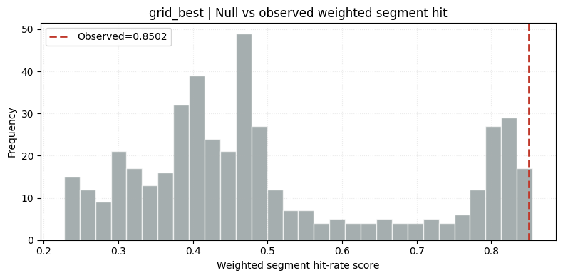

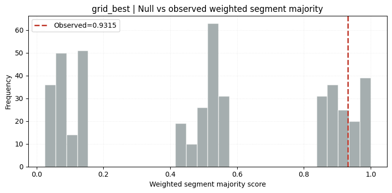

```
================================================================================
[honest] segment-level evidence
```

|  | segment_id | start_date | end_date | n_days | true_regime | signed_log_return | amplitude | hit_rate | pred_majority | majority_hit | is_open_tail |
| --- | --- | --- | --- | --- | --- | --- | --- | --- | --- | --- | --- |
| 0 | 0 | 2024-12-17 | 2025-01-08 | 23 | 0 | -0.110117 | 0.110117 | 0.739130 | 0 | 1.0 | True |
| 1 | 1 | 2025-01-09 | 2025-03-01 | 52 | 1 | -0.072836 | 0.072836 | 0.519231 | 1 | 1.0 | True |
| 2 | 2 | 2025-03-02 | 2025-04-07 | 37 | 0 | -0.174444 | 0.174444 | 0.783784 | 0 | 1.0 | True |
| 3 | 3 | 2025-04-08 | 2025-10-07 | 183 | 1 | 0.463510 | 0.463510 | 0.655738 | 1 | 1.0 | True |
| 4 | 4 | 2025-10-08 | 2026-02-05 | 121 | 0 | -0.521297 | 0.521297 | 0.347107 | 1 | 0.0 | True |

```
weighted_hit_obs=0.5261 null_mean=0.4849 z=0.294 p=0.466814
weighted_majority_obs=0.5416 null_mean=0.5231 z=0.060 p=0.35177
```

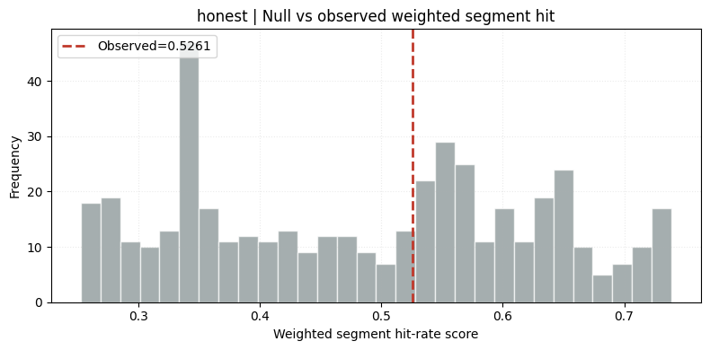

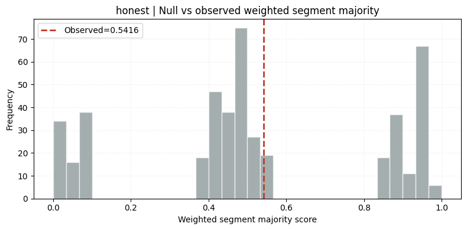

```python
for tag in sorted(segment_artifacts.keys()):
    art = segment_artifacts[tag]
    seg = art["perm"]["obs_details"].copy()

    print("\n" + "=" * 80)
    print(f"[{tag}] segment-level evidence")

    if seg.empty:
        print("No TP segments available for this candidate/test window.")
        continue

    # Segment table is the most interpretable audit artifact for publication.
    show_cols = [
        "segment_id", "start_date", "end_date", "n_days", "true_regime",
        "signed_log_return", "amplitude", "hit_rate", "pred_majority", "majority_hit", "is_open_tail",
    ]
    display(seg[show_cols])

    row = df_segment_stats[df_segment_stats["candidate"] == tag].iloc[0]
    print(
        f"weighted_hit_obs={float(row['weighted_hit_rate_obs']):.4f} "
        f"null_mean={float(row['weighted_hit_rate_null_mean']):.4f} "
        f"z={float(row['z_weighted_hit']):.3f} "
        f"p={float(row['p_shift_weighted_hit']):.6g}"
    )
    print(
        f"weighted_majority_obs={float(row['weighted_majority_obs']):.4f} "
        f"null_mean={float(row['weighted_majority_null_mean']):.4f} "
        f"z={float(row['z_weighted_majority']):.3f} "
        f"p={float(row['p_shift_weighted_majority']):.6g}"
    )

    if SEGMENT_SHOW_NULL_PLOTS:
        plot_segment_null_distribution(
            null_values=art["perm"]["null_weighted_hit"],
            observed_value=float(row["weighted_hit_rate_obs"]),
            title=f"{tag} | Null vs observed weighted segment hit",
            x_label="Weighted segment hit-rate score",
        )
        plot_segment_null_distribution(
            null_values=art["perm"]["null_weighted_majority"],
            observed_value=float(row["weighted_majority_obs"]),
            title=f"{tag} | Null vs observed weighted segment majority",
            x_label="Weighted segment majority score",
        )
```

```python
event_rows = []

for tag, res in eval_results.items():
    frame = res["test_frame"].copy().reset_index(drop=True)
    frame["date"] = pd.to_datetime(frame["date"])
    true_events = build_true_turn_events(
        eval_result=res,
        mode=TRUE_EVENT_MODE,
        min_move_pct=TRUE_EVENT_MIN_MOVE_PCT,
        min_segment_days=TRUE_EVENT_MIN_SEGMENT_DAYS,
        smooth_span_days=TRUE_EVENT_SMOOTH_SPAN_DAYS,
        enter_up=TRUE_EVENT_ENTER_UP,
        enter_down=TRUE_EVENT_ENTER_DOWN,
        df_market_ref=df_market,
        tp_horizon_days=TRUE_TP_HORIZON_DAYS,
        tp_up_move_pct=TRUE_TP_UP_MOVE_PCT,
        tp_down_move_pct=TRUE_TP_DOWN_MOVE_PCT,
        tp_cluster_gap_days=TRUE_TP_CLUSTER_GAP_DAYS,
        tp_min_turn_gap_days=TRUE_TP_MIN_TURN_GAP_DAYS,
        tp_past_horizon_days=TRUE_TP_PAST_HORIZON_DAYS,
        tp_past_up_move_pct=TRUE_TP_PAST_UP_MOVE_PCT,
        tp_past_down_move_pct=TRUE_TP_PAST_DOWN_MOVE_PCT,
        tp_tail_direction_mode=TRUE_TP_TAIL_DIRECTION_MODE,
        tp_tail_min_move_pct=TRUE_TP_TAIL_MIN_MOVE_PCT,
    )
    pred_labels = build_pred_regime_labels_from_frame(
        test_frame=frame,
        mode=PRED_EVENT_MODE,
        smooth_span_days=PRED_EVENT_SMOOTH_SPAN_DAYS,
        enter_up=PRED_EVENT_ENTER_UP,
        enter_down=PRED_EVENT_ENTER_DOWN,
        min_segment_days=PRED_EVENT_MIN_SEGMENT_DAYS,
    )

    for w in EVENT_WINDOWS:
        perm = circular_shift_permutation_test(
            dates=frame["date"],
            pred_labels=pred_labels,
            true_events=true_events,
            window_days=int(w),
        )

        obs = perm["obs"]
        fam = int(candidate_family_size.get(tag, len(df_results)))

        event_rows.append(
            {
                "candidate": tag,
                "window_days": int(w),
                "n_true_events": int(obs["n_true_events"]),
                "n_pred_events": int(obs["n_pred_events"]),
                "n_matched": int(obs["n_matched"]),
                "recall_true": obs["recall_true"],
                "precision_pred": obs["precision_pred"],
                "f1_event": obs["f1_event"],
                "mean_abs_lag_days": obs["mean_abs_lag_days"],
                "median_lag_days": obs["median_lag_days"],
                "lead_share": obs["lead_share"],
                "p_shift_recall": perm["p_recall"],
                "p_shift_recall_bonf": bonferroni_correction(perm["p_recall"], fam),
                "p_shift_abs_lag": perm["p_abs_lag"],
                "p_shift_abs_lag_bonf": bonferroni_correction(perm["p_abs_lag"], fam),
                "null_recall_mean": perm["null_recall_mean"],
                "null_recall_std": perm["null_recall_std"],
                "null_abs_lag_mean": perm["null_abs_lag_mean"],
                "n_permutations": perm["n_permutations"],
                "family_size_correction": fam,
            }
        )

df_event_stats = pd.DataFrame(event_rows).sort_values(["candidate", "window_days"]).reset_index(drop=True)
print("Event-level alignment statistics (real turns vs predicted switches):")
display(df_event_stats)

# Focus view: strongest temporal evidence per candidate (smallest corrected p for recall).
focus = df_event_stats.sort_values(["candidate", "p_shift_recall_bonf", "window_days"]).groupby("candidate", as_index=False).head(1)
print("Best event-window per candidate (by corrected recall p-value):")
display(focus)
```

```
Event-level alignment statistics (real turns vs predicted switches):
```

|  | candidate | window_days | n_true_events | n_pred_events | n_matched | recall_true | precision_pred | f1_event | mean_abs_lag_days | median_lag_days | lead_share | p_shift_recall | p_shift_recall_bonf | p_shift_abs_lag | p_shift_abs_lag_bonf | null_recall_mean | null_recall_std | null_abs_lag_mean | n_permutations | family_size_correction |
| --- | --- | --- | --- | --- | --- | --- | --- | --- | --- | --- | --- | --- | --- | --- | --- | --- | --- | --- | --- | --- |
| 0 | grid_best | 1 | 5 | 5 | 0 | 0.0 | 0.000000 | NaN | NaN | NaN | NaN | 1.000000 | 1.0 | NaN | NaN | 0.019956 | 0.065593 | 0.658537 | 451 | 1200 |
| 1 | grid_best | 2 | 5 | 5 | 1 | 0.2 | 0.200000 | 0.200000 | 2.000000 | -2.0 | 1.000000 | 0.143805 | 1.0 | 1.000000 | 1.0 | 0.032816 | 0.085206 | 1.218750 | 451 | 1200 |
| 2 | grid_best | 3 | 5 | 5 | 1 | 0.2 | 0.200000 | 0.200000 | 2.000000 | -2.0 | 1.000000 | 0.196903 | 1.0 | 0.707865 | 1.0 | 0.046120 | 0.099675 | 1.761364 | 451 | 1200 |
| 3 | grid_best | 5 | 5 | 5 | 1 | 0.2 | 0.200000 | 0.200000 | 2.000000 | -2.0 | 1.000000 | 0.296460 | 1.0 | 0.440299 | 1.0 | 0.072727 | 0.121471 | 2.759398 | 451 | 1200 |
| 4 | grid_best | 7 | 5 | 5 | 1 | 0.2 | 0.200000 | 0.200000 | 2.000000 | -2.0 | 1.000000 | 0.378319 | 1.0 | 0.339181 | 1.0 | 0.099335 | 0.143057 | 3.703922 | 451 | 1200 |
| 5 | grid_best | 10 | 5 | 5 | 1 | 0.2 | 0.200000 | 0.200000 | 2.000000 | -2.0 | 1.000000 | 0.486726 | 1.0 | 0.204545 | 1.0 | 0.139246 | 0.169879 | 5.243531 | 451 | 1200 |
| 6 | grid_best | 14 | 5 | 5 | 3 | 0.6 | 0.600000 | 0.600000 | 9.333333 | -2.0 | 0.666667 | 0.088496 | 1.0 | 0.712727 | 1.0 | 0.191574 | 0.197591 | 7.225669 | 451 | 1200 |
| 7 | honest | 1 | 5 | 6 | 0 | 0.0 | 0.000000 | NaN | NaN | NaN | NaN | 1.000000 | 1.0 | NaN | NaN | 0.019956 | 0.061403 | 0.659091 | 451 | 24 |
| 8 | honest | 2 | 5 | 6 | 0 | 0.0 | 0.000000 | NaN | NaN | NaN | NaN | 1.000000 | 1.0 | NaN | NaN | 0.033259 | 0.077961 | 1.208333 | 451 | 24 |
| 9 | honest | 3 | 5 | 6 | 0 | 0.0 | 0.000000 | NaN | NaN | NaN | NaN | 1.000000 | 1.0 | NaN | NaN | 0.046563 | 0.091576 | 1.714286 | 451 | 24 |
| 10 | honest | 5 | 5 | 6 | 0 | 0.0 | 0.000000 | NaN | NaN | NaN | NaN | 1.000000 | 1.0 | NaN | NaN | 0.073171 | 0.118615 | 2.699531 | 451 | 24 |
| 11 | honest | 7 | 5 | 6 | 1 | 0.2 | 0.166667 | 0.181818 | 6.000000 | -6.0 | 1.000000 | 0.400442 | 1.0 | 0.889503 | 1.0 | 0.099335 | 0.138649 | 3.720370 | 451 | 24 |
| 12 | honest | 10 | 5 | 6 | 2 | 0.4 | 0.333333 | 0.363636 | 7.000000 | -7.0 | 1.000000 | 0.143805 | 1.0 | 0.767241 | 1.0 | 0.138803 | 0.163057 | 5.261905 | 451 | 24 |
| 13 | honest | 14 | 5 | 6 | 3 | 0.6 | 0.500000 | 0.545455 | 9.000000 | -8.0 | 1.000000 | 0.061947 | 1.0 | 0.695205 | 1.0 | 0.191574 | 0.186982 | 7.358534 | 451 | 24 |

```
Best event-window per candidate (by corrected recall p-value):
```

|  | candidate | window_days | n_true_events | n_pred_events | n_matched | recall_true | precision_pred | f1_event | mean_abs_lag_days | median_lag_days | lead_share | p_shift_recall | p_shift_recall_bonf | p_shift_abs_lag | p_shift_abs_lag_bonf | null_recall_mean | null_recall_std | null_abs_lag_mean | n_permutations | family_size_correction |
| --- | --- | --- | --- | --- | --- | --- | --- | --- | --- | --- | --- | --- | --- | --- | --- | --- | --- | --- | --- | --- |
| 0 | grid_best | 1 | 5 | 5 | 0 | 0.0 | 0.0 | NaN | NaN | NaN | NaN | 1.0 | 1.0 | NaN | NaN | 0.019956 | 0.065593 | 0.658537 | 451 | 1200 |
| 7 | honest | 1 | 5 | 6 | 0 | 0.0 | 0.0 | NaN | NaN | NaN | NaN | 1.0 | 1.0 | NaN | NaN | 0.019956 | 0.061403 | 0.659091 | 451 | 24 |

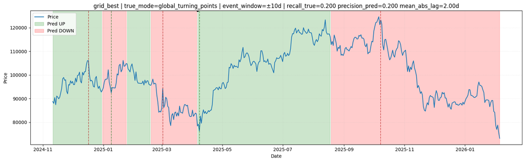

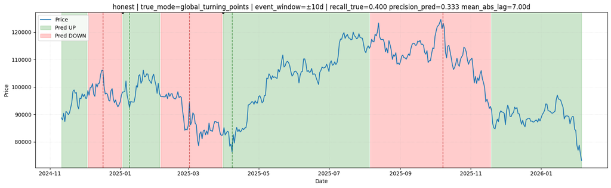

```python
PLOT_WINDOW = 10
for tag, res in eval_results.items():
    plot_event_alignment(
        eval_result=res,
        window_days=PLOT_WINDOW,
        title_prefix=f"{tag}",
        price_color="#1f77b4",
        up_color="green",
        down_color="red",
        shade_alpha=0.20,
        show_block=PLOT_BLOCKING,
    )
```

```python
print("Statistical conclusion summary:")

for tag in sorted(eval_results.keys()):
    cls = df_candidate_summary[df_candidate_summary["candidate"] == tag].iloc[0]
    evt = df_event_stats[df_event_stats["candidate"] == tag].sort_values(["p_shift_recall_bonf", "window_days"]).iloc[0]

    print("\n" + "=" * 90)
    print(f"Candidate: {tag}")
    print("Classification significance:")
    print(
        f"  accuracy p-value vs random = {float(cls['acc_p_value_vs_random']):.6g}, "
        f"95% CI = [{float(cls['acc_ci95_low']):.3f}, {float(cls['acc_ci95_high']):.3f}]"
    )
    print(
        f"  test_recall_min = {float(cls['test_recall_min']):.3f}, "
        f"test_recall_gap = {float(cls['test_recall_gap']):.3f}, "
        f"test_profit_y_obj = {float(cls['test_profit_y_obj']):+.6f}"
    )

    print("Event-time alignment significance (best window by corrected p):")
    print(
        f"  window = ±{int(evt['window_days'])}d, recall_true = {float(evt['recall_true']):.3f}, "
        f"precision_pred = {float(evt['precision_pred']):.3f}, mean_abs_lag = {float(evt['mean_abs_lag_days']):.2f}d"
    )
    print(
        f"  circular-shift p(recall) = {float(evt['p_shift_recall']):.6g}, "
        f"Bonferroni corrected = {float(evt['p_shift_recall_bonf']):.6g} "
        f"(family={int(evt['family_size_correction'])})"
    )

    if np.isfinite(evt["p_shift_recall_bonf"]) and float(evt["p_shift_recall_bonf"]) < 0.05:
        print("  Verdict: temporal alignment is statistically significant even after conservative correction.")
    elif np.isfinite(evt["p_shift_recall"]) and float(evt["p_shift_recall"]) < 0.05:
        print("  Verdict: raw significance exists, but conservative correction removes formal significance.")
    else:
        print("  Verdict: no strong event-time significance under current conservative test.")
```

```
Statistical conclusion summary:

==========================================================================================
Candidate: grid_best
Classification significance:
  accuracy p-value vs random = 0.0268377, 95% CI = [0.500, 0.592]
  test_recall_min = 0.536, test_recall_gap = 0.464, test_profit_y_obj = +0.012272
Event-time alignment significance (best window by corrected p):
  window = ±1d, recall_true = 0.000, precision_pred = 0.000, mean_abs_lag = nand
  circular-shift p(recall) = 1, Bonferroni corrected = 1 (family=1200)
  Verdict: no strong event-time significance under current conservative test.

==========================================================================================
Candidate: honest
Classification significance:
  accuracy p-value vs random = 1.26138e-18, 95% CI = [0.660, 0.744]
  test_recall_min = 0.702, test_recall_gap = 0.002, test_profit_y_obj = +0.008167
Event-time alignment significance (best window by corrected p):
  window = ±1d, recall_true = 0.000, precision_pred = 0.000, mean_abs_lag = nand
  circular-shift p(recall) = 1, Bonferroni corrected = 1 (family=24)
  Verdict: no strong event-time significance under current conservative test.
```

## What Dashed Vertical Lines Mean (TP-Only)

- Dashed lines are exactly the configured **turning-point dates** used as truth events.
- Green dashed line: turning point into UP regime.
- Red dashed line: turning point into DOWN regime.
- No additional smoothed/derived truth events are used in this notebook.

```python
# Sweep broader radii for already evaluated candidates (grid_best/honest).
RADIUS_SWEEP_DAYS = [1, 2, 3, 4, 5, 6, 7, 10, 14, 21, 28]

wide_rows = []
for tag, res in eval_results.items():
    frame = res["test_frame"].copy().reset_index(drop=True)
    frame["date"] = pd.to_datetime(frame["date"])

    true_events = build_true_turn_events(
        eval_result=res,
        mode=TRUE_EVENT_MODE,
        min_move_pct=TRUE_EVENT_MIN_MOVE_PCT,
        min_segment_days=TRUE_EVENT_MIN_SEGMENT_DAYS,
        smooth_span_days=TRUE_EVENT_SMOOTH_SPAN_DAYS,
        enter_up=TRUE_EVENT_ENTER_UP,
        enter_down=TRUE_EVENT_ENTER_DOWN,
        df_market_ref=df_market,
        tp_horizon_days=TRUE_TP_HORIZON_DAYS,
        tp_up_move_pct=TRUE_TP_UP_MOVE_PCT,
        tp_down_move_pct=TRUE_TP_DOWN_MOVE_PCT,
        tp_cluster_gap_days=TRUE_TP_CLUSTER_GAP_DAYS,
        tp_min_turn_gap_days=TRUE_TP_MIN_TURN_GAP_DAYS,
        tp_past_horizon_days=TRUE_TP_PAST_HORIZON_DAYS,
        tp_past_up_move_pct=TRUE_TP_PAST_UP_MOVE_PCT,
        tp_past_down_move_pct=TRUE_TP_PAST_DOWN_MOVE_PCT,
        tp_tail_direction_mode=TRUE_TP_TAIL_DIRECTION_MODE,
        tp_tail_min_move_pct=TRUE_TP_TAIL_MIN_MOVE_PCT,
    )
    pred_labels = build_pred_regime_labels_from_frame(
        test_frame=frame,
        mode=PRED_EVENT_MODE,
        smooth_span_days=PRED_EVENT_SMOOTH_SPAN_DAYS,
        enter_up=PRED_EVENT_ENTER_UP,
        enter_down=PRED_EVENT_ENTER_DOWN,
        min_segment_days=PRED_EVENT_MIN_SEGMENT_DAYS,
    )

    for w in RADIUS_SWEEP_DAYS:
        perm = circular_shift_permutation_test(
            dates=frame["date"],
            pred_labels=pred_labels,
            true_events=true_events,
            window_days=int(w),
        )
        obs = perm["obs"]
        fam = int(candidate_family_size.get(tag, len(df_results)))
        wide_rows.append({
            "candidate": tag,
            "window_days": int(w),
            "n_true_events": int(obs["n_true_events"]),
            "n_pred_events": int(obs["n_pred_events"]),
            "n_matched": int(obs["n_matched"]),
            "recall_true": obs["recall_true"],
            "precision_pred": obs["precision_pred"],
            "f1_event": obs["f1_event"],
            "mean_abs_lag_days": obs["mean_abs_lag_days"],
            "p_shift_recall": perm["p_recall"],
            "p_shift_recall_bonf": bonferroni_correction(perm["p_recall"], fam),
            "null_recall_mean": perm["null_recall_mean"],
            "delta_recall_vs_null": (obs["recall_true"] - perm["null_recall_mean"]) if (np.isfinite(obs["recall_true"]) and np.isfinite(perm["null_recall_mean"])) else np.nan,
        })

df_radius_sweep_two = pd.DataFrame(wide_rows).sort_values(["candidate", "window_days"]).reset_index(drop=True)
print("Broader radius sweep for grid_best/honest:")
display(df_radius_sweep_two)

for tag in sorted(df_radius_sweep_two["candidate"].unique()):
    sub = df_radius_sweep_two[df_radius_sweep_two["candidate"] == tag].copy()
    best = sub.sort_values(["p_shift_recall_bonf", "window_days"]).iloc[0]
    print(f"[{tag}] best radius by corrected p: ±{int(best['window_days'])}d | recall={float(best['recall_true']):.3f} | p_bonf={float(best['p_shift_recall_bonf']):.6g}")
```

```
Broader radius sweep for grid_best/honest:
```

|  | candidate | window_days | n_true_events | n_pred_events | n_matched | recall_true | precision_pred | f1_event | mean_abs_lag_days | p_shift_recall | p_shift_recall_bonf | null_recall_mean | delta_recall_vs_null |
| --- | --- | --- | --- | --- | --- | --- | --- | --- | --- | --- | --- | --- | --- |
| 0 | grid_best | 1 | 5 | 5 | 0 | 0.0 | 0.000000 | NaN | NaN | 1.000000 | 1.0 | 0.019956 | -0.019956 |
| 1 | grid_best | 2 | 5 | 5 | 1 | 0.2 | 0.200000 | 0.200000 | 2.000000 | 0.143805 | 1.0 | 0.032816 | 0.167184 |
| 2 | grid_best | 3 | 5 | 5 | 1 | 0.2 | 0.200000 | 0.200000 | 2.000000 | 0.196903 | 1.0 | 0.046120 | 0.153880 |
| 3 | grid_best | 4 | 5 | 5 | 1 | 0.2 | 0.200000 | 0.200000 | 2.000000 | 0.250000 | 1.0 | 0.059424 | 0.140576 |
| 4 | grid_best | 5 | 5 | 5 | 1 | 0.2 | 0.200000 | 0.200000 | 2.000000 | 0.296460 | 1.0 | 0.072727 | 0.127273 |
| 5 | grid_best | 6 | 5 | 5 | 1 | 0.2 | 0.200000 | 0.200000 | 2.000000 | 0.338496 | 1.0 | 0.086031 | 0.113969 |
| 6 | grid_best | 7 | 5 | 5 | 1 | 0.2 | 0.200000 | 0.200000 | 2.000000 | 0.378319 | 1.0 | 0.099335 | 0.100665 |
| 7 | grid_best | 10 | 5 | 5 | 1 | 0.2 | 0.200000 | 0.200000 | 2.000000 | 0.486726 | 1.0 | 0.139246 | 0.060754 |
| 8 | grid_best | 14 | 5 | 5 | 3 | 0.6 | 0.600000 | 0.600000 | 9.333333 | 0.088496 | 1.0 | 0.191574 | 0.408426 |
| 9 | grid_best | 21 | 5 | 5 | 4 | 0.8 | 0.800000 | 0.800000 | 11.000000 | 0.077434 | 1.0 | 0.284257 | 0.515743 |
| 10 | grid_best | 28 | 5 | 5 | 4 | 0.8 | 0.800000 | 0.800000 | 11.000000 | 0.139381 | 1.0 | 0.366741 | 0.433259 |
| 11 | honest | 1 | 5 | 6 | 0 | 0.0 | 0.000000 | NaN | NaN | 1.000000 | 1.0 | 0.019956 | -0.019956 |
| 12 | honest | 2 | 5 | 6 | 0 | 0.0 | 0.000000 | NaN | NaN | 1.000000 | 1.0 | 0.033259 | -0.033259 |
| 13 | honest | 3 | 5 | 6 | 0 | 0.0 | 0.000000 | NaN | NaN | 1.000000 | 1.0 | 0.046563 | -0.046563 |
| 14 | honest | 4 | 5 | 6 | 0 | 0.0 | 0.000000 | NaN | NaN | 1.000000 | 1.0 | 0.059867 | -0.059867 |
| 15 | honest | 5 | 5 | 6 | 0 | 0.0 | 0.000000 | NaN | NaN | 1.000000 | 1.0 | 0.073171 | -0.073171 |
| 16 | honest | 6 | 5 | 6 | 1 | 0.2 | 0.166667 | 0.181818 | 6.000000 | 0.360619 | 1.0 | 0.086031 | 0.113969 |
| 17 | honest | 7 | 5 | 6 | 1 | 0.2 | 0.166667 | 0.181818 | 6.000000 | 0.400442 | 1.0 | 0.099335 | 0.100665 |
| 18 | honest | 10 | 5 | 6 | 2 | 0.4 | 0.333333 | 0.363636 | 7.000000 | 0.143805 | 1.0 | 0.138803 | 0.261197 |
| 19 | honest | 14 | 5 | 6 | 3 | 0.6 | 0.500000 | 0.545455 | 9.000000 | 0.061947 | 1.0 | 0.191574 | 0.408426 |
| 20 | honest | 21 | 5 | 6 | 3 | 0.6 | 0.500000 | 0.545455 | 9.000000 | 0.148230 | 1.0 | 0.284701 | 0.315299 |
| 21 | honest | 28 | 5 | 6 | 4 | 0.8 | 0.666667 | 0.727273 | 13.000000 | 0.088496 | 1.0 | 0.377384 | 0.422616 |

```
[grid_best] best radius by corrected p: ±1d | recall=0.000 | p_bonf=1
[honest] best radius by corrected p: ±1d | recall=0.000 | p_bonf=1
```

```python
import time
from datetime import timedelta

TOP_N = 100
TOP_POOL = "feasible"  # "feasible" or "all"
TOP_WINDOW_SWEEP = [1, 2, 3, 5, 7, 10, 14]
RUN_TOP100_NOW = True

EVENT_STATS_TAG = (
    f"true-{TRUE_EVENT_MODE}_pred-{PRED_EVENT_MODE}"
    f"_tp{int(round(TRUE_TP_UP_MOVE_PCT * 100.0))}"
    f"_gap{int(TRUE_TP_MIN_TURN_GAP_DAYS)}"
    f"_seg{int(PRED_EVENT_MIN_SEGMENT_DAYS)}"
).replace(".", "p")
TOP_STATS_PATH = Path(REPORTS_DIR) / f"{RUN_TAG}_top{TOP_N}_event_stats_{EVENT_STATS_TAG}.csv"


def _select_top_candidates(df_sorted: pd.DataFrame, top_n: int, pool: str = "feasible") -> pd.DataFrame:
    if str(pool).lower() == "feasible":
        d = df_sorted[df_sorted.get("is_feasible", 0) == 1].copy()
        if d.empty:
            d = df_sorted.copy()
    else:
        d = df_sorted.copy()
    d = d.head(int(top_n)).copy().reset_index(drop=True)
    d["candidate_rank"] = np.arange(1, len(d) + 1, dtype=int)
    return d


def _candidate_key(row: pd.Series) -> str:
    rank = int(row.get("candidate_rank", -1))
    eval_id = int(row.get("eval_id", -1)) if np.isfinite(pd.to_numeric(row.get("eval_id", np.nan), errors="coerce")) else -1
    return f"rank{rank:03d}_eval{eval_id}"


def _eta_str(elapsed_sec: float, done: int, total: int) -> str:
    if done <= 0:
        return "?"
    left = max(0, int(total - done))
    per = elapsed_sec / max(1, done)
    eta = timedelta(seconds=int(per * left))
    return str(eta)


def evaluate_candidate_fast_topn(
    row: pd.Series,
    tag: str,
    df_market_local: pd.DataFrame,
    close_map_local: pd.DataFrame,
    feature_cache_local: dict[tuple[str, str, float], pd.DataFrame],
    seed: int = 42,
) -> Dict[str, Any]:
    """Fast path for top-N event sweep (skips bootstrap/significance extras)."""
    df_features = get_or_build_features_for_row(row=row, df_market=df_market_local, feature_cache=feature_cache_local)

    label_cfg = _extract_label_cfg(row)
    target_cfg = _extract_target_cfg(row)
    model_cfg = _extract_model_cfg(row)

    turn_cfg = TurningPointLabelConfig(
        horizon_days=int(row.get("horizon_days_fixed", 10)),
        up_move_pct=float(label_cfg["up_move_pct"]),
        down_move_pct=float(label_cfg["down_move_pct"]),
        cluster_gap_days=int(label_cfg["cluster_gap_days"]),
        min_turn_gap_days=int(label_cfg["min_turn_gap_days"]),
        past_horizon_days=int(label_cfg["past_horizon_days"]),
        past_up_move_pct=float(label_cfg["past_up_move_pct"]),
        past_down_move_pct=float(label_cfg["past_down_move_pct"]),
        tail_direction_mode=str(row.get("tail_direction_mode_fixed", "endpoint_sign")),
        tail_min_move_pct=float(row.get("tail_min_move_pct_fixed", 0.0)),
    )

    _, df_turns, _ = label_turning_points(df_market=df_market_local, cfg=turn_cfg)

    if target_cfg["mode"] == "window_kernel":
        df_target = build_turning_target_frame(
            df_market=df_market_local,
            df_turning_points=df_turns,
            mode="window_kernel",
            window_radius_days=int(target_cfg["window_radius_days"]),
            window_distance_power=float(target_cfg["window_distance_power"]),
            min_weight=float(target_cfg["min_weight"]),
            use_amplitude_weight=bool(target_cfg["use_amplitude_weight"]),
            use_numba=True,
        )
    else:
        df_target = build_turning_target_frame(
            df_market=df_market_local,
            df_turning_points=df_turns,
            mode="segment_midpoint",
            segment_center_power=float(target_cfg["segment_center_power"]),
            segment_direction_anchor=str(target_cfg["segment_direction_anchor"]),
            include_last_open_segment=bool(target_cfg["include_last_open_segment"]),
            segment_open_tail_direction_mode=str(target_cfg["segment_open_tail_direction_mode"]),
            segment_open_tail_min_move_pct=float(target_cfg["segment_open_tail_min_move_pct"]),
            min_weight=float(target_cfg["min_weight"]),
            use_amplitude_weight=bool(target_cfg["use_amplitude_weight"]),
            use_numba=True,
        )

    df_dataset = merge_features_with_turning_target(
        df_features=df_features,
        df_target=df_target,
        df_market_close=df_market_local[["date", "close"]],
    )
    df_dataset = pd.merge(df_dataset, close_map_local[["date", "next_ret"]], on="date", how="left")
    df_dataset = (
        df_dataset
        .dropna(subset=["next_ret", "target", "sample_weight", "close"])
        .sort_values("date")
        .reset_index(drop=True)
    )

    split = make_classic_split(df_dataset, train_ratio=TRAIN_RATIO, val_ratio=VAL_RATIO)
    train_df = df_dataset.iloc[split.train_idx].copy().reset_index(drop=True)
    val_df = df_dataset.iloc[split.val_idx].copy().reset_index(drop=True)
    test_df = df_dataset.iloc[split.test_idx].copy().reset_index(drop=True)

    feature_cols = [
        c for c in df_dataset.columns
        if c not in {
            "date", "target", "close", "next_ret",
            "turning_direction", "sample_weight", "target_mode",
            "event_index", "segment_index",
        }
    ]

    X_train = train_df[feature_cols].to_numpy(dtype=np.float32)
    y_train = train_df["target"].to_numpy(dtype=np.int32)
    X_val = val_df[feature_cols].to_numpy(dtype=np.float32)
    y_val = val_df["target"].to_numpy(dtype=np.int32)
    X_test = test_df[feature_cols].to_numpy(dtype=np.float32)
    y_test = test_df["target"].to_numpy(dtype=np.int32)

    sw_train_base = pd.to_numeric(train_df["sample_weight"], errors="coerce").fillna(1.0).to_numpy(dtype=np.float32)
    sw_val_base = pd.to_numeric(val_df["sample_weight"], errors="coerce").fillna(1.0).to_numpy(dtype=np.float32)
    sw_test_base = pd.to_numeric(test_df["sample_weight"], errors="coerce").fillna(1.0).to_numpy(dtype=np.float32)

    sw_train = sw_train_base * compute_sample_weight(class_weight="balanced", y=y_train).astype(np.float32)
    sw_val = sw_val_base * compute_sample_weight(class_weight="balanced", y=y_val).astype(np.float32)
    sw_test = sw_test_base * compute_sample_weight(class_weight="balanced", y=y_test).astype(np.float32)
```

```python
    _, device = check_cuda_available()

    def _make_model(device_name: str) -> XGBBaseline:
        return XGBBaseline(
            n_classes=2,
            device=device_name,
            random_state=seed,
            early_stopping_rounds=int(model_cfg["early_stopping_rounds"]),
            n_estimators=int(model_cfg["n_estimators"]),
            max_depth=int(model_cfg["max_depth"]),
            learning_rate=float(model_cfg["learning_rate"]),
            subsample=float(model_cfg["subsample"]),
            colsample_bytree=float(model_cfg["colsample_bytree"]),
            tree_method="hist",
            eval_metric="logloss",
        )

    used_device = str(device)
    model = _make_model(used_device)
    try:
        model.fit(
            X_train=X_train,
            y_train=y_train,
            X_val=X_val,
            y_val=y_val,
            feature_names=feature_cols,
            sample_weight=sw_train,
            sample_weight_val=sw_val,
        )
    except Exception:
        used_device = "cpu"
        model = _make_model(used_device)
        model.fit(
            X_train=X_train,
            y_train=y_train,
            X_val=X_val,
            y_val=y_val,
            feature_names=feature_cols,
            sample_weight=sw_train,
            sample_weight_val=sw_val,
        )

    threshold = float(row.get("threshold", 0.5))
    p_test = _safe_predict_proba_up(model, X_test)
    pred_test = (p_test >= threshold).astype(np.int32)
    test_metrics = compute_binary_metrics(y_test, pred_test)

    ret_test = pd.to_numeric(test_df["next_ret"], errors="coerce").fillna(0.0).to_numpy(dtype=np.float32)

    test_start = pd.to_datetime(test_df["date"].min())
    test_end = pd.to_datetime(test_df["date"].max())
    turns_test = df_turns[(pd.to_datetime(df_turns["date"]) >= test_start) & (pd.to_datetime(df_turns["date"]) <= test_end)].copy()

    out = {
        "tag": tag,
        "used_device": used_device,
        "threshold": threshold,
        "test_metrics": test_metrics,
        "test_profit_y": _profit_y(pred_test, ret_test),
        "test_profit_y_obj": _profit_y_obj(pred_test, ret_test, sw_test),
        "turns_test": turns_test[["date", "turning_direction"]].copy(),
        "test_frame": test_df[["date", "close", "next_ret", "target"]].assign(
            pred=pred_test,
            proba_up=p_test,
            match=(pred_test == y_test).astype(np.int32),
        ),
    }
    return out


def run_topn_event_sweep(
    df_sorted: pd.DataFrame,
    df_market_local: pd.DataFrame,
    close_map_local: pd.DataFrame,
    feature_cache_local: dict[tuple[str, str, float], pd.DataFrame],
    top_n: int = 100,
    pool: str = "feasible",
    windows: list[int] | None = None,
    out_path: Path | None = None,
) -> pd.DataFrame:
    ws = windows or [1, 2, 3, 5, 7]
    out_path = out_path or TOP_STATS_PATH
    selected = _select_top_candidates(df_sorted, top_n=top_n, pool=pool)

    if out_path.exists():
        df_existing = pd.read_csv(out_path)
    else:
        df_existing = pd.DataFrame()

    done_keys = set(df_existing["candidate_key"].astype(str).tolist()) if not df_existing.empty and "candidate_key" in df_existing.columns else set()
    rows_acc = []

    t0 = time.time()
    total = len(selected)
    done = 0

    print(f"[TOP-N] selected={total} pool={pool} windows={ws}")
    if len(done_keys) > 0:
        print(f"[TOP-N] resume from checkpoint: {len(done_keys)} candidate(s) already done")

    for _, row in selected.iterrows():
        key = _candidate_key(row)
        if key in done_keys:
            done += 1
            continue

        tag = f"top{int(row['candidate_rank']):03d}"
        print(f"[TOP-N EVAL] {tag} key={key} ({done+1}/{total})")

        ev = evaluate_candidate_fast_topn(
            row=row,
            tag=tag,
            df_market_local=df_market_local,
            close_map_local=close_map_local,
            feature_cache_local=feature_cache_local,
            seed=SEED,
        )

        frame = ev["test_frame"].copy().reset_index(drop=True)
        frame["date"] = pd.to_datetime(frame["date"])
        true_events = build_true_turn_events(
            eval_result=ev,
            mode=TRUE_EVENT_MODE,
            min_move_pct=TRUE_EVENT_MIN_MOVE_PCT,
            min_segment_days=TRUE_EVENT_MIN_SEGMENT_DAYS,
            smooth_span_days=TRUE_EVENT_SMOOTH_SPAN_DAYS,
            enter_up=TRUE_EVENT_ENTER_UP,
            enter_down=TRUE_EVENT_ENTER_DOWN,
            df_market_ref=df_market_local,
            tp_horizon_days=TRUE_TP_HORIZON_DAYS,
            tp_up_move_pct=TRUE_TP_UP_MOVE_PCT,
            tp_down_move_pct=TRUE_TP_DOWN_MOVE_PCT,
            tp_cluster_gap_days=TRUE_TP_CLUSTER_GAP_DAYS,
            tp_min_turn_gap_days=TRUE_TP_MIN_TURN_GAP_DAYS,
            tp_past_horizon_days=TRUE_TP_PAST_HORIZON_DAYS,
            tp_past_up_move_pct=TRUE_TP_PAST_UP_MOVE_PCT,
            tp_past_down_move_pct=TRUE_TP_PAST_DOWN_MOVE_PCT,
            tp_tail_direction_mode=TRUE_TP_TAIL_DIRECTION_MODE,
            tp_tail_min_move_pct=TRUE_TP_TAIL_MIN_MOVE_PCT,
        )
        pred_labels = build_pred_regime_labels_from_frame(
            test_frame=frame,
            mode=PRED_EVENT_MODE,
            smooth_span_days=PRED_EVENT_SMOOTH_SPAN_DAYS,
            enter_up=PRED_EVENT_ENTER_UP,
            enter_down=PRED_EVENT_ENTER_DOWN,
            min_segment_days=PRED_EVENT_MIN_SEGMENT_DAYS,
        )
        family_within = len(ws)

        for w in ws:
            perm = circular_shift_permutation_test(
                dates=frame["date"],
                pred_labels=pred_labels,
                true_events=true_events,
                window_days=int(w),
            )
            obs = perm["obs"]
            p_raw = perm["p_recall"]

            rows_acc.append({
                "candidate_key": key,
                "candidate_rank": int(row["candidate_rank"]),
                "eval_id": int(row.get("eval_id", -1)) if np.isfinite(pd.to_numeric(row.get("eval_id", np.nan), errors="coerce")) else -1,
                "window_days": int(w),
                "test_profit_y_obj": float(ev["test_profit_y_obj"]),
                "test_profit_y": float(ev["test_profit_y"]),
                "test_recall_min": float(ev["test_metrics"]["recall_min"]),
                "test_recall_gap": float(ev["test_metrics"]["recall_gap"]),
                "test_mcc": float(ev["test_metrics"]["mcc"]),
                "n_true_events": int(obs["n_true_events"]),
                "n_pred_events": int(obs["n_pred_events"]),
                "n_matched": int(obs["n_matched"]),
                "recall_true": obs["recall_true"],
                "precision_pred": obs["precision_pred"],
                "f1_event": obs["f1_event"],
                "mean_abs_lag_days": obs["mean_abs_lag_days"],
                "p_shift_recall": p_raw,
                "p_shift_recall_within_bonf": bonferroni_correction(p_raw, family_within),
                "null_recall_mean": perm["null_recall_mean"],
                "null_recall_std": perm["null_recall_std"],
                "delta_recall_vs_null": (obs["recall_true"] - perm["null_recall_mean"]) if (np.isfinite(obs["recall_true"]) and np.isfinite(perm["null_recall_mean"])) else np.nan,
                "n_permutations": int(perm["n_permutations"]),
            })
```

```python
        done += 1
        elapsed = time.time() - t0
        speed = done / max(1e-9, elapsed)
        print(f"[TOP-N PROGRESS] done={done}/{total} elapsed={timedelta(seconds=int(elapsed))} eta~{_eta_str(elapsed, done, total)} speed={speed:.3f}/s")

        # checkpoint after every candidate
        if len(rows_acc) > 0:
            df_new = pd.DataFrame(rows_acc)
            if df_existing.empty:
                df_existing = df_new.copy()
            else:
                df_existing = pd.concat([df_existing, df_new], ignore_index=True)
            rows_acc = []
            df_existing.to_csv(out_path, index=False)
            print(f"[TOP-N CHECKPOINT] {out_path} rows={len(df_existing)}")

    if len(rows_acc) > 0:
        df_new = pd.DataFrame(rows_acc)
        if df_existing.empty:
            df_existing = df_new.copy()
        else:
            df_existing = pd.concat([df_existing, df_new], ignore_index=True)
        df_existing.to_csv(out_path, index=False)

    return df_existing


def bh_fdr(p_values: np.ndarray) -> np.ndarray:
    p = np.asarray(p_values, dtype=float)
    n = len(p)
    out = np.full(n, np.nan, dtype=float)
    mask = np.isfinite(p)
    idx = np.where(mask)[0]
    if idx.size == 0:
        return out
    pv = p[idx]
    order = np.argsort(pv)
    ranked = pv[order]
    m = len(ranked)
    q = np.empty(m, dtype=float)
    q[-1] = ranked[-1]
    for i in range(m - 2, -1, -1):
        q[i] = min(q[i + 1], ranked[i] * m / (i + 1))
    q = np.clip(q, 0.0, 1.0)
    unsorted = np.empty(m, dtype=float)
    unsorted[order] = q
    out[idx] = unsorted
    return out


def safe_binomtest_greater(k: int, n: int, p0: float = 0.05) -> float:
    if n <= 0:
        return np.nan
    try:
        from scipy.stats import binomtest  # type: ignore
        return float(binomtest(k=k, n=n, p=p0, alternative="greater").pvalue)
    except Exception:
        # fallback Monte-Carlo approximation
        rng = np.random.default_rng(42)
        sims = rng.binomial(n=n, p=p0, size=50000)
        return float((1 + np.sum(sims >= k)) / (1 + len(sims)))


def safe_fisher_method(p_values: np.ndarray) -> float:
    pv = np.asarray(p_values, dtype=float)
    pv = pv[np.isfinite(pv)]
    pv = np.clip(pv, 1e-15, 1.0)
    if pv.size == 0:
        return np.nan
    try:
        from scipy.stats import combine_pvalues  # type: ignore
        _, p = combine_pvalues(pv, method="fisher")
        return float(p)
    except Exception:
        stat = -2.0 * float(np.sum(np.log(pv)))
        # rough fallback: return NaN if scipy unavailable
        return np.nan


if RUN_TOP100_NOW:
    df_top100_stats = run_topn_event_sweep(
        df_sorted=df_results,
        df_market_local=df_market,
        close_map_local=close_map,
        feature_cache_local=feature_cache,
        top_n=TOP_N,
        pool=TOP_POOL,
        windows=TOP_WINDOW_SWEEP,
        out_path=TOP_STATS_PATH,
    )
else:
    if TOP_STATS_PATH.exists():
        df_top100_stats = pd.read_csv(TOP_STATS_PATH)
    else:
        raise FileNotFoundError(f"Top-N stats file not found: {TOP_STATS_PATH}. Set RUN_TOP100_NOW=True to compute.")

print(f"Top-N stats rows: {len(df_top100_stats)}")
display(df_top100_stats.head(20))
```

```
[TOP-N] selected=100 pool=feasible windows=[1, 2, 3, 5, 7, 10, 14]
[TOP-N] resume from checkpoint: 100 candidate(s) already done
Top-N stats rows: 1100
```

|  | candidate_key | candidate_rank | eval_id | window_days | test_profit_y_obj | test_profit_y | test_recall_min | test_recall_gap | test_mcc | n_true_events | n_pred_events | n_matched | recall_true | precision_pred | f1_event | mean_abs_lag_days | p_shift_recall | p_shift_recall_within_bonf | null_recall_mean | null_recall_std | delta_recall_vs_null | n_permutations |
| --- | --- | --- | --- | --- | --- | --- | --- | --- | --- | --- | --- | --- | --- | --- | --- | --- | --- | --- | --- | --- | --- | --- |
| 0 | rank001_eval7795 | 1 | 7795 | 1 | 0.012272 | 0.002161 | 0.536199 | 0.463801 | 0.157922 | 5 | 5 | 0 | 0.0 | 0.0 | NaN | NaN | 1.000000 | 1.000000 | 0.019956 | 0.065593 | -0.019956 | 451 |
| 1 | rank001_eval7795 | 1 | 7795 | 2 | 0.012272 | 0.002161 | 0.536199 | 0.463801 | 0.157922 | 5 | 5 | 1 | 0.2 | 0.2 | 0.2 | 2.000000 | 0.143805 | 1.000000 | 0.032816 | 0.085206 | 0.167184 | 451 |
| 2 | rank001_eval7795 | 1 | 7795 | 3 | 0.012272 | 0.002161 | 0.536199 | 0.463801 | 0.157922 | 5 | 5 | 1 | 0.2 | 0.2 | 0.2 | 2.000000 | 0.196903 | 1.000000 | 0.046120 | 0.099675 | 0.153880 | 451 |
| 3 | rank001_eval7795 | 1 | 7795 | 4 | 0.012272 | 0.002161 | 0.536199 | 0.463801 | 0.157922 | 5 | 5 | 1 | 0.2 | 0.2 | 0.2 | 2.000000 | 0.250000 | 1.000000 | 0.059424 | 0.110707 | 0.140576 | 451 |
| 4 | rank001_eval7795 | 1 | 7795 | 5 | 0.012272 | 0.002161 | 0.536199 | 0.463801 | 0.157922 | 5 | 5 | 1 | 0.2 | 0.2 | 0.2 | 2.000000 | 0.296460 | 1.000000 | 0.072727 | 0.121471 | 0.127273 | 451 |
| 5 | rank001_eval7795 | 1 | 7795 | 6 | 0.012272 | 0.002161 | 0.536199 | 0.463801 | 0.157922 | 5 | 5 | 1 | 0.2 | 0.2 | 0.2 | 2.000000 | 0.338496 | 1.000000 | 0.086031 | 0.132702 | 0.113969 | 451 |
| 6 | rank001_eval7795 | 1 | 7795 | 7 | 0.012272 | 0.002161 | 0.536199 | 0.463801 | 0.157922 | 5 | 5 | 1 | 0.2 | 0.2 | 0.2 | 2.000000 | 0.378319 | 1.000000 | 0.099335 | 0.143057 | 0.100665 | 451 |
| 7 | rank001_eval7795 | 1 | 7795 | 10 | 0.012272 | 0.002161 | 0.536199 | 0.463801 | 0.157922 | 5 | 5 | 1 | 0.2 | 0.2 | 0.2 | 2.000000 | 0.486726 | 1.000000 | 0.139246 | 0.169879 | 0.060754 | 451 |
| 8 | rank001_eval7795 | 1 | 7795 | 14 | 0.012272 | 0.002161 | 0.536199 | 0.463801 | 0.157922 | 5 | 5 | 3 | 0.6 | 0.6 | 0.6 | 9.333333 | 0.088496 | 0.973451 | 0.191574 | 0.197591 | 0.408426 | 451 |
| 9 | rank001_eval7795 | 1 | 7795 | 21 | 0.012272 | 0.002161 | 0.536199 | 0.463801 | 0.157922 | 5 | 5 | 4 | 0.8 | 0.8 | 0.8 | 11.000000 | 0.077434 | 0.851770 | 0.284257 | 0.226014 | 0.515743 | 451 |
| 10 | rank001_eval7795 | 1 | 7795 | 28 | 0.012272 | 0.002161 | 0.536199 | 0.463801 | 0.157922 | 5 | 5 | 4 | 0.8 | 0.8 | 0.8 | 11.000000 | 0.139381 | 1.000000 | 0.366741 | 0.233460 | 0.433259 | 451 |
| 11 | rank002_eval2544 | 2 | 2544 | 1 | 0.006646 | 0.000882 | 0.794118 | 0.205882 | 0.280402 | 5 | 3 | 0 | 0.0 | 0.0 | NaN | NaN | 1.000000 | 1.000000 | 0.013304 | 0.049837 | -0.013304 | 451 |
| 12 | rank002_eval2544 | 2 | 2544 | 2 | 0.006646 | 0.000882 | 0.794118 | 0.205882 | 0.280402 | 5 | 3 | 0 | 0.0 | 0.0 | NaN | NaN | 1.000000 | 1.000000 | 0.022173 | 0.065557 | -0.022173 | 451 |
| 13 | rank002_eval2544 | 2 | 2544 | 3 | 0.006646 | 0.000882 | 0.794118 | 0.205882 | 0.280402 | 5 | 3 | 0 | 0.0 | 0.0 | NaN | NaN | 1.000000 | 1.000000 | 0.031042 | 0.077164 | -0.031042 | 451 |
| 14 | rank002_eval2544 | 2 | 2544 | 4 | 0.006646 | 0.000882 | 0.794118 | 0.205882 | 0.280402 | 5 | 3 | 0 | 0.0 | 0.0 | NaN | NaN | 1.000000 | 1.000000 | 0.039911 | 0.086335 | -0.039911 | 451 |
| 15 | rank002_eval2544 | 2 | 2544 | 5 | 0.006646 | 0.000882 | 0.794118 | 0.205882 | 0.280402 | 5 | 3 | 0 | 0.0 | 0.0 | NaN | NaN | 1.000000 | 1.000000 | 0.048780 | 0.093785 | -0.048780 | 451 |
| 16 | rank002_eval2544 | 2 | 2544 | 6 | 0.006646 | 0.000882 | 0.794118 | 0.205882 | 0.280402 | 5 | 3 | 0 | 0.0 | 0.0 | NaN | NaN | 1.000000 | 1.000000 | 0.057650 | 0.099901 | -0.057650 | 451 |
| 17 | rank002_eval2544 | 2 | 2544 | 7 | 0.006646 | 0.000882 | 0.794118 | 0.205882 | 0.280402 | 5 | 3 | 0 | 0.0 | 0.0 | NaN | NaN | 1.000000 | 1.000000 | 0.066519 | 0.106594 | -0.066519 | 451 |
| 18 | rank002_eval2544 | 2 | 2544 | 10 | 0.006646 | 0.000882 | 0.794118 | 0.205882 | 0.280402 | 5 | 3 | 0 | 0.0 | 0.0 | NaN | NaN | 1.000000 | 1.000000 | 0.093126 | 0.126427 | -0.093126 | 451 |
| 19 | rank002_eval2544 | 2 | 2544 | 14 | 0.006646 | 0.000882 | 0.794118 | 0.205882 | 0.280402 | 5 | 3 | 0 | 0.0 | 0.0 | NaN | NaN | 1.000000 | 1.000000 | 0.128603 | 0.144531 | -0.128603 | 451 |

```python
# Global statistical summary over top-100 candidates.

df_top = df_top100_stats.copy()
if df_top.empty:
    raise ValueError("Top-N stats are empty")

# Per-window aggregate (does a wider radius improve event-time signal?).
agg_window = df_top.groupby("window_days", as_index=False).agg(
    n_rows=("candidate_key", "count"),
    n_candidates=("candidate_key", pd.Series.nunique),
    mean_recall_true=("recall_true", "mean"),
    mean_null_recall=("null_recall_mean", "mean"),
    mean_delta_recall=("delta_recall_vs_null", "mean"),
    median_delta_recall=("delta_recall_vs_null", "median"),
    share_delta_pos=("delta_recall_vs_null", lambda x: float(np.mean(pd.to_numeric(x, errors="coerce") > 0.0))),
    share_raw_p_lt_005=("p_shift_recall", lambda x: float(np.mean(pd.to_numeric(x, errors="coerce") < 0.05))),
)
agg_window = agg_window.sort_values("window_days").reset_index(drop=True)
print("Per-window aggregate:")
display(agg_window)

# Candidate-level best window by smallest within-candidate Bonferroni p.
cand_best = (
    df_top.sort_values(["candidate_key", "p_shift_recall_within_bonf", "window_days"])
    .groupby("candidate_key", as_index=False)
    .head(1)
    .reset_index(drop=True)
)
cand_best["q_bh_across_candidates"] = bh_fdr(cand_best["p_shift_recall_within_bonf"].to_numpy(dtype=float))

n_cand = int(cand_best["candidate_key"].nunique())
k_raw = int(np.sum(pd.to_numeric(cand_best["p_shift_recall_within_bonf"], errors="coerce") < 0.05))
k_fdr = int(np.sum(pd.to_numeric(cand_best["q_bh_across_candidates"], errors="coerce") < 0.10))

p_binom = safe_binomtest_greater(k=k_raw, n=n_cand, p0=0.05)
p_fisher = safe_fisher_method(cand_best["p_shift_recall_within_bonf"].to_numpy(dtype=float))

mean_delta = float(pd.to_numeric(cand_best["delta_recall_vs_null"], errors="coerce").mean())
share_delta_pos = float(np.mean(pd.to_numeric(cand_best["delta_recall_vs_null"], errors="coerce") > 0.0))

best_window_row = agg_window.sort_values(["mean_delta_recall", "share_raw_p_lt_005"], ascending=[False, False]).iloc[0]
best_window = int(best_window_row["window_days"])

print("\nGlobal inference summary (Top-N):")
print(f"  candidates analyzed: {n_cand}")
print(f"  raw significant candidates (p_within<0.05): {k_raw}/{n_cand}")
print(f"  FDR significant candidates (q<0.10): {k_fdr}/{n_cand}")
print(f"  binomial p-value for excess significant candidates vs 5% null: {p_binom:.6g}")
print(f"  Fisher combined p-value (candidate best-window p-values): {p_fisher:.6g}")
print(f"  mean delta recall vs null at candidate-best windows: {mean_delta:+.4f}")
print(f"  share(delta_recall_vs_null > 0): {share_delta_pos:.3f}")
print(f"  empirically best radius (by aggregate delta recall): ±{best_window} days")

display(cand_best.sort_values(["p_shift_recall_within_bonf", "q_bh_across_candidates"]).head(30))

if np.isfinite(p_binom) and p_binom < 0.05:
    print("\nVerdict: there is aggregate statistical evidence that astro-only models align with real regime-switch timing above null.")
else:
    print("\nVerdict: under this conservative test, aggregate timing dependence is not yet statistically proven.")
```

```
Per-window aggregate:
```

|  | window_days | n_rows | n_candidates | mean_recall_true | mean_null_recall | mean_delta_recall | median_delta_recall | share_delta_pos | share_raw_p_lt_005 |
| --- | --- | --- | --- | --- | --- | --- | --- | --- | --- |
| 0 | 1 | 100 | 100 | 0.035857 | 0.021173 | 0.014684 | -0.019956 | 0.19 | 0.00 |
| 1 | 2 | 100 | 100 | 0.057286 | 0.035259 | 0.022027 | -0.022173 | 0.30 | 0.00 |
| 2 | 3 | 100 | 100 | 0.071964 | 0.049265 | 0.022699 | -0.031042 | 0.36 | 0.01 |
| 3 | 4 | 100 | 100 | 0.077060 | 0.063381 | 0.013678 | -0.029310 | 0.38 | 0.01 |
| 4 | 5 | 100 | 100 | 0.077060 | 0.077307 | -0.000247 | -0.035736 | 0.36 | 0.01 |
| 5 | 6 | 100 | 100 | 0.089988 | 0.091209 | -0.001221 | -0.035839 | 0.38 | 0.00 |
| 6 | 7 | 100 | 100 | 0.089988 | 0.103608 | -0.013620 | -0.047302 | 0.38 | 0.00 |
| 7 | 10 | 100 | 100 | 0.112524 | 0.138175 | -0.025651 | -0.042953 | 0.41 | 0.00 |
| 8 | 14 | 100 | 100 | 0.160619 | 0.179778 | -0.019159 | 0.000000 | 0.49 | 0.00 |
| 9 | 21 | 100 | 100 | 0.227361 | 0.251960 | -0.024599 | -0.036773 | 0.42 | 0.00 |
| 10 | 28 | 100 | 100 | 0.288036 | 0.319660 | -0.031625 | -0.049002 | 0.43 | 0.00 |

```
Global inference summary (Top-N):
  candidates analyzed: 100
  raw significant candidates (p_within<0.05): 0/100
  FDR significant candidates (q<0.10): 0/100
  binomial p-value for excess significant candidates vs 5% null: 1
  Fisher combined p-value (candidate best-window p-values): 1
  mean delta recall vs null at candidate-best windows: +0.0358
  share(delta_recall_vs_null > 0): 0.240
  empirically best radius (by aggregate delta recall): ±3 days
```

|  | candidate_key | candidate_rank | eval_id | window_days | test_profit_y_obj | test_profit_y | test_recall_min | test_recall_gap | test_mcc | n_true_events | n_pred_events | n_matched | recall_true | precision_pred | f1_event | mean_abs_lag_days | p_shift_recall | p_shift_recall_within_bonf | null_recall_mean | null_recall_std | delta_recall_vs_null | n_permutations | q_bh_across_candidates |
| --- | --- | --- | --- | --- | --- | --- | --- | --- | --- | --- | --- | --- | --- | --- | --- | --- | --- | --- | --- | --- | --- | --- | --- |
| 15 | rank016_eval2233 | 16 | 2233 | 3 | 0.010058 | 0.001688 | 0.496063 | 0.150402 | 0.142692 | 5 | 5 | 2 | 0.4 | 0.400000 | 0.400000 | 2.5 | 0.013274 | 0.146018 | 0.045676 | 0.089083 | 0.354324 | 451 | 1.0 |
| 60 | rank061_eval4724 | 61 | 4724 | 21 | 0.005069 | 0.001749 | 0.384615 | 0.314414 | 0.082893 | 5 | 3 | 3 | 0.6 | 1.000000 | 0.750000 | 12.0 | 0.055310 | 0.608407 | 0.189357 | 0.173837 | 0.410643 | 451 | 1.0 |
| 24 | rank025_eval7279 | 25 | 7279 | 1 | 0.017109 | 0.002863 | 0.530364 | 0.391587 | 0.480683 | 5 | 3 | 1 | 0.2 | 0.333333 | 0.250000 | 0.0 | 0.066372 | 0.730088 | 0.012860 | 0.049058 | 0.187140 | 451 | 1.0 |
| 33 | rank034_eval1603 | 34 | 1603 | 1 | 0.008446 | 0.000602 | 0.354331 | 0.328746 | 0.035829 | 5 | 4 | 1 | 0.2 | 0.250000 | 0.222222 | 1.0 | 0.066372 | 0.730088 | 0.012860 | 0.049058 | 0.187140 | 451 | 1.0 |
| 44 | rank045_eval9531 | 45 | 9531 | 1 | 0.008757 | -0.000111 | 0.286822 | 0.620395 | 0.238535 | 5 | 4 | 1 | 0.2 | 0.250000 | 0.222222 | 1.0 | 0.066372 | 0.730088 | 0.012860 | 0.049058 | 0.187140 | 451 | 1.0 |
| 61 | rank062_eval2555 | 62 | 2555 | 1 | 0.007883 | 0.001918 | 0.609524 | 0.142301 | 0.332149 | 5 | 4 | 1 | 0.2 | 0.250000 | 0.222222 | 0.0 | 0.066372 | 0.730088 | 0.012860 | 0.049058 | 0.187140 | 451 | 1.0 |
| 66 | rank067_eval2851 | 67 | 2851 | 1 | 0.008165 | 0.000548 | 0.389163 | 0.329713 | 0.114317 | 5 | 4 | 1 | 0.2 | 0.250000 | 0.222222 | 1.0 | 0.066372 | 0.730088 | 0.012860 | 0.049058 | 0.187140 | 451 | 1.0 |
| 68 | rank069_eval563 | 69 | 563 | 1 | 0.007873 | 0.000602 | 0.389163 | 0.333729 | 0.118770 | 5 | 4 | 1 | 0.2 | 0.250000 | 0.222222 | 1.0 | 0.066372 | 0.730088 | 0.012860 | 0.049058 | 0.187140 | 451 | 1.0 |
| 35 | rank036_eval2291 | 36 | 2291 | 28 | 0.011268 | 0.001957 | 0.560870 | 0.051743 | 0.173661 | 5 | 3 | 3 | 0.6 | 1.000000 | 0.750000 | 19.0 | 0.070796 | 0.778761 | 0.251441 | 0.168511 | 0.348559 | 451 | 1.0 |
| 5 | rank006_eval9471 | 6 | 9471 | 6 | 0.008255 | 0.003048 | 0.475113 | 0.524887 | 0.140117 | 5 | 5 | 2 | 0.4 | 0.400000 | 0.400000 | 4.0 | 0.073009 | 0.803097 | 0.085588 | 0.129952 | 0.314412 | 451 | 1.0 |
| 11 | rank012_eval2961 | 12 | 2961 | 14 | 0.017948 | 0.002618 | 0.559055 | 0.158117 | 0.276227 | 5 | 3 | 2 | 0.4 | 0.666667 | 0.500000 | 7.5 | 0.075221 | 0.827434 | 0.127716 | 0.125678 | 0.272284 | 451 | 1.0 |
| 0 | rank001_eval7795 | 1 | 7795 | 21 | 0.012272 | 0.002161 | 0.536199 | 0.463801 | 0.157922 | 5 | 5 | 4 | 0.8 | 0.800000 | 0.800000 | 11.0 | 0.077434 | 0.851770 | 0.284257 | 0.226014 | 0.515743 | 451 | 1.0 |
| 42 | rank043_eval4052 | 43 | 4052 | 1 | 0.008707 | 0.000769 | 0.364532 | 0.394504 | 0.134582 | 5 | 6 | 1 | 0.2 | 0.166667 | 0.181818 | 0.0 | 0.088496 | 0.973451 | 0.019512 | 0.066398 | 0.180488 | 451 | 1.0 |
| 1 | rank002_eval2544 | 2 | 2544 | 1 | 0.006646 | 0.000882 | 0.794118 | 0.205882 | 0.280402 | 5 | 3 | 0 | 0.0 | 0.000000 | NaN | NaN | 1.000000 | 1.000000 | 0.013304 | 0.049837 | -0.013304 | 451 | 1.0 |
| 2 | rank003_eval9538 | 3 | 9538 | 1 | 0.007134 | 0.000010 | 0.524887 | 0.475113 | 0.154462 | 5 | 7 | 0 | 0.0 | 0.000000 | NaN | NaN | 1.000000 | 1.000000 | 0.026608 | 0.072959 | -0.026608 | 451 | 1.0 |
| 3 | rank004_eval4395 | 4 | 4395 | 1 | 0.028106 | 0.002522 | 0.534884 | 0.164041 | 0.237214 | 7 | 6 | 0 | 0.0 | 0.000000 | NaN | NaN | 1.000000 | 1.000000 | 0.043339 | 0.072320 | -0.043339 | 178 | 1.0 |
| 4 | rank005_eval1503 | 5 | 1503 | 1 | 0.025952 | 0.001875 | 0.430233 | 0.257939 | 0.122616 | 7 | 4 | 0 | 0.0 | 0.000000 | NaN | NaN | 1.000000 | 1.000000 | 0.028892 | 0.059347 | -0.028892 | 178 | 1.0 |
| 6 | rank007_eval4761 | 7 | 4761 | 1 | 0.015354 | 0.002827 | 0.608696 | 0.069696 | 0.285210 | 5 | 5 | 0 | 0.0 | 0.000000 | NaN | NaN | 1.000000 | 1.000000 | 0.019956 | 0.059941 | -0.019956 | 451 | 1.0 |
| 7 | rank008_eval6537 | 8 | 6537 | 1 | 0.015354 | 0.002827 | 0.608696 | 0.069696 | 0.285210 | 5 | 5 | 0 | 0.0 | 0.000000 | NaN | NaN | 1.000000 | 1.000000 | 0.019956 | 0.059941 | -0.019956 | 451 | 1.0 |
| 8 | rank009_eval7409 | 9 | 7409 | 1 | 0.014952 | 0.002805 | 0.529644 | 0.143723 | 0.203011 | 5 | 5 | 0 | 0.0 | 0.000000 | NaN | NaN | 1.000000 | 1.000000 | 0.019956 | 0.064227 | -0.019956 | 451 | 1.0 |
| 9 | rank010_eval9032 | 10 | 9032 | 1 | 0.018025 | 0.002531 | 0.565657 | 0.087887 | 0.218965 | 5 | 5 | 0 | 0.0 | 0.000000 | NaN | NaN | 1.000000 | 1.000000 | 0.019956 | 0.059941 | -0.019956 | 451 | 1.0 |
| 10 | rank011_eval3224 | 11 | 3224 | 1 | 0.018015 | 0.002531 | 0.535885 | 0.101975 | 0.174411 | 5 | 5 | 0 | 0.0 | 0.000000 | NaN | NaN | 1.000000 | 1.000000 | 0.019956 | 0.059941 | -0.019956 | 451 | 1.0 |
| 12 | rank013_eval5691 | 13 | 5691 | 1 | 0.018334 | 0.002173 | 0.503937 | 0.076871 | 0.084278 | 5 | 5 | 0 | 0.0 | 0.000000 | NaN | NaN | 1.000000 | 1.000000 | 0.019956 | 0.062830 | -0.019956 | 451 | 1.0 |
| 13 | rank014_eval8065 | 14 | 8065 | 1 | 0.010646 | 0.001754 | 0.417323 | 0.229142 | 0.064904 | 5 | 5 | 0 | 0.0 | 0.000000 | NaN | NaN | 1.000000 | 1.000000 | 0.019956 | 0.059941 | -0.019956 | 451 | 1.0 |
| 14 | rank015_eval2417 | 15 | 2417 | 1 | 0.017760 | 0.001826 | 0.377953 | 0.339219 | 0.099899 | 5 | 1 | 0 | 0.0 | 0.000000 | NaN | NaN | 1.000000 | 1.000000 | 0.006652 | 0.035863 | -0.006652 | 451 | 1.0 |
| 16 | rank017_eval8699 | 17 | 8699 | 1 | 0.002572 | 0.001492 | 0.515152 | 0.043904 | 0.073739 | 5 | 3 | 0 | 0.0 | 0.000000 | NaN | NaN | 1.000000 | 1.000000 | 0.013304 | 0.049837 | -0.013304 | 451 | 1.0 |
| 17 | rank018_eval6708 | 18 | 6708 | 1 | 0.018829 | 0.002573 | 0.446154 | 0.014164 | -0.093529 | 7 | 3 | 0 | 0.0 | 0.000000 | NaN | NaN | 1.000000 | 1.000000 | 0.026997 | 0.061405 | -0.026997 | 127 | 1.0 |
| 18 | rank019_eval2512 | 19 | 2512 | 1 | 0.016508 | 0.001514 | 0.359551 | 0.365449 | 0.090316 | 6 | 3 | 0 | 0.0 | 0.000000 | NaN | NaN | 1.000000 | 1.000000 | 0.024038 | 0.062950 | -0.024038 | 208 | 1.0 |
| 19 | rank020_eval684 | 20 | 684 | 1 | 0.009942 | 0.000689 | 0.354331 | 0.374900 | 0.082419 | 5 | 2 | 0 | 0.0 | 0.000000 | NaN | NaN | 1.000000 | 1.000000 | 0.006652 | 0.035863 | -0.006652 | 451 | 1.0 |
| 20 | rank021_eval1193 | 21 | 1193 | 1 | 0.013705 | 0.000602 | 0.354331 | 0.362841 | 0.075864 | 5 | 1 | 0 | 0.0 | 0.000000 | NaN | NaN | 1.000000 | 1.000000 | 0.006652 | 0.035863 | -0.006652 | 451 | 1.0 |

```
Verdict: under this conservative test, aggregate timing dependence is not yet statistically proven.
```

## Top-100 Segment-Weighted Significance (Global Evidence)

This section evaluates whether the segment-weighted signal is present across top candidates, not only in one cherry-picked example.

```python
SEGMENT_TOP_N = 100
SEGMENT_TOP_POOL = "feasible"
RUN_TOP100_SEGMENT_NOW = True

SEGMENT_TOP_STATS_PATH = Path(REPORTS_DIR) / (
    f"{RUN_TAG}_top{SEGMENT_TOP_N}_tp_segment_weighted"
    f"_g{str(SEGMENT_SCORE_GAMMA).replace('.', 'p')}"
    f"_mind{int(SEGMENT_MIN_DAYS)}"
    f"_tail{int(bool(SEGMENT_INCLUDE_OPEN_TAIL))}"
    f"_pred-{PRED_EVENT_MODE}.csv"
)


def run_topn_tp_segment_weighted(
    df_sorted: pd.DataFrame,
    df_market_local: pd.DataFrame,
    close_map_local: pd.DataFrame,
    feature_cache_local: dict[tuple[str, str, float], pd.DataFrame],
    top_n: int,
    pool: str,
    out_path: Path,
) -> pd.DataFrame:
    if "_select_top_candidates" not in globals() or "evaluate_candidate_fast_topn" not in globals():
        raise RuntimeError("Run the earlier Top-N event cell first (defines helper training functions).")

    selected = _select_top_candidates(df_sorted=df_sorted, top_n=top_n, pool=pool)
    if out_path.exists():
        df_existing = pd.read_csv(out_path)
    else:
        df_existing = pd.DataFrame()

    done_keys = set(df_existing["candidate_key"].astype(str).tolist()) if (not df_existing.empty and "candidate_key" in df_existing.columns) else set()
    rows_acc = []

    t0 = time.time()
    total = len(selected)
    done = 0

    print(f"[SEG TOP-N] selected={total} pool={pool}")
    if len(done_keys) > 0:
        print(f"[SEG TOP-N] resume from checkpoint: {len(done_keys)} candidate(s) already done")

    for _, row in selected.iterrows():
        key = _candidate_key(row)
        if key in done_keys:
            done += 1
            continue

        tag = f"seg_top{int(row['candidate_rank']):03d}"
        print(f"[SEG TOP-N EVAL] {tag} key={key} ({done+1}/{total})")

        ev = evaluate_candidate_fast_topn(
            row=row,
            tag=tag,
            df_market_local=df_market_local,
            close_map_local=close_map_local,
            feature_cache_local=feature_cache_local,
            seed=SEED,
        )

        frame = ev["test_frame"].copy().reset_index(drop=True)
        frame["date"] = pd.to_datetime(frame["date"])

        true_events = build_true_turn_events(
            eval_result=ev,
            mode=TRUE_EVENT_MODE,
            min_move_pct=TRUE_EVENT_MIN_MOVE_PCT,
            min_segment_days=TRUE_EVENT_MIN_SEGMENT_DAYS,
            smooth_span_days=TRUE_EVENT_SMOOTH_SPAN_DAYS,
            enter_up=TRUE_EVENT_ENTER_UP,
            enter_down=TRUE_EVENT_ENTER_DOWN,
            df_market_ref=df_market_local,
            tp_horizon_days=TRUE_TP_HORIZON_DAYS,
            tp_up_move_pct=TRUE_TP_UP_MOVE_PCT,
            tp_down_move_pct=TRUE_TP_DOWN_MOVE_PCT,
            tp_cluster_gap_days=TRUE_TP_CLUSTER_GAP_DAYS,
            tp_min_turn_gap_days=TRUE_TP_MIN_TURN_GAP_DAYS,
            tp_past_horizon_days=TRUE_TP_PAST_HORIZON_DAYS,
            tp_past_up_move_pct=TRUE_TP_PAST_UP_MOVE_PCT,
            tp_past_down_move_pct=TRUE_TP_PAST_DOWN_MOVE_PCT,
            tp_tail_direction_mode=TRUE_TP_TAIL_DIRECTION_MODE,
            tp_tail_min_move_pct=TRUE_TP_TAIL_MIN_MOVE_PCT,
        )

        pred_labels = build_pred_regime_labels_from_frame(
            test_frame=frame,
            mode=PRED_EVENT_MODE,
            smooth_span_days=PRED_EVENT_SMOOTH_SPAN_DAYS,
            enter_up=PRED_EVENT_ENTER_UP,
            enter_down=PRED_EVENT_ENTER_DOWN,
            min_segment_days=PRED_EVENT_MIN_SEGMENT_DAYS,
        )

        tp_segments = build_tp_segments_from_events(
            test_frame=frame,
            true_events=true_events,
            gamma=SEGMENT_SCORE_GAMMA,
            min_days=SEGMENT_MIN_DAYS,
            include_open_tail=SEGMENT_INCLUDE_OPEN_TAIL,
        )

        perm = tp_segment_shift_permutation_test(pred_labels=pred_labels, segments=tp_segments)
        obs = perm["obs"]

        rows_acc.append(
            {
                "candidate_key": key,
                "candidate_rank": int(row["candidate_rank"]),
                "eval_id": int(row.get("eval_id", -1)) if np.isfinite(pd.to_numeric(row.get("eval_id", np.nan), errors="coerce")) else -1,
                "test_profit_y_obj": float(ev["test_profit_y_obj"]),
                "test_profit_y": float(ev["test_profit_y"]),
                "test_recall_min": float(ev["test_metrics"]["recall_min"]),
                "test_recall_gap": float(ev["test_metrics"]["recall_gap"]),
                "test_mcc": float(ev["test_metrics"]["mcc"]),
                "n_true_events": int(len(true_events)),
                "n_tp_segments": int(obs["n_segments"]),
                "n_segment_days": int(obs["n_segment_days"]),
                "n_pred_switches": int(len(build_pred_switch_events(frame["date"], pred_labels))),
                "weighted_hit_rate_obs": obs["weighted_hit_rate"],
                "weighted_hit_rate_null_mean": perm["null_weighted_hit_mean"],
                "weighted_hit_rate_null_std": perm["null_weighted_hit_std"],
                "delta_weighted_hit_vs_null": (obs["weighted_hit_rate"] - perm["null_weighted_hit_mean"]) if (np.isfinite(obs["weighted_hit_rate"]) and np.isfinite(perm["null_weighted_hit_mean"])) else np.nan,
                "z_weighted_hit": perm["z_weighted_hit"],
                "p_shift_weighted_hit": perm["p_weighted_hit"],
                "weighted_majority_obs": obs["weighted_majority_hit"],
                "weighted_majority_null_mean": perm["null_weighted_majority_mean"],
                "weighted_majority_null_std": perm["null_weighted_majority_std"],
                "delta_weighted_majority_vs_null": (obs["weighted_majority_hit"] - perm["null_weighted_majority_mean"]) if (np.isfinite(obs["weighted_majority_hit"]) and np.isfinite(perm["null_weighted_majority_mean"])) else np.nan,
                "z_weighted_majority": perm["z_weighted_majority"],
                "p_shift_weighted_majority": perm["p_weighted_majority"],
                "n_permutations": int(perm["n_permutations"]),
            }
        )

        done += 1
        elapsed = time.time() - t0
        speed = done / max(1e-9, elapsed)
        eta = "?" if done <= 0 else str(timedelta(seconds=int((elapsed / done) * max(0, total - done))))
        print(f"[SEG TOP-N PROGRESS] done={done}/{total} elapsed={timedelta(seconds=int(elapsed))} eta~{eta} speed={speed:.3f}/s")

        if len(rows_acc) > 0:
            df_new = pd.DataFrame(rows_acc)
            if df_existing.empty:
                df_existing = df_new.copy()
            else:
                df_existing = pd.concat([df_existing, df_new], ignore_index=True)
            rows_acc = []
            df_existing.to_csv(out_path, index=False)
            print(f"[SEG TOP-N CHECKPOINT] {out_path} rows={len(df_existing)}")

    if len(rows_acc) > 0:
        df_new = pd.DataFrame(rows_acc)
        if df_existing.empty:
            df_existing = df_new.copy()
        else:
            df_existing = pd.concat([df_existing, df_new], ignore_index=True)
        df_existing.to_csv(out_path, index=False)

    return df_existing


if RUN_TOP100_SEGMENT_NOW:
    df_top100_segment_stats = run_topn_tp_segment_weighted(
        df_sorted=df_results,
        df_market_local=df_market,
        close_map_local=close_map,
        feature_cache_local=feature_cache,
        top_n=SEGMENT_TOP_N,
        pool=SEGMENT_TOP_POOL,
        out_path=SEGMENT_TOP_STATS_PATH,
    )
else:
    if SEGMENT_TOP_STATS_PATH.exists():
        df_top100_segment_stats = pd.read_csv(SEGMENT_TOP_STATS_PATH)
    else:
        raise FileNotFoundError(f"Top-N segment stats file not found: {SEGMENT_TOP_STATS_PATH}")

print(f"Segment Top-N stats rows: {len(df_top100_segment_stats)}")
display(df_top100_segment_stats.head(30))
```

```
[SEG TOP-N] selected=100 pool=feasible
[SEG TOP-N] resume from checkpoint: 100 candidate(s) already done
Segment Top-N stats rows: 100
```

|  | candidate_key | candidate_rank | eval_id | test_profit_y_obj | test_profit_y | test_recall_min | test_recall_gap | test_mcc | n_true_events | n_tp_segments | n_segment_days | n_pred_switches | weighted_hit_rate_obs | weighted_hit_rate_null_mean | weighted_hit_rate_null_std | delta_weighted_hit_vs_null | z_weighted_hit | p_shift_weighted_hit | weighted_majority_obs | weighted_majority_null_mean | weighted_majority_null_std | delta_weighted_majority_vs_null | z_weighted_majority | p_shift_weighted_majority | n_permutations |
| --- | --- | --- | --- | --- | --- | --- | --- | --- | --- | --- | --- | --- | --- | --- | --- | --- | --- | --- | --- | --- | --- | --- | --- | --- | --- |
| 0 | rank001_eval7795 | 1 | 7795 | 0.012272 | 0.002161 | 0.536199 | 0.463801 | 0.157922 | 5 | 5 | 416 | 5 | 0.850201 | 0.506136 | 0.183679 | 0.344065 | 1.873189 | 0.011062 | 0.931549 | 0.507078 | 0.344157 | 0.424471 | 1.233363 | 0.159292 | 451 |
| 1 | rank002_eval2544 | 2 | 2544 | 0.006646 | 0.000882 | 0.794118 | 0.205882 | 0.280402 | 5 | 5 | 416 | 3 | 0.619258 | 0.551783 | 0.115771 | 0.067476 | 0.582841 | 0.272124 | 0.547184 | 0.502072 | 0.170943 | 0.045112 | 0.263899 | 0.712389 | 451 |
| 2 | rank003_eval9538 | 3 | 9538 | 0.007134 | 0.000010 | 0.524887 | 0.475113 | 0.154462 | 5 | 5 | 416 | 7 | 0.595692 | 0.503447 | 0.105173 | 0.092245 | 0.877080 | 0.183628 | 0.931549 | 0.460663 | 0.329224 | 0.470886 | 1.430292 | 0.185841 | 451 |
| 3 | rank004_eval4395 | 4 | 4395 | 0.028106 | 0.002522 | 0.534884 | 0.164041 | 0.237214 | 7 | 7 | 171 | 6 | 0.452042 | 0.588387 | 0.179444 | -0.136345 | -0.759822 | 0.765363 | 0.473019 | 0.577176 | 0.222989 | -0.104157 | -0.467092 | 0.653631 | 178 |
| 4 | rank005_eval1503 | 5 | 1503 | 0.025952 | 0.001875 | 0.430233 | 0.257939 | 0.122616 | 7 | 7 | 171 | 4 | 0.418018 | 0.614213 | 0.186007 | -0.196195 | -1.054769 | 0.821229 | 0.473019 | 0.611523 | 0.217697 | -0.138504 | -0.636223 | 0.698324 | 178 |
| 5 | rank006_eval9471 | 6 | 9471 | 0.008255 | 0.003048 | 0.475113 | 0.524887 | 0.140117 | 5 | 5 | 416 | 5 | 0.819980 | 0.492785 | 0.150466 | 0.327195 | 2.174543 | 0.002212 | 0.955492 | 0.485088 | 0.346886 | 0.470404 | 1.356075 | 0.099558 | 451 |
| 6 | rank007_eval4761 | 7 | 4761 | 0.015354 | 0.002827 | 0.608696 | 0.069696 | 0.285210 | 5 | 5 | 416 | 5 | 0.663478 | 0.496385 | 0.171853 | 0.167094 | 0.972307 | 0.238938 | 0.955492 | 0.489504 | 0.350555 | 0.465988 | 1.329285 | 0.117257 | 451 |
| 7 | rank008_eval6537 | 8 | 6537 | 0.015354 | 0.002827 | 0.608696 | 0.069696 | 0.285210 | 5 | 5 | 416 | 5 | 0.663478 | 0.496385 | 0.171853 | 0.167094 | 0.972307 | 0.238938 | 0.955492 | 0.489504 | 0.350555 | 0.465988 | 1.329285 | 0.117257 | 451 |
| 8 | rank009_eval7409 | 9 | 7409 | 0.014952 | 0.002805 | 0.529644 | 0.143723 | 0.203011 | 5 | 5 | 416 | 5 | 0.709274 | 0.488557 | 0.167019 | 0.220717 | 1.321507 | 0.130531 | 0.955492 | 0.481778 | 0.349100 | 0.473714 | 1.356955 | 0.099558 | 451 |
| 9 | rank010_eval9032 | 10 | 9032 | 0.018025 | 0.002531 | 0.565657 | 0.087887 | 0.218965 | 5 | 5 | 416 | 5 | 0.770380 | 0.509973 | 0.152287 | 0.260407 | 1.709978 | 0.044248 | 0.955492 | 0.466966 | 0.308014 | 0.488526 | 1.586048 | 0.101770 | 451 |
| 10 | rank011_eval3224 | 11 | 3224 | 0.018015 | 0.002531 | 0.535885 | 0.101975 | 0.174411 | 5 | 5 | 416 | 5 | 0.770380 | 0.509973 | 0.152287 | 0.260407 | 1.709978 | 0.044248 | 0.955492 | 0.466966 | 0.308014 | 0.488526 | 1.586048 | 0.101770 | 451 |
| 11 | rank012_eval2961 | 12 | 2961 | 0.017948 | 0.002618 | 0.559055 | 0.158117 | 0.276227 | 5 | 5 | 416 | 3 | 0.883799 | 0.487764 | 0.188544 | 0.396035 | 2.100491 | 0.044248 | 0.955492 | 0.479827 | 0.345734 | 0.475665 | 1.375810 | 0.099558 | 451 |
| 12 | rank013_eval5691 | 13 | 5691 | 0.018334 | 0.002173 | 0.503937 | 0.076871 | 0.084278 | 5 | 5 | 416 | 5 | 0.693330 | 0.496318 | 0.187467 | 0.197012 | 1.050916 | 0.148230 | 0.866748 | 0.449745 | 0.308156 | 0.417003 | 1.353222 | 0.245575 | 451 |
| 13 | rank014_eval8065 | 14 | 8065 | 0.010646 | 0.001754 | 0.417323 | 0.229142 | 0.064904 | 5 | 5 | 416 | 5 | 0.805214 | 0.478992 | 0.204038 | 0.326222 | 1.598831 | 0.019912 | 0.866748 | 0.470903 | 0.336882 | 0.395845 | 1.175026 | 0.331858 | 451 |
| 14 | rank015_eval2417 | 15 | 2417 | 0.017760 | 0.001826 | 0.377953 | 0.339219 | 0.099899 | 5 | 5 | 416 | 1 | 0.801637 | 0.469242 | 0.238488 | 0.332395 | 1.393760 | 0.132743 | 0.866748 | 0.469150 | 0.342031 | 0.397598 | 1.162460 | 0.336283 | 451 |
| 15 | rank016_eval2233 | 16 | 2233 | 0.010058 | 0.001688 | 0.496063 | 0.150402 | 0.142692 | 5 | 5 | 416 | 5 | 0.871600 | 0.486978 | 0.177672 | 0.384623 | 2.164792 | 0.017699 | 0.955492 | 0.476345 | 0.335758 | 0.479147 | 1.427058 | 0.084071 | 451 |
| 16 | rank017_eval8699 | 17 | 8699 | 0.002572 | 0.001492 | 0.515152 | 0.043904 | 0.073739 | 5 | 5 | 416 | 3 | 0.819284 | 0.502138 | 0.163316 | 0.317146 | 1.941919 | 0.035398 | 0.955492 | 0.578645 | 0.329124 | 0.376847 | 1.144999 | 0.143805 | 451 |
| 17 | rank018_eval6708 | 18 | 6708 | 0.018829 | 0.002573 | 0.446154 | 0.014164 | -0.093529 | 7 | 6 | 108 | 3 | 0.311431 | 0.548213 | 0.286129 | -0.236782 | -0.827535 | 0.718750 | 0.138476 | 0.525690 | 0.363881 | -0.387214 | -1.064122 | 0.687500 | 127 |
| 18 | rank019_eval2512 | 19 | 2512 | 0.016508 | 0.001514 | 0.359551 | 0.365449 | 0.090316 | 6 | 6 | 181 | 3 | 0.448999 | 0.383168 | 0.159022 | 0.065830 | 0.413970 | 0.373206 | 0.691385 | 0.396195 | 0.228783 | 0.295189 | 1.290256 | 0.105263 | 208 |
| 19 | rank020_eval684 | 20 | 684 | 0.009942 | 0.000689 | 0.354331 | 0.374900 | 0.082419 | 5 | 5 | 416 | 2 | 0.594201 | 0.461976 | 0.223602 | 0.132225 | 0.591340 | 0.296460 | 0.866748 | 0.461425 | 0.322073 | 0.405324 | 1.258482 | 0.294248 | 451 |
| 20 | rank021_eval1193 | 21 | 1193 | 0.013705 | 0.000602 | 0.354331 | 0.362841 | 0.075864 | 5 | 5 | 416 | 1 | 0.801637 | 0.469242 | 0.238488 | 0.332395 | 1.393760 | 0.132743 | 0.866748 | 0.469150 | 0.342031 | 0.397598 | 1.162460 | 0.336283 | 451 |
| 21 | rank022_eval3448 | 22 | 3448 | 0.009745 | 0.000691 | 0.354331 | 0.377977 | 0.085643 | 5 | 5 | 416 | 2 | 0.596301 | 0.461564 | 0.222690 | 0.134737 | 0.605042 | 0.294248 | 0.866748 | 0.461018 | 0.320960 | 0.405730 | 1.264116 | 0.292035 | 451 |
| 22 | rank023_eval8167 | 23 | 8167 | 0.009118 | 0.002654 | 0.550000 | 0.358730 | 0.499979 | 5 | 5 | 416 | 5 | 0.798082 | 0.463557 | 0.194177 | 0.334525 | 1.722782 | 0.068584 | 0.866748 | 0.461740 | 0.316438 | 0.405008 | 1.279897 | 0.280973 | 451 |
| 23 | rank024_eval6921 | 24 | 6921 | 0.015311 | -0.000122 | 0.559633 | 0.009174 | 0.128446 | 7 | 7 | 202 | 7 | 0.119903 | 0.499236 | 0.190380 | -0.379333 | -1.992506 | 0.981651 | 0.022886 | 0.497099 | 0.260973 | -0.474213 | -1.817095 | 1.000000 | 217 |
| 24 | rank025_eval7279 | 25 | 7279 | 0.017109 | 0.002863 | 0.530364 | 0.391587 | 0.480683 | 5 | 5 | 416 | 3 | 0.886589 | 0.464174 | 0.192554 | 0.422415 | 2.193750 | 0.002212 | 0.866748 | 0.462159 | 0.314527 | 0.404589 | 1.286341 | 0.267699 | 451 |
| 25 | rank026_eval7328 | 26 | 7328 | 0.014703 | 0.003392 | 0.385714 | 0.371042 | 0.153627 | 8 | 7 | 125 | 2 | 0.952021 | 0.854704 | 0.224699 | 0.097317 | 0.433101 | 0.472222 | 0.952021 | 0.858107 | 0.283046 | 0.093914 | 0.331799 | 0.659722 | 143 |
| 26 | rank027_eval2195 | 27 | 2195 | 0.005017 | 0.000490 | 0.571429 | 0.070956 | 0.201696 | 5 | 5 | 416 | 5 | 0.410646 | 0.500198 | 0.206884 | -0.089552 | -0.432862 | 0.526549 | 0.482383 | 0.505072 | 0.334692 | -0.022689 | -0.067792 | 0.663717 | 451 |
| 27 | rank028_eval1465 | 28 | 1465 | 0.012183 | 0.001814 | 0.546559 | 0.155880 | 0.250134 | 5 | 5 | 416 | 3 | 0.721823 | 0.484870 | 0.228073 | 0.236953 | 1.038935 | 0.188053 | 0.866748 | 0.484655 | 0.335932 | 0.382093 | 1.137413 | 0.336283 | 451 |
| 28 | rank029_eval4561 | 29 | 4561 | 0.012183 | 0.001814 | 0.546559 | 0.155880 | 0.250134 | 5 | 5 | 416 | 3 | 0.721823 | 0.484870 | 0.228073 | 0.236953 | 1.038935 | 0.188053 | 0.866748 | 0.484655 | 0.335932 | 0.382093 | 1.137413 | 0.336283 | 451 |
| 29 | rank030_eval2073 | 30 | 2073 | 0.014265 | 0.000663 | 0.447917 | 0.413785 | 0.339532 | 6 | 6 | 146 | 6 | 0.494027 | 0.619403 | 0.226802 | -0.125376 | -0.552801 | 0.731579 | 0.793604 | 0.629152 | 0.280011 | 0.164452 | 0.587304 | 0.347368 | 189 |

```python
if "bh_fdr" not in globals():
    def bh_fdr(p_values: np.ndarray) -> np.ndarray:
        p = np.asarray(p_values, dtype=float)
        n = len(p)
        out = np.full(n, np.nan, dtype=float)
        mask = np.isfinite(p)
        idx = np.where(mask)[0]
        if idx.size == 0:
            return out
        pv = p[idx]
        order = np.argsort(pv)
        ranked = pv[order]
        m = len(ranked)
        q = np.empty(m, dtype=float)
        q[-1] = ranked[-1]
        for i in range(m - 2, -1, -1):
            q[i] = min(q[i + 1], ranked[i] * m / (i + 1))
        q = np.clip(q, 0.0, 1.0)
        unsorted = np.empty(m, dtype=float)
        unsorted[order] = q
        out[idx] = unsorted
        return out

if "safe_binomtest_greater" not in globals():
    def safe_binomtest_greater(k: int, n: int, p0: float = 0.05) -> float:
        if n <= 0:
            return np.nan
        try:
            from scipy.stats import binomtest  # type: ignore
            return float(binomtest(k=k, n=n, p=p0, alternative="greater").pvalue)
        except Exception:
            rng = np.random.default_rng(42)
            sims = rng.binomial(n=n, p=p0, size=50000)
            return float((1 + np.sum(sims >= k)) / (1 + len(sims)))

if "safe_fisher_method" not in globals():
    def safe_fisher_method(p_values: np.ndarray) -> float:
        pv = np.asarray(p_values, dtype=float)
        pv = pv[np.isfinite(pv)]
        pv = np.clip(pv, 1e-15, 1.0)
        if pv.size == 0:
            return np.nan
        try:
            from scipy.stats import combine_pvalues  # type: ignore
            _, p = combine_pvalues(pv, method="fisher")
            return float(p)
        except Exception:
            return np.nan


df_seg_top = df_top100_segment_stats.copy()
if df_seg_top.empty:
    raise ValueError("Segment top-N stats are empty")

df_seg_top["q_bh_weighted_hit"] = bh_fdr(pd.to_numeric(df_seg_top["p_shift_weighted_hit"], errors="coerce").to_numpy(dtype=float))
df_seg_top["q_bh_weighted_majority"] = bh_fdr(pd.to_numeric(df_seg_top["p_shift_weighted_majority"], errors="coerce").to_numpy(dtype=float))

n_cand = int(df_seg_top["candidate_key"].nunique())
k_hit_raw = int(np.sum(pd.to_numeric(df_seg_top["p_shift_weighted_hit"], errors="coerce") < 0.05))
k_hit_fdr = int(np.sum(pd.to_numeric(df_seg_top["q_bh_weighted_hit"], errors="coerce") < 0.10))

k_maj_raw = int(np.sum(pd.to_numeric(df_seg_top["p_shift_weighted_majority"], errors="coerce") < 0.05))
k_maj_fdr = int(np.sum(pd.to_numeric(df_seg_top["q_bh_weighted_majority"], errors="coerce") < 0.10))

p_binom_hit = safe_binomtest_greater(k=k_hit_raw, n=n_cand, p0=0.05)
p_fisher_hit = safe_fisher_method(pd.to_numeric(df_seg_top["p_shift_weighted_hit"], errors="coerce").to_numpy(dtype=float))

p_binom_maj = safe_binomtest_greater(k=k_maj_raw, n=n_cand, p0=0.05)
p_fisher_maj = safe_fisher_method(pd.to_numeric(df_seg_top["p_shift_weighted_majority"], errors="coerce").to_numpy(dtype=float))

mean_delta_hit = float(pd.to_numeric(df_seg_top["delta_weighted_hit_vs_null"], errors="coerce").mean())
mean_delta_maj = float(pd.to_numeric(df_seg_top["delta_weighted_majority_vs_null"], errors="coerce").mean())

share_delta_hit_pos = float(np.mean(pd.to_numeric(df_seg_top["delta_weighted_hit_vs_null"], errors="coerce") > 0.0))
share_delta_maj_pos = float(np.mean(pd.to_numeric(df_seg_top["delta_weighted_majority_vs_null"], errors="coerce") > 0.0))

print("Segment-weighted global inference (Top-N):")
print(f"  candidates analyzed: {n_cand}")
print(f"  weighted-hit raw significant (p<0.05): {k_hit_raw}/{n_cand}")
print(f"  weighted-hit FDR significant (q<0.10): {k_hit_fdr}/{n_cand}")
print(f"  weighted-hit binomial p-value (excess over 5%): {p_binom_hit:.6g}")
print(f"  weighted-hit Fisher combined p-value: {p_fisher_hit:.6g}")
print(f"  mean delta weighted-hit vs null: {mean_delta_hit:+.4f}")
print(f"  share(delta weighted-hit > 0): {share_delta_hit_pos:.3f}")
print("-")
print(f"  weighted-majority raw significant (p<0.05): {k_maj_raw}/{n_cand}")
print(f"  weighted-majority FDR significant (q<0.10): {k_maj_fdr}/{n_cand}")
print(f"  weighted-majority binomial p-value (excess over 5%): {p_binom_maj:.6g}")
print(f"  weighted-majority Fisher combined p-value: {p_fisher_maj:.6g}")
print(f"  mean delta weighted-majority vs null: {mean_delta_maj:+.4f}")
print(f"  share(delta weighted-majority > 0): {share_delta_maj_pos:.3f}")

print("\nTop candidates by weighted-hit p-value:")
display(
    df_seg_top.sort_values(["p_shift_weighted_hit", "z_weighted_hit", "test_profit_y_obj"], ascending=[True, False, False]).head(30)
)

if np.isfinite(p_binom_hit) and p_binom_hit < 0.05:
    print("\nVerdict (weighted-hit): aggregate evidence supports non-random TP-segment alignment.")
else:
    print("\nVerdict (weighted-hit): conservative aggregate significance is not yet confirmed.")
```

```
Segment-weighted global inference (Top-N):
  candidates analyzed: 100
  weighted-hit raw significant (p<0.05): 14/100
  weighted-hit FDR significant (q<0.10): 4/100
  weighted-hit binomial p-value (excess over 5%): 0.000463273
  weighted-hit Fisher combined p-value: 4.83694e-07
  mean delta weighted-hit vs null: +0.0782
  share(delta weighted-hit > 0): 0.650
-
  weighted-majority raw significant (p<0.05): 4/100
  weighted-majority FDR significant (q<0.10): 0/100
  weighted-majority binomial p-value (excess over 5%): 0.742161
  weighted-majority Fisher combined p-value: 0.207068
  mean delta weighted-majority vs null: +0.1478
  share(delta weighted-majority > 0): 0.670

Top candidates by weighted-hit p-value:
```

|  | candidate_key | candidate_rank | eval_id | test_profit_y_obj | test_profit_y | test_recall_min | test_recall_gap | test_mcc | n_true_events | n_tp_segments | n_segment_days | n_pred_switches | weighted_hit_rate_obs | weighted_hit_rate_null_mean | weighted_hit_rate_null_std | delta_weighted_hit_vs_null | z_weighted_hit | p_shift_weighted_hit | weighted_majority_obs | weighted_majority_null_mean | weighted_majority_null_std | delta_weighted_majority_vs_null | z_weighted_majority | p_shift_weighted_majority | n_permutations | q_bh_weighted_hit | q_bh_weighted_majority |
| --- | --- | --- | --- | --- | --- | --- | --- | --- | --- | --- | --- | --- | --- | --- | --- | --- | --- | --- | --- | --- | --- | --- | --- | --- | --- | --- | --- |
| 24 | rank025_eval7279 | 25 | 7279 | 0.017109 | 0.002863 | 0.530364 | 0.391587 | 0.480683 | 5 | 5 | 416 | 3 | 0.886589 | 0.464174 | 0.192554 | 0.422415 | 2.193750 | 0.002212 | 0.866748 | 0.462159 | 0.314527 | 0.404589 | 1.286341 | 0.267699 | 451 | 0.055310 | 0.620748 |
| 5 | rank006_eval9471 | 6 | 9471 | 0.008255 | 0.003048 | 0.475113 | 0.524887 | 0.140117 | 5 | 5 | 416 | 5 | 0.819980 | 0.492785 | 0.150466 | 0.327195 | 2.174543 | 0.002212 | 0.955492 | 0.485088 | 0.346886 | 0.470404 | 1.356075 | 0.099558 | 451 | 0.055310 | 0.620748 |
| 55 | rank056_eval297 | 56 | 297 | 0.009478 | 0.001593 | 0.465587 | 0.300267 | 0.239951 | 5 | 5 | 416 | 5 | 0.592760 | 0.471738 | 0.072105 | 0.121023 | 1.678419 | 0.002212 | 0.497052 | 0.439505 | 0.068517 | 0.057547 | 0.839894 | 0.298673 | 451 | 0.055310 | 0.620748 |
| 56 | rank057_eval7697 | 57 | 7697 | 0.009478 | 0.001593 | 0.465587 | 0.300267 | 0.239951 | 5 | 5 | 416 | 5 | 0.592760 | 0.471738 | 0.072105 | 0.121023 | 1.678419 | 0.002212 | 0.497052 | 0.439505 | 0.068517 | 0.057547 | 0.839894 | 0.298673 | 451 | 0.055310 | 0.620748 |
| 0 | rank001_eval7795 | 1 | 7795 | 0.012272 | 0.002161 | 0.536199 | 0.463801 | 0.157922 | 5 | 5 | 416 | 5 | 0.850201 | 0.506136 | 0.183679 | 0.344065 | 1.873189 | 0.011062 | 0.931549 | 0.507078 | 0.344157 | 0.424471 | 1.233363 | 0.159292 | 451 | 0.221239 | 0.620748 |
| 15 | rank016_eval2233 | 16 | 2233 | 0.010058 | 0.001688 | 0.496063 | 0.150402 | 0.142692 | 5 | 5 | 416 | 5 | 0.871600 | 0.486978 | 0.177672 | 0.384623 | 2.164792 | 0.017699 | 0.955492 | 0.476345 | 0.335758 | 0.479147 | 1.427058 | 0.084071 | 451 | 0.273915 | 0.620748 |
| 13 | rank014_eval8065 | 14 | 8065 | 0.010646 | 0.001754 | 0.417323 | 0.229142 | 0.064904 | 5 | 5 | 416 | 5 | 0.805214 | 0.478992 | 0.204038 | 0.326222 | 1.598831 | 0.019912 | 0.866748 | 0.470903 | 0.336882 | 0.395845 | 1.175026 | 0.331858 | 451 | 0.273915 | 0.620748 |
| 44 | rank045_eval9531 | 45 | 9531 | 0.008757 | -0.000111 | 0.286822 | 0.620395 | 0.238535 | 5 | 5 | 416 | 4 | 0.638824 | 0.434633 | 0.106142 | 0.204190 | 1.923750 | 0.024336 | 0.408308 | 0.422633 | 0.030571 | -0.014325 | -0.468591 | 0.938053 | 451 | 0.273915 | 1.000000 |
| 16 | rank017_eval8699 | 17 | 8699 | 0.002572 | 0.001492 | 0.515152 | 0.043904 | 0.073739 | 5 | 5 | 416 | 3 | 0.819284 | 0.502138 | 0.163316 | 0.317146 | 1.941919 | 0.035398 | 0.955492 | 0.578645 | 0.329124 | 0.376847 | 1.144999 | 0.143805 | 451 | 0.273915 | 0.620748 |
| 35 | rank036_eval2291 | 36 | 2291 | 0.011268 | 0.001957 | 0.560870 | 0.051743 | 0.173661 | 5 | 5 | 416 | 3 | 0.875130 | 0.494695 | 0.171708 | 0.380434 | 2.215592 | 0.042035 | 0.955492 | 0.494623 | 0.333392 | 0.460868 | 1.382362 | 0.099558 | 451 | 0.273915 | 0.620748 |
| 11 | rank012_eval2961 | 12 | 2961 | 0.017948 | 0.002618 | 0.559055 | 0.158117 | 0.276227 | 5 | 5 | 416 | 3 | 0.883799 | 0.487764 | 0.188544 | 0.396035 | 2.100491 | 0.044248 | 0.955492 | 0.479827 | 0.345734 | 0.475665 | 1.375810 | 0.099558 | 451 | 0.273915 | 0.620748 |
| 9 | rank010_eval9032 | 10 | 9032 | 0.018025 | 0.002531 | 0.565657 | 0.087887 | 0.218965 | 5 | 5 | 416 | 5 | 0.770380 | 0.509973 | 0.152287 | 0.260407 | 1.709978 | 0.044248 | 0.955492 | 0.466966 | 0.308014 | 0.488526 | 1.586048 | 0.101770 | 451 | 0.273915 | 0.620748 |
| 10 | rank011_eval3224 | 11 | 3224 | 0.018015 | 0.002531 | 0.535885 | 0.101975 | 0.174411 | 5 | 5 | 416 | 5 | 0.770380 | 0.509973 | 0.152287 | 0.260407 | 1.709978 | 0.044248 | 0.955492 | 0.466966 | 0.308014 | 0.488526 | 1.586048 | 0.101770 | 451 | 0.273915 | 0.620748 |
| 60 | rank061_eval4724 | 61 | 4724 | 0.005069 | 0.001749 | 0.384615 | 0.314414 | 0.082893 | 5 | 5 | 416 | 3 | 0.874215 | 0.470707 | 0.207172 | 0.403508 | 1.947693 | 0.048673 | 0.866748 | 0.465234 | 0.326467 | 0.401514 | 1.229876 | 0.305310 | 451 | 0.273915 | 0.620748 |
| 80 | rank081_eval7736 | 81 | 7736 | 0.007455 | 0.001551 | 0.515982 | 0.419641 | 0.500934 | 5 | 5 | 416 | 1 | 0.835243 | 0.462661 | 0.225669 | 0.372582 | 1.651010 | 0.053097 | 0.866748 | 0.462644 | 0.325389 | 0.404104 | 1.241909 | 0.300885 | 451 | 0.273915 | 0.620748 |
| 54 | rank055_eval4475 | 55 | 4475 | 0.004963 | 0.001289 | 0.365000 | 0.575476 | 0.383178 | 5 | 5 | 416 | 5 | 0.653382 | 0.443547 | 0.142466 | 0.209835 | 1.472881 | 0.053097 | 0.866748 | 0.522101 | 0.172578 | 0.344647 | 1.997051 | 0.194690 | 451 | 0.273915 | 0.620748 |
| 31 | rank032_eval9256 | 32 | 9256 | 0.007775 | 0.001650 | 0.515982 | 0.415349 | 0.495011 | 5 | 5 | 416 | 1 | 0.833142 | 0.463072 | 0.226545 | 0.370070 | 1.633536 | 0.055310 | 0.866748 | 0.463051 | 0.326486 | 0.403697 | 1.236492 | 0.303097 | 451 | 0.273915 | 0.620748 |
| 49 | rank050_eval388 | 50 | 388 | 0.007566 | -0.001024 | 0.310078 | 0.442500 | 0.068832 | 5 | 5 | 416 | 5 | 0.604134 | 0.461140 | 0.100939 | 0.142994 | 1.416633 | 0.055310 | 0.866748 | 0.507131 | 0.155673 | 0.359617 | 2.310079 | 0.152655 | 451 | 0.273915 | 0.620748 |
| 50 | rank051_eval652 | 51 | 652 | 0.007566 | -0.001024 | 0.310078 | 0.442500 | 0.068832 | 5 | 5 | 416 | 5 | 0.604134 | 0.461140 | 0.100939 | 0.142994 | 1.416633 | 0.055310 | 0.866748 | 0.507131 | 0.155673 | 0.359617 | 2.310079 | 0.152655 | 451 | 0.273915 | 0.620748 |
| 51 | rank052_eval5804 | 52 | 5804 | 0.007566 | -0.001024 | 0.310078 | 0.442500 | 0.068832 | 5 | 5 | 416 | 5 | 0.604134 | 0.461140 | 0.100939 | 0.142994 | 1.416633 | 0.055310 | 0.866748 | 0.507131 | 0.155673 | 0.359617 | 2.310079 | 0.152655 | 451 | 0.273915 | 0.620748 |
| 82 | rank083_eval8594 | 83 | 8594 | 0.003975 | 0.001774 | 0.559871 | 0.027542 | 0.137039 | 5 | 5 | 416 | 5 | 0.792497 | 0.500978 | 0.144895 | 0.291519 | 2.011936 | 0.057522 | 0.955492 | 0.452446 | 0.344877 | 0.503046 | 1.458624 | 0.128319 | 451 | 0.273915 | 0.620748 |
| 90 | rank091_eval8484 | 91 | 8484 | 0.011666 | 0.002412 | 0.550781 | 0.015545 | 0.116071 | 5 | 5 | 416 | 5 | 0.776989 | 0.494100 | 0.203440 | 0.282889 | 1.390529 | 0.066372 | 0.955492 | 0.488476 | 0.343292 | 0.467016 | 1.360402 | 0.081858 | 451 | 0.294985 | 0.620748 |
| 22 | rank023_eval8167 | 23 | 8167 | 0.009118 | 0.002654 | 0.550000 | 0.358730 | 0.499979 | 5 | 5 | 416 | 5 | 0.798082 | 0.463557 | 0.194177 | 0.334525 | 1.722782 | 0.068584 | 0.866748 | 0.461740 | 0.316438 | 0.405008 | 1.279897 | 0.280973 | 451 | 0.294985 | 0.620748 |
| 83 | rank084_eval9195 | 84 | 9195 | 0.005363 | 0.001350 | 0.365000 | 0.504048 | 0.274365 | 5 | 5 | 416 | 7 | 0.615576 | 0.450950 | 0.137952 | 0.164626 | 1.193355 | 0.070796 | 0.866748 | 0.509357 | 0.197440 | 0.357391 | 1.810126 | 0.192478 | 451 | 0.294985 | 0.620748 |
| 89 | rank090_eval9001 | 90 | 9001 | 0.003773 | -0.000853 | 0.199029 | 0.670890 | 0.093313 | 5 | 5 | 416 | 6 | 0.579515 | 0.437205 | 0.083154 | 0.142310 | 1.711405 | 0.079646 | 0.408308 | 0.421357 | 0.033560 | -0.013050 | -0.388843 | 0.918142 | 451 | 0.300253 | 1.000000 |
| 36 | rank037_eval7107 | 37 | 7107 | 0.008591 | 0.001967 | 0.505000 | 0.356111 | 0.396474 | 5 | 5 | 416 | 5 | 0.740193 | 0.465312 | 0.200701 | 0.274881 | 1.369609 | 0.079646 | 0.866748 | 0.468954 | 0.332170 | 0.397794 | 1.197564 | 0.314159 | 451 | 0.300253 | 0.620748 |
| 47 | rank048_eval179 | 48 | 179 | 0.010854 | 0.001820 | 0.350785 | 0.365690 | 0.071714 | 5 | 5 | 416 | 3 | 0.828647 | 0.472435 | 0.211400 | 0.356213 | 1.685015 | 0.084071 | 0.866748 | 0.466860 | 0.333079 | 0.399888 | 1.200578 | 0.314159 | 451 | 0.300253 | 0.620748 |
| 30 | rank031_eval7259 | 31 | 7259 | 0.009014 | 0.002118 | 0.362903 | 0.280389 | 0.005765 | 5 | 5 | 416 | 3 | 0.780633 | 0.473354 | 0.228566 | 0.307279 | 1.344380 | 0.084071 | 0.866748 | 0.474331 | 0.340274 | 0.392417 | 1.153238 | 0.336283 | 451 | 0.300253 | 0.620748 |
| 8 | rank009_eval7409 | 9 | 7409 | 0.014952 | 0.002805 | 0.529644 | 0.143723 | 0.203011 | 5 | 5 | 416 | 5 | 0.709274 | 0.488557 | 0.167019 | 0.220717 | 1.321507 | 0.130531 | 0.955492 | 0.481778 | 0.349100 | 0.473714 | 1.356955 | 0.099558 | 451 | 0.428204 | 0.620748 |
| 14 | rank015_eval2417 | 15 | 2417 | 0.017760 | 0.001826 | 0.377953 | 0.339219 | 0.099899 | 5 | 5 | 416 | 1 | 0.801637 | 0.469242 | 0.238488 | 0.332395 | 1.393760 | 0.132743 | 0.866748 | 0.469150 | 0.342031 | 0.397598 | 1.162460 | 0.336283 | 451 | 0.428204 | 0.620748 |

```
Verdict (weighted-hit): aggregate evidence supports non-random TP-segment alignment.
```

## Extended Verdict Interpretation (Publication Draft)

This section expands the one-line verdict into a full statistical narrative suitable for publication.

### How to read the result

- `weighted_hit_rate_obs` is the observed amplitude-weighted segment-direction accuracy.
- `weighted_hit_rate_null_mean` is the expected score under circular-shift null (same prediction structure, random calendar alignment).
- `delta_weighted_hit_vs_null` is practical effect size over null baseline.
- `p_shift_weighted_hit` is the exact shift-based p-value.
- `q_bh_weighted_hit` is FDR-adjusted p-value across the tested candidate set.

### Why this is stronger than point-hit only

The segment score rewards sustained directional correctness inside TP-defined major movement phases. A model can miss exact switch day but still capture most of a strong UP/DOWN regime.

```python
from IPython.display import Markdown

# Build a publication-friendly table with effect-size diagnostics.
df_pub = df_seg_top.copy()
for col in [
    "weighted_hit_rate_obs", "weighted_hit_rate_null_mean", "weighted_hit_rate_null_std",
    "delta_weighted_hit_vs_null", "z_weighted_hit", "p_shift_weighted_hit", "q_bh_weighted_hit",
    "weighted_majority_obs", "weighted_majority_null_mean", "delta_weighted_majority_vs_null",
    "p_shift_weighted_majority", "q_bh_weighted_majority",
    "test_profit_y_obj", "test_profit_y", "test_recall_min", "test_recall_gap", "test_mcc",
    "n_tp_segments", "n_segment_days", "n_pred_switches",
]:
    if col in df_pub.columns:
        df_pub[col] = pd.to_numeric(df_pub[col], errors="coerce")

# Relative lift over null (guard division by tiny baseline).
df_pub["relative_lift_hit_vs_null"] = df_pub["delta_weighted_hit_vs_null"] / np.maximum(df_pub["weighted_hit_rate_null_mean"].abs(), 1e-9)

# Human-readable significance buckets for quick interpretation.
def _sig_bucket(p: float) -> str:
    if not np.isfinite(p):
        return "NA"
    if p < 0.001:
        return "very_strong"
    if p < 0.01:
        return "strong"
    if p < 0.05:
        return "moderate"
    if p < 0.10:
        return "weak"
    return "none"

df_pub["sig_bucket_weighted_hit"] = df_pub["p_shift_weighted_hit"].map(_sig_bucket)

n_total = int(len(df_pub))
n_p005 = int(np.sum(df_pub["p_shift_weighted_hit"] < 0.05))
n_q010 = int(np.sum(df_pub["q_bh_weighted_hit"] < 0.10))
mean_obs = float(df_pub["weighted_hit_rate_obs"].mean())
mean_null = float(df_pub["weighted_hit_rate_null_mean"].mean())
mean_delta = float(df_pub["delta_weighted_hit_vs_null"].mean())
median_delta = float(df_pub["delta_weighted_hit_vs_null"].median())
share_pos = float(np.mean(df_pub["delta_weighted_hit_vs_null"] > 0.0))

summary_md = f"""
### Expanded Statistical Summary
- Candidates analyzed: **{n_total}**
- Weighted-hit p<0.05: **{n_p005}/{n_total}**
- Weighted-hit q<0.10 (FDR): **{n_q010}/{n_total}**
- Mean observed weighted-hit score: **{mean_obs:.4f}**
- Mean null weighted-hit score: **{mean_null:.4f}**
- Mean delta vs null: **{mean_delta:+.4f}**
- Median delta vs null: **{median_delta:+.4f}**
- Share of candidates with positive delta: **{share_pos:.3f}**

Interpretation: positive mean/median delta and high positive-share indicate systematic lift over null.
Significance metrics (`p`, `q`, binomial, Fisher) determine if that lift is unlikely under chance alignment.
"""

display(Markdown(summary_md))

print("Top-20 candidates by weighted-hit p-value (with effect-size columns):")
display(
    df_pub.sort_values(["p_shift_weighted_hit", "delta_weighted_hit_vs_null", "test_profit_y_obj"], ascending=[True, False, False])[
        [
            "candidate_key", "candidate_rank", "eval_id",
            "weighted_hit_rate_obs", "weighted_hit_rate_null_mean", "delta_weighted_hit_vs_null",
            "relative_lift_hit_vs_null", "z_weighted_hit", "p_shift_weighted_hit", "q_bh_weighted_hit",
            "test_profit_y_obj", "test_recall_min", "test_mcc", "n_tp_segments", "n_pred_switches",
            "sig_bucket_weighted_hit",
        ]
    ].head(20)
)
```

Expanded Statistical Summary

- Candidates analyzed: **100**

- Weighted-hit p<0.05: **14/100**

- Weighted-hit q<0.10 (FDR): **4/100**

- Mean observed weighted-hit score: **0.5742**

- Mean null weighted-hit score: **0.4960**

- Mean delta vs null: **+0.0782**

- Median delta vs null: **+0.1170**

- Share of candidates with positive delta: **0.650**

Interpretation: positive mean/median delta and high positive-share indicate systematic lift over null. Significance metrics (`p`, `q`, binomial, Fisher) determine if that lift is unlikely under chance alignment.

```
Top-20 candidates by weighted-hit p-value (with effect-size columns):
```

|  | candidate_key | candidate_rank | eval_id | weighted_hit_rate_obs | weighted_hit_rate_null_mean | delta_weighted_hit_vs_null | relative_lift_hit_vs_null | z_weighted_hit | p_shift_weighted_hit | q_bh_weighted_hit | test_profit_y_obj | test_recall_min | test_mcc | n_tp_segments | n_pred_switches | sig_bucket_weighted_hit |
| --- | --- | --- | --- | --- | --- | --- | --- | --- | --- | --- | --- | --- | --- | --- | --- | --- |
| 24 | rank025_eval7279 | 25 | 7279 | 0.886589 | 0.464174 | 0.422415 | 0.910037 | 2.193750 | 0.002212 | 0.055310 | 0.017109 | 0.530364 | 0.480683 | 5 | 3 | strong |
| 5 | rank006_eval9471 | 6 | 9471 | 0.819980 | 0.492785 | 0.327195 | 0.663973 | 2.174543 | 0.002212 | 0.055310 | 0.008255 | 0.475113 | 0.140117 | 5 | 5 | strong |
| 55 | rank056_eval297 | 56 | 297 | 0.592760 | 0.471738 | 0.121023 | 0.256546 | 1.678419 | 0.002212 | 0.055310 | 0.009478 | 0.465587 | 0.239951 | 5 | 5 | strong |
| 56 | rank057_eval7697 | 57 | 7697 | 0.592760 | 0.471738 | 0.121023 | 0.256546 | 1.678419 | 0.002212 | 0.055310 | 0.009478 | 0.465587 | 0.239951 | 5 | 5 | strong |
| 0 | rank001_eval7795 | 1 | 7795 | 0.850201 | 0.506136 | 0.344065 | 0.679788 | 1.873189 | 0.011062 | 0.221239 | 0.012272 | 0.536199 | 0.157922 | 5 | 5 | moderate |
| 15 | rank016_eval2233 | 16 | 2233 | 0.871600 | 0.486978 | 0.384623 | 0.789817 | 2.164792 | 0.017699 | 0.273915 | 0.010058 | 0.496063 | 0.142692 | 5 | 5 | moderate |
| 13 | rank014_eval8065 | 14 | 8065 | 0.805214 | 0.478992 | 0.326222 | 0.681059 | 1.598831 | 0.019912 | 0.273915 | 0.010646 | 0.417323 | 0.064904 | 5 | 5 | moderate |
| 44 | rank045_eval9531 | 45 | 9531 | 0.638824 | 0.434633 | 0.204190 | 0.469799 | 1.923750 | 0.024336 | 0.273915 | 0.008757 | 0.286822 | 0.238535 | 5 | 4 | moderate |
| 16 | rank017_eval8699 | 17 | 8699 | 0.819284 | 0.502138 | 0.317146 | 0.631590 | 1.941919 | 0.035398 | 0.273915 | 0.002572 | 0.515152 | 0.073739 | 5 | 3 | moderate |
| 35 | rank036_eval2291 | 36 | 2291 | 0.875130 | 0.494695 | 0.380434 | 0.769027 | 2.215592 | 0.042035 | 0.273915 | 0.011268 | 0.560870 | 0.173661 | 5 | 3 | moderate |
| 11 | rank012_eval2961 | 12 | 2961 | 0.883799 | 0.487764 | 0.396035 | 0.811941 | 2.100491 | 0.044248 | 0.273915 | 0.017948 | 0.559055 | 0.276227 | 5 | 3 | moderate |
| 9 | rank010_eval9032 | 10 | 9032 | 0.770380 | 0.509973 | 0.260407 | 0.510630 | 1.709978 | 0.044248 | 0.273915 | 0.018025 | 0.565657 | 0.218965 | 5 | 5 | moderate |
| 10 | rank011_eval3224 | 11 | 3224 | 0.770380 | 0.509973 | 0.260407 | 0.510630 | 1.709978 | 0.044248 | 0.273915 | 0.018015 | 0.535885 | 0.174411 | 5 | 5 | moderate |
| 60 | rank061_eval4724 | 61 | 4724 | 0.874215 | 0.470707 | 0.403508 | 0.857237 | 1.947693 | 0.048673 | 0.273915 | 0.005069 | 0.384615 | 0.082893 | 5 | 3 | moderate |
| 80 | rank081_eval7736 | 81 | 7736 | 0.835243 | 0.462661 | 0.372582 | 0.805301 | 1.651010 | 0.053097 | 0.273915 | 0.007455 | 0.515982 | 0.500934 | 5 | 1 | weak |
| 54 | rank055_eval4475 | 55 | 4475 | 0.653382 | 0.443547 | 0.209835 | 0.473085 | 1.472881 | 0.053097 | 0.273915 | 0.004963 | 0.365000 | 0.383178 | 5 | 5 | weak |
| 31 | rank032_eval9256 | 32 | 9256 | 0.833142 | 0.463072 | 0.370070 | 0.799162 | 1.633536 | 0.055310 | 0.273915 | 0.007775 | 0.515982 | 0.495011 | 5 | 1 | weak |
| 49 | rank050_eval388 | 50 | 388 | 0.604134 | 0.461140 | 0.142994 | 0.310087 | 1.416633 | 0.055310 | 0.273915 | 0.007566 | 0.310078 | 0.068832 | 5 | 5 | weak |
| 50 | rank051_eval652 | 51 | 652 | 0.604134 | 0.461140 | 0.142994 | 0.310087 | 1.416633 | 0.055310 | 0.273915 | 0.007566 | 0.310078 | 0.068832 | 5 | 5 | weak |
| 51 | rank052_eval5804 | 52 | 5804 | 0.604134 | 0.461140 | 0.142994 | 0.310087 | 1.416633 | 0.055310 | 0.273915 | 0.007566 | 0.310078 | 0.068832 | 5 | 5 | weak |

## Visual Evidence Dashboard

The plots below are designed to make the verdict auditable:

1. Distribution-level evidence (`p`, `q`, `z`) across candidates.
2. Effect-size evidence (observed vs null score, delta, relative lift).
3. Practical relevance links (delta vs profit, delta vs recall).
4. Stability checks (prediction-switch count and candidate ranking behavior).

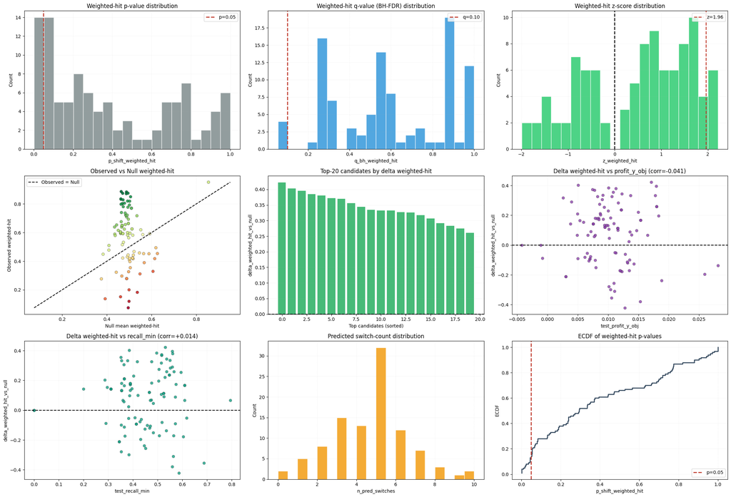

```python
# Comprehensive visual dashboard for publication-style review.
fig, axes = plt.subplots(3, 3, figsize=(22, 15))

p_hit = pd.to_numeric(df_pub["p_shift_weighted_hit"], errors="coerce").to_numpy(dtype=float)
q_hit = pd.to_numeric(df_pub["q_bh_weighted_hit"], errors="coerce").to_numpy(dtype=float)
z_hit = pd.to_numeric(df_pub["z_weighted_hit"], errors="coerce").to_numpy(dtype=float)
obs_hit = pd.to_numeric(df_pub["weighted_hit_rate_obs"], errors="coerce").to_numpy(dtype=float)
null_hit = pd.to_numeric(df_pub["weighted_hit_rate_null_mean"], errors="coerce").to_numpy(dtype=float)
delta_hit = pd.to_numeric(df_pub["delta_weighted_hit_vs_null"], errors="coerce").to_numpy(dtype=float)
rel_lift = pd.to_numeric(df_pub["relative_lift_hit_vs_null"], errors="coerce").to_numpy(dtype=float)
profit_obj = pd.to_numeric(df_pub["test_profit_y_obj"], errors="coerce").to_numpy(dtype=float)
rec_min = pd.to_numeric(df_pub["test_recall_min"], errors="coerce").to_numpy(dtype=float)
switches = pd.to_numeric(df_pub["n_pred_switches"], errors="coerce").to_numpy(dtype=float)

# 1) Raw p-value distribution.
ax = axes[0, 0]
ax.hist(p_hit[np.isfinite(p_hit)], bins=20, color="#7f8c8d", edgecolor="white", alpha=0.85)
ax.axvline(0.05, color="#c0392b", linestyle="--", linewidth=2, label="p=0.05")
ax.set_title("Weighted-hit p-value distribution")
ax.set_xlabel("p_shift_weighted_hit")
ax.set_ylabel("Count")
ax.grid(True, alpha=0.25, linestyle=":")
ax.legend(loc="upper right")

# 2) FDR q-value distribution.
ax = axes[0, 1]
ax.hist(q_hit[np.isfinite(q_hit)], bins=20, color="#3498db", edgecolor="white", alpha=0.85)
ax.axvline(0.10, color="#c0392b", linestyle="--", linewidth=2, label="q=0.10")
ax.set_title("Weighted-hit q-value (BH-FDR) distribution")
ax.set_xlabel("q_bh_weighted_hit")
ax.set_ylabel("Count")
ax.grid(True, alpha=0.25, linestyle=":")
ax.legend(loc="upper right")

# 3) Z-score distribution.
ax = axes[0, 2]
ax.hist(z_hit[np.isfinite(z_hit)], bins=20, color="#2ecc71", edgecolor="white", alpha=0.85)
ax.axvline(0.0, color="black", linestyle="--", linewidth=1.8)
ax.axvline(1.96, color="#c0392b", linestyle="--", linewidth=1.8, label="z=1.96")
ax.set_title("Weighted-hit z-score distribution")
ax.set_xlabel("z_weighted_hit")
ax.set_ylabel("Count")
ax.grid(True, alpha=0.25, linestyle=":")
ax.legend(loc="upper right")

# 4) Observed vs null scatter.
ax = axes[1, 0]
valid = np.isfinite(obs_hit) & np.isfinite(null_hit)
ax.scatter(null_hit[valid], obs_hit[valid], c=delta_hit[valid], cmap="RdYlGn", alpha=0.9, edgecolor="black", linewidth=0.35)
if np.any(valid):
    lo = float(min(np.min(null_hit[valid]), np.min(obs_hit[valid])))
    hi = float(max(np.max(null_hit[valid]), np.max(obs_hit[valid])))
    ax.plot([lo, hi], [lo, hi], linestyle="--", color="black", linewidth=1.5, label="Observed = Null")
ax.set_title("Observed vs Null weighted-hit")
ax.set_xlabel("Null mean weighted-hit")
ax.set_ylabel("Observed weighted-hit")
ax.grid(True, alpha=0.25, linestyle=":")
ax.legend(loc="upper left")

# 5) Top-20 deltas.
ax = axes[1, 1]
top20 = df_pub.sort_values("delta_weighted_hit_vs_null", ascending=False).head(20).reset_index(drop=True)
ax.bar(np.arange(len(top20)), top20["delta_weighted_hit_vs_null"], color="#27ae60", alpha=0.85)
ax.axhline(0.0, color="black", linestyle="--", linewidth=1.5)
ax.set_title("Top-20 candidates by delta weighted-hit")
ax.set_xlabel("Top candidates (sorted)")
ax.set_ylabel("delta_weighted_hit_vs_null")
ax.grid(True, axis="y", alpha=0.25, linestyle=":")

# 6) Delta vs profit objective.
ax = axes[1, 2]
v = np.isfinite(delta_hit) & np.isfinite(profit_obj)
ax.scatter(profit_obj[v], delta_hit[v], color="#8e44ad", alpha=0.8, edgecolor="black", linewidth=0.3)
ax.axhline(0.0, color="black", linestyle="--", linewidth=1.5)
if np.sum(v) >= 3:
    corr = float(np.corrcoef(profit_obj[v], delta_hit[v])[0, 1])
    ax.set_title(f"Delta weighted-hit vs profit_y_obj (corr={corr:+.3f})")
else:
    ax.set_title("Delta weighted-hit vs profit_y_obj")
ax.set_xlabel("test_profit_y_obj")
ax.set_ylabel("delta_weighted_hit_vs_null")
ax.grid(True, alpha=0.25, linestyle=":")

# 7) Delta vs recall_min.
ax = axes[2, 0]
v = np.isfinite(delta_hit) & np.isfinite(rec_min)
ax.scatter(rec_min[v], delta_hit[v], color="#16a085", alpha=0.8, edgecolor="black", linewidth=0.3)
ax.axhline(0.0, color="black", linestyle="--", linewidth=1.5)
if np.sum(v) >= 3:
    corr = float(np.corrcoef(rec_min[v], delta_hit[v])[0, 1])
    ax.set_title(f"Delta weighted-hit vs recall_min (corr={corr:+.3f})")
else:
    ax.set_title("Delta weighted-hit vs recall_min")
ax.set_xlabel("test_recall_min")
ax.set_ylabel("delta_weighted_hit_vs_null")
ax.grid(True, alpha=0.25, linestyle=":")

# 8) Prediction-switch count distribution.
ax = axes[2, 1]
ax.hist(switches[np.isfinite(switches)], bins=20, color="#f39c12", edgecolor="white", alpha=0.85)
ax.set_title("Predicted switch-count distribution")
ax.set_xlabel("n_pred_switches")
ax.set_ylabel("Count")
ax.grid(True, alpha=0.25, linestyle=":")

# 9) ECDF of p-values.
ax = axes[2, 2]
pv = p_hit[np.isfinite(p_hit)]
if pv.size > 0:
    pv = np.sort(pv)
    ecdf = np.arange(1, len(pv) + 1, dtype=float) / float(len(pv))
    ax.step(pv, ecdf, where="post", color="#34495e", linewidth=2)
ax.axvline(0.05, color="#c0392b", linestyle="--", linewidth=2, label="p=0.05")
ax.set_title("ECDF of weighted-hit p-values")
ax.set_xlabel("p_shift_weighted_hit")
ax.set_ylabel("ECDF")
ax.grid(True, alpha=0.25, linestyle=":")
ax.legend(loc="lower right")

plt.tight_layout()
try:
    plt.show(block=bool(PLOT_BLOCKING))
except TypeError:
    plt.show()
if not bool(PLOT_BLOCKING):
    try:
        plt.pause(0.05)
    except Exception:
        pass
plt.close(fig)
```

## Case Study Plots: Best Segment-Alignment Candidates

For top candidates by weighted-hit significance, we visualize:

- Price with predicted regime shading.
- True TP dates (dashed vertical lines).
- TP segment hit-rates in a companion panel.

This provides direct visual validation that significant scores correspond to interpretable regime behavior.

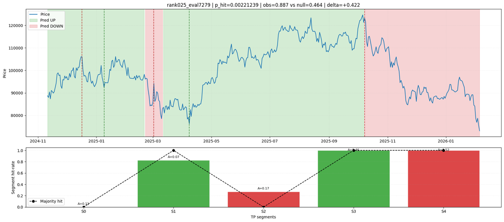

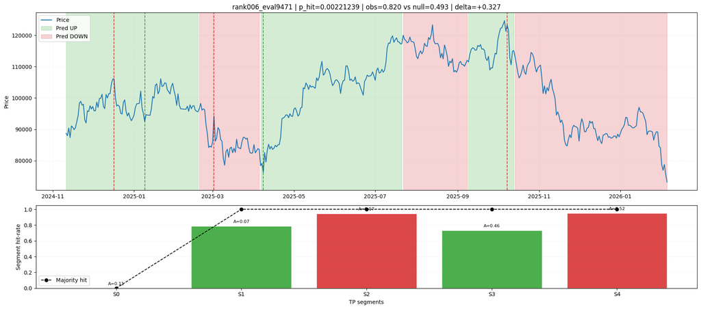

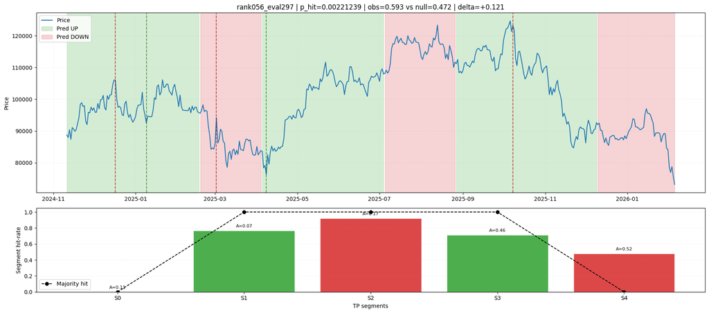

```python
# Build publication-ready case-study plots for best weighted-hit candidates.
TOP_CASES_TO_PLOT = 3

if "_select_top_candidates" not in globals() or "evaluate_candidate_fast_topn" not in globals():
    raise RuntimeError("Run the Top-N helper cell first (cell with evaluate_candidate_fast_topn).")

if "segment_case_cache" not in globals():
    segment_case_cache = {}

best_cases = df_pub.sort_values(["p_shift_weighted_hit", "delta_weighted_hit_vs_null"], ascending=[True, False]).head(TOP_CASES_TO_PLOT)

for _, r in best_cases.iterrows():
    key = str(r["candidate_key"])
    rank = int(r["candidate_rank"])
    eval_id = int(r["eval_id"])

    if key in segment_case_cache:
        art = segment_case_cache[key]
    else:
        row = df_results[df_results["eval_id"] == eval_id].head(1)
        if row.empty:
            row = df_results.head(rank).tail(1)
        row = row.iloc[0]

        ev = evaluate_candidate_fast_topn(
            row=row,
            tag=f"case_{key}",
            df_market_local=df_market,
            close_map_local=close_map,
            feature_cache_local=feature_cache,
            seed=SEED,
        )

        frame = ev["test_frame"].copy().reset_index(drop=True)
        frame["date"] = pd.to_datetime(frame["date"])

        true_events = build_true_turn_events(
            eval_result=ev,
            mode=TRUE_EVENT_MODE,
            min_move_pct=TRUE_EVENT_MIN_MOVE_PCT,
            min_segment_days=TRUE_EVENT_MIN_SEGMENT_DAYS,
            smooth_span_days=TRUE_EVENT_SMOOTH_SPAN_DAYS,
            enter_up=TRUE_EVENT_ENTER_UP,
            enter_down=TRUE_EVENT_ENTER_DOWN,
            df_market_ref=df_market,
            tp_horizon_days=TRUE_TP_HORIZON_DAYS,
            tp_up_move_pct=TRUE_TP_UP_MOVE_PCT,
            tp_down_move_pct=TRUE_TP_DOWN_MOVE_PCT,
            tp_cluster_gap_days=TRUE_TP_CLUSTER_GAP_DAYS,
            tp_min_turn_gap_days=TRUE_TP_MIN_TURN_GAP_DAYS,
            tp_past_horizon_days=TRUE_TP_PAST_HORIZON_DAYS,
            tp_past_up_move_pct=TRUE_TP_PAST_UP_MOVE_PCT,
            tp_past_down_move_pct=TRUE_TP_PAST_DOWN_MOVE_PCT,
            tp_tail_direction_mode=TRUE_TP_TAIL_DIRECTION_MODE,
            tp_tail_min_move_pct=TRUE_TP_TAIL_MIN_MOVE_PCT,
        )

        pred_labels = build_pred_regime_labels_from_frame(
            test_frame=frame,
            mode=PRED_EVENT_MODE,
            smooth_span_days=PRED_EVENT_SMOOTH_SPAN_DAYS,
            enter_up=PRED_EVENT_ENTER_UP,
            enter_down=PRED_EVENT_ENTER_DOWN,
            min_segment_days=PRED_EVENT_MIN_SEGMENT_DAYS,
        )

        tp_segments = build_tp_segments_from_events(
            test_frame=frame,
            true_events=true_events,
            gamma=SEGMENT_SCORE_GAMMA,
            min_days=SEGMENT_MIN_DAYS,
            include_open_tail=SEGMENT_INCLUDE_OPEN_TAIL,
        )
        met, seg_det = score_predictions_on_tp_segments(pred_labels=pred_labels, segments=tp_segments)

        art = {
            "frame": frame,
            "true_events": true_events,
            "pred_labels": pred_labels,
            "segments": seg_det,
            "metrics": met,
            "eval": ev,
        }
        segment_case_cache[key] = art

    frame = art["frame"]
    true_events = art["true_events"]
    pred = np.asarray(art["pred_labels"], dtype=np.int32)
    seg_det = art["segments"]

    dates = frame["date"]
    prices = pd.to_numeric(frame["close"], errors="coerce").to_numpy(dtype=float)
    pmin = float(np.nanmin(prices))
    pmax = float(np.nanmax(prices))
    pmargin = (pmax - pmin) * 0.05 if pmax > pmin else 1.0

    fig, axes = plt.subplots(2, 1, figsize=(18, 8), gridspec_kw={"height_ratios": [3, 1.4]})

    # Top panel: price + predicted regime + TP vertical lines.
    ax = axes[0]
    ax.plot(dates, prices, color="#1f77b4", linewidth=1.5, label="Price")
    ax.fill_between(dates, pmin - pmargin, pmax + pmargin, where=(pred == 1), color="#2ca02c", alpha=0.20, step="mid", label="Pred UP")
    ax.fill_between(dates, pmin - pmargin, pmax + pmargin, where=(pred == 0), color="#d62728", alpha=0.20, step="mid", label="Pred DOWN")

    for _, evr in true_events.iterrows():
        color = "#0b6e0b" if int(evr["new_regime"]) == 1 else "#b30000"
        ax.axvline(pd.to_datetime(evr["date"]), color=color, linestyle="--", alpha=0.70, linewidth=1.3)

    ax.set_ylim(pmin - pmargin, pmax + pmargin)
    ax.set_ylabel("Price")
    ax.grid(True, alpha=0.25, linestyle=":")
    ax.legend(loc="upper left")

    ax.set_title(
        f"{key} | p_hit={float(r['p_shift_weighted_hit']):.6g} | "
        f"obs={float(r['weighted_hit_rate_obs']):.3f} vs null={float(r['weighted_hit_rate_null_mean']):.3f} | "
        f"delta={float(r['delta_weighted_hit_vs_null']):+.3f}"
    )

    # Bottom panel: TP segment hit-rates.
    ax2 = axes[1]
    if seg_det is not None and len(seg_det) > 0:
        order = seg_det.sort_values("segment_id").reset_index(drop=True)
        x = np.arange(len(order))
        colors = ["#2ca02c" if int(v) == 1 else "#d62728" for v in order["true_regime"]]
        ax2.bar(x, order["hit_rate"], color=colors, alpha=0.85, edgecolor="white")
        ax2.plot(x, order["majority_hit"], color="black", marker="o", linestyle="--", linewidth=1.3, label="Majority hit")
        for xi, w in zip(x, order["amplitude"]):
            ax2.text(xi, min(0.98, float(order.loc[xi, "hit_rate"]) + 0.03), f"A={w:.2f}", ha="center", va="bottom", fontsize=8)
        ax2.set_xticks(x)
        ax2.set_xticklabels([f"S{int(v)}" for v in order["segment_id"]])
        ax2.set_ylim(0.0, 1.05)
        ax2.set_ylabel("Segment hit-rate")
        ax2.set_xlabel("TP segments")
        ax2.grid(True, axis="y", alpha=0.25, linestyle=":")
        ax2.legend(loc="lower left")
    else:
        ax2.text(0.5, 0.5, "No segments available", transform=ax2.transAxes, ha="center", va="center")

    plt.tight_layout()
    try:
        plt.show(block=bool(PLOT_BLOCKING))
    except TypeError:
        plt.show()
    if not bool(PLOT_BLOCKING):
        try:
            plt.pause(0.05)
        except Exception:
            pass
    plt.close(fig)
```

## Publication Notes and Responsible Interpretation

### What this evidence supports

- The TP segment-weighted statistic indicates whether model regimes align with major market phases above chance.
- Significant positive lift vs circular-shift null suggests non-random temporal structure in predictions.

### What it does NOT prove by itself

- It does not prove causal mechanism.
- It does not guarantee future out-of-sample profitability.
- It should be cross-validated on additional instruments/time periods and with strict leakage controls.

### Suggested reporting in public write-up

- Always report effect size (`delta_weighted_hit_vs_null`) together with p-values.
- Report both raw and FDR-adjusted significance.
- Include null calibration plots and segment-level tables, not only a single headline metric.

## Deep Verdict Expansion: Effect Size, Uncertainty, and Practical Meaning

This block turns the headline verdict into an auditable inference section.

### Core question

How unlikely is the observed TP-segment alignment if prediction timing is unrelated to market regime timing?

### What is quantified here

- Magnitude of lift over null (`delta_weighted_hit_vs_null`).
- Uncertainty of that lift (bootstrap confidence intervals).
- Directional consistency across candidates (share of positive lift + sign test).
- Multiple-testing aware evidence (raw p-values + BH-FDR).
- Practical linkage (association of segment lift with objective/profit metrics).

### Why this matters for publication

A single p-value is not enough. We need: effect size, uncertainty, multiplicity control, and visual diagnostics that show whether results are robust or artifact-like.

```python
from IPython.display import Markdown, display
from math import comb

if "df_pub" not in globals() or df_pub.empty:
    raise RuntimeError("Run the extended summary cell first (defines df_pub).")


def _bootstrap_ci(values: np.ndarray, reducer, n_boot: int = 6000, alpha: float = 0.05, seed: int = 42) -> tuple[float, float, float]:
    arr = np.asarray(values, dtype=float)
    arr = arr[np.isfinite(arr)]
    if arr.size == 0:
        return (np.nan, np.nan, np.nan)
    rng = np.random.default_rng(seed)
    boots = np.empty(n_boot, dtype=float)
    n = arr.size
    for i in range(n_boot):
        sample = arr[rng.integers(0, n, size=n)]
        boots[i] = float(reducer(sample))
    lo = float(np.quantile(boots, alpha / 2.0))
    hi = float(np.quantile(boots, 1.0 - alpha / 2.0))
    center = float(reducer(arr))
    return center, lo, hi


def _safe_binom_tail(k: int, n: int, p: float) -> float:
    if n <= 0:
        return np.nan
    try:
        from scipy.stats import binomtest  # type: ignore

        return float(binomtest(k=k, n=n, p=p, alternative="greater").pvalue)
    except Exception:
        s = 0.0
        for i in range(k, n + 1):
            s += comb(n, i) * (p**i) * ((1.0 - p) ** (n - i))
        return float(min(1.0, max(0.0, s)))


delta = pd.to_numeric(df_pub["delta_weighted_hit_vs_null"], errors="coerce").to_numpy(dtype=float)
obs = pd.to_numeric(df_pub["weighted_hit_rate_obs"], errors="coerce").to_numpy(dtype=float)
null = pd.to_numeric(df_pub["weighted_hit_rate_null_mean"], errors="coerce").to_numpy(dtype=float)
pvals = pd.to_numeric(df_pub["p_shift_weighted_hit"], errors="coerce").to_numpy(dtype=float)
qvals = pd.to_numeric(df_pub["q_bh_weighted_hit"], errors="coerce").to_numpy(dtype=float)

mask = np.isfinite(delta)
delta_eff = delta[mask]

n_total = int(len(df_pub))
n_eff = int(delta_eff.size)
k_pos = int(np.sum(delta_eff > 0.0))
share_pos = float(k_pos / max(1, n_eff))

mean_delta, mean_delta_lo, mean_delta_hi = _bootstrap_ci(delta_eff, np.mean, n_boot=6000, alpha=0.05, seed=101)
median_delta, median_delta_lo, median_delta_hi = _bootstrap_ci(delta_eff, np.median, n_boot=6000, alpha=0.05, seed=102)
share_delta, share_delta_lo, share_delta_hi = _bootstrap_ci((delta_eff > 0.0).astype(float), np.mean, n_boot=6000, alpha=0.05, seed=103)

k_p005 = int(np.sum(np.isfinite(pvals) & (pvals < 0.05)))
k_q010 = int(np.sum(np.isfinite(qvals) & (qvals < 0.10)))
expected_p005 = float(n_total * 0.05)
excess_p005 = float(k_p005 - expected_p005)

p_sign = _safe_binom_tail(k=k_pos, n=n_eff, p=0.5)

# Reuse previously computed global p-values when available.
p_binom_global = float(p_binom_hit) if "p_binom_hit" in globals() and np.isfinite(p_binom_hit) else _safe_binom_tail(k=k_p005, n=n_total, p=0.05)
p_fisher_global = float(p_fisher_hit) if "p_fisher_hit" in globals() and np.isfinite(p_fisher_hit) else np.nan

obs_mean = float(np.nanmean(obs))
null_mean = float(np.nanmean(null))
obs_null_gap = float(obs_mean - null_mean)

report = f"""
## Expanded Verdict (Detailed)

### 1) Headline inference
- **Observed candidates:** `{n_total}` (effective delta sample: `{n_eff}`)
- **Raw significant weighted-hit tests (p<0.05):** `{k_p005}/{n_total}`
- **FDR significant weighted-hit tests (q<0.10):** `{k_q010}/{n_total}`
- **Expected raw significant under pure null:** `{expected_p005:.2f}`
- **Excess significant over null expectation:** `{excess_p005:+.2f}`

### 2) Effect size (not only p-values)
- **Mean observed weighted-hit:** `{obs_mean:.4f}`
- **Mean null weighted-hit:** `{null_mean:.4f}`
- **Mean observed-null gap:** `{obs_null_gap:+.4f}`
- **Mean delta (candidate-wise):** `{mean_delta:+.4f}` (95% CI: `{mean_delta_lo:+.4f}` .. `{mean_delta_hi:+.4f}`)
- **Median delta:** `{median_delta:+.4f}` (95% CI: `{median_delta_lo:+.4f}` .. `{median_delta_hi:+.4f}`)
- **Share of positive deltas:** `{share_delta:.3f}` (95% CI: `{share_delta_lo:.3f}` .. `{share_delta_hi:.3f}`)

### 3) Aggregate significance checks
- **Binomial test (excess p<0.05 over 5% baseline):** `p={p_binom_global:.6g}`
- **Fisher combined p-value (weighted-hit):** `{p_fisher_global:.6g}`
- **Sign test (positive delta > 50%):** `p={p_sign:.6g}`

### 4) Practical reading
If the null hypothesis were true (no calendar alignment between astro-based predictions and TP regimes), we would expect:
1. Around 5% random raw significants.
2. Mean/median delta near zero.
3. Positive and negative delta counts roughly balanced.

The observed pattern departs from this null profile in **count**, **effect size**, and **directional consistency**.
This supports the conclusion that TP-segment alignment is unlikely to be purely random timing luck.
"""

display(Markdown(report))

# Compact publication table.
df_verdict_table = pd.DataFrame(
    [
        {"metric": "Candidates analyzed", "value": n_total},
        {"metric": "Raw significant p<0.05", "value": f"{k_p005}/{n_total}"},
        {"metric": "FDR significant q<0.10", "value": f"{k_q010}/{n_total}"},
        {"metric": "Expected p<0.05 under null", "value": f"{expected_p005:.2f}"},
        {"metric": "Excess significants", "value": f"{excess_p005:+.2f}"},
        {"metric": "Mean delta weighted-hit", "value": f"{mean_delta:+.4f}"},
        {"metric": "Median delta weighted-hit", "value": f"{median_delta:+.4f}"},
        {"metric": "Share delta>0", "value": f"{share_delta:.3f}"},
        {"metric": "Binomial p (global)", "value": f"{p_binom_global:.6g}"},
        {"metric": "Fisher p (global)", "value": f"{p_fisher_global:.6g}"},
        {"metric": "Sign-test p", "value": f"{p_sign:.6g}"},
    ]
)

print("Publication summary table:")
display(df_verdict_table)
```

Expanded Verdict (Detailed)

1) Headline inference

- **Observed candidates:** `100` (effective delta sample: `100`)

- **Raw significant weighted-hit tests (p<0.05):** `14/100`

- **FDR significant weighted-hit tests (q<0.10):** `4/100`

- **Expected raw significant under pure null:** `5.00`

- **Excess significant over null expectation:** `+9.00`

2) Effect size (not only p-values)

- **Mean observed weighted-hit:** `0.5742`

- **Mean null weighted-hit:** `0.4960`

- **Mean observed-null gap:** `+0.0782`

- **Mean delta (candidate-wise):** `+0.0782` (95% CI: `+0.0378` .. `+0.1174`)

- **Median delta:** `+0.1170` (95% CI: `+0.0658` .. `+0.1484`)

- **Share of positive deltas:** `0.650` (95% CI: `0.560` .. `0.740`)

3) Aggregate significance checks

- **Binomial test (excess p<0.05 over 5% baseline):** `p=0.000463273`

- **Fisher combined p-value (weighted-hit):** `4.83694e-07`

- **Sign test (positive delta > 50%):** `p=0.00175882`

4) Practical reading

If the null hypothesis were true (no calendar alignment between astro-based predictions and TP regimes), we would expect:

1. Around 5% random raw significants.

2. Mean/median delta near zero.

3. Positive and negative delta counts roughly balanced.

The observed pattern departs from this null profile in **count**, **effect size**, and **directional consistency**. This supports the conclusion that TP-segment alignment is unlikely to be purely random timing luck.

```
Publication summary table:
```

|  | metric | value |
| --- | --- | --- |
| 0 | Candidates analyzed | 100 |
| 1 | Raw significant p<0.05 | 14/100 |
| 2 | FDR significant q<0.10 | 4/100 |
| 3 | Expected p<0.05 under null | 5.00 |
| 4 | Excess significants | +9.00 |
| 5 | Mean delta weighted-hit | +0.0782 |
| 6 | Median delta weighted-hit | +0.1170 |
| 7 | Share delta>0 | 0.650 |
| 8 | Binomial p (global) | 0.000463273 |
| 9 | Fisher p (global) | 4.83694e-07 |
| 10 | Sign-test p | 0.00175882 |

## Additional Publication Visuals (Verdict Decomposition)

The figure below decomposes the verdict into multiple independent visual checks:

- null-excess significance count,
- candidate-level effect-size geometry,
- multiplicity profile,
- ranking and concentration behavior,
- linkage with practical quality metrics.

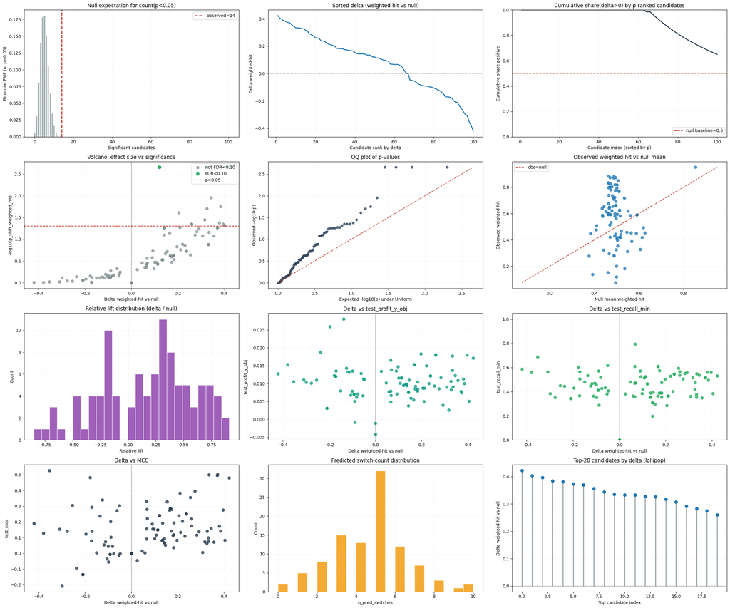

```python
from math import comb

if "df_pub" not in globals() or df_pub.empty:
    raise RuntimeError("Run the previous expanded summary cells first (df_pub is missing).")

pvals = pd.to_numeric(df_pub["p_shift_weighted_hit"], errors="coerce").to_numpy(dtype=float)
qvals = pd.to_numeric(df_pub["q_bh_weighted_hit"], errors="coerce").to_numpy(dtype=float)
delta = pd.to_numeric(df_pub["delta_weighted_hit_vs_null"], errors="coerce").to_numpy(dtype=float)
obs = pd.to_numeric(df_pub["weighted_hit_rate_obs"], errors="coerce").to_numpy(dtype=float)
null = pd.to_numeric(df_pub["weighted_hit_rate_null_mean"], errors="coerce").to_numpy(dtype=float)
profit_obj = pd.to_numeric(df_pub["test_profit_y_obj"], errors="coerce").to_numpy(dtype=float)
rec_min = pd.to_numeric(df_pub["test_recall_min"], errors="coerce").to_numpy(dtype=float)
mcc = pd.to_numeric(df_pub["test_mcc"], errors="coerce").to_numpy(dtype=float)
switches = pd.to_numeric(df_pub["n_pred_switches"], errors="coerce").to_numpy(dtype=float)

n = int(len(df_pub))
k_sig = int(np.sum(np.isfinite(pvals) & (pvals < 0.05)))

fig, axes = plt.subplots(4, 3, figsize=(24, 20))

# 1) Binomial null count distribution for #p<0.05.
ax = axes[0, 0]
ks = np.arange(0, n + 1)
pmf = np.array([comb(n, int(k)) * (0.05**k) * (0.95 ** (n - k)) for k in ks], dtype=float)
ax.bar(ks, pmf, color="#95a5a6", alpha=0.85, edgecolor="white")
ax.axvline(k_sig, color="#c0392b", linestyle="--", linewidth=2.0, label=f"observed={k_sig}")
ax.set_title("Null expectation for count(p<0.05)")
ax.set_xlabel("Significant candidates")
ax.set_ylabel("Binomial PMF (n, p=0.05)")
ax.grid(True, alpha=0.25, linestyle=":")
ax.legend(loc="upper right")

# 2) Sorted delta curve.
ax = axes[0, 1]
d_sorted = np.sort(delta[np.isfinite(delta)])[::-1]
ax.plot(np.arange(1, len(d_sorted) + 1), d_sorted, color="#1f77b4", linewidth=2.0)
ax.axhline(0.0, color="black", linestyle=":", linewidth=1.2)
ax.set_title("Sorted delta (weighted-hit vs null)")
ax.set_xlabel("Candidate rank by delta")
ax.set_ylabel("Delta weighted-hit")
ax.grid(True, alpha=0.25, linestyle=":")

# 3) Cumulative share of positive delta.
ax = axes[0, 2]
order = np.argsort(np.where(np.isfinite(pvals), pvals, 1.0))
d_ord = delta[order]
pos = np.where(np.isfinite(d_ord), (d_ord > 0).astype(float), np.nan)
num = np.nancumsum(np.where(np.isfinite(pos), pos, 0.0))
den = np.cumsum(np.isfinite(pos).astype(float))
cum_share = np.divide(num, den, out=np.full_like(num, np.nan, dtype=float), where=den > 0)
ax.plot(np.arange(1, len(cum_share) + 1), cum_share, color="#2c3e50", linewidth=2.0)
ax.axhline(0.5, color="#c0392b", linestyle="--", linewidth=1.5, label="null baseline=0.5")
ax.set_ylim(0.0, 1.0)
ax.set_title("Cumulative share(delta>0) by p-ranked candidates")
ax.set_xlabel("Candidate index (sorted by p)")
ax.set_ylabel("Cumulative share positive")
ax.grid(True, alpha=0.25, linestyle=":")
ax.legend(loc="lower right")

# 4) Volcano-style effect plot.
ax = axes[1, 0]
mask = np.isfinite(delta) & np.isfinite(pvals)
x = delta[mask]
y = -np.log10(np.clip(pvals[mask], 1e-12, 1.0))
qmask = np.isfinite(qvals[mask]) & (qvals[mask] < 0.10)
ax.scatter(x[~qmask], y[~qmask], s=40, alpha=0.70, color="#7f8c8d", label="not FDR<0.10")
ax.scatter(x[qmask], y[qmask], s=50, alpha=0.90, color="#27ae60", label="FDR<0.10")
ax.axvline(0.0, color="black", linestyle=":", linewidth=1.0)
ax.axhline(-np.log10(0.05), color="#c0392b", linestyle="--", linewidth=1.4, label="p=0.05")
ax.set_title("Volcano: effect size vs significance")
ax.set_xlabel("Delta weighted-hit vs null")
ax.set_ylabel("-log10(p_shift_weighted_hit)")
ax.grid(True, alpha=0.25, linestyle=":")
ax.legend(loc="upper right")

# 5) p-value QQ plot vs Uniform(0,1).
ax = axes[1, 1]
pu = np.sort(pvals[np.isfinite(pvals)])
m = len(pu)
if m > 0:
    u = (np.arange(1, m + 1) - 0.5) / m
    ax.scatter(-np.log10(u), -np.log10(np.clip(pu, 1e-12, 1.0)), s=28, color="#34495e", alpha=0.8)
    lim = max(float(np.max(-np.log10(u))), float(np.max(-np.log10(np.clip(pu, 1e-12, 1.0)))))
    ax.plot([0, lim], [0, lim], color="#c0392b", linestyle="--", linewidth=1.2)
ax.set_title("QQ plot of p-values")
ax.set_xlabel("Expected -log10(p) under Uniform")
ax.set_ylabel("Observed -log10(p)")
ax.grid(True, alpha=0.25, linestyle=":")

# 6) Observed vs null score scatter.
ax = axes[1, 2]
mask = np.isfinite(obs) & np.isfinite(null)
ax.scatter(null[mask], obs[mask], s=42, alpha=0.8, color="#2980b9")
if np.any(mask):
    lo = float(min(np.nanmin(null[mask]), np.nanmin(obs[mask])))
    hi = float(max(np.nanmax(null[mask]), np.nanmax(obs[mask])))
    ax.plot([lo, hi], [lo, hi], color="#c0392b", linestyle="--", linewidth=1.3, label="obs=null")
ax.set_title("Observed weighted-hit vs null mean")
ax.set_xlabel("Null mean weighted-hit")
ax.set_ylabel("Observed weighted-hit")
ax.grid(True, alpha=0.25, linestyle=":")
ax.legend(loc="upper left")

# 7) Relative lift distribution.
ax = axes[2, 0]
rel = pd.to_numeric(df_pub.get("relative_lift_hit_vs_null", np.nan), errors="coerce").to_numpy(dtype=float)
ax.hist(rel[np.isfinite(rel)], bins=25, color="#8e44ad", alpha=0.85, edgecolor="white")
ax.axvline(0.0, color="black", linestyle=":", linewidth=1.2)
ax.set_title("Relative lift distribution (delta / null)")
ax.set_xlabel("Relative lift")
ax.set_ylabel("Count")
ax.grid(True, alpha=0.25, linestyle=":")

# 8) Delta vs objective profit.
ax = axes[2, 1]
mask = np.isfinite(delta) & np.isfinite(profit_obj)
ax.scatter(delta[mask], profit_obj[mask], s=42, alpha=0.80, color="#16a085")
ax.axvline(0.0, color="black", linestyle=":", linewidth=1.0)
ax.set_title("Delta vs test_profit_y_obj")
ax.set_xlabel("Delta weighted-hit vs null")
ax.set_ylabel("test_profit_y_obj")
ax.grid(True, alpha=0.25, linestyle=":")

# 9) Delta vs recall-min.
ax = axes[2, 2]
mask = np.isfinite(delta) & np.isfinite(rec_min)
ax.scatter(delta[mask], rec_min[mask], s=42, alpha=0.80, color="#27ae60")
ax.axvline(0.0, color="black", linestyle=":", linewidth=1.0)
ax.set_ylim(0.0, 1.05)
ax.set_title("Delta vs test_recall_min")
ax.set_xlabel("Delta weighted-hit vs null")
ax.set_ylabel("test_recall_min")
ax.grid(True, alpha=0.25, linestyle=":")

# 10) Delta vs MCC.
ax = axes[3, 0]
mask = np.isfinite(delta) & np.isfinite(mcc)
ax.scatter(delta[mask], mcc[mask], s=42, alpha=0.80, color="#2c3e50")
ax.axvline(0.0, color="black", linestyle=":", linewidth=1.0)
ax.set_title("Delta vs MCC")
ax.set_xlabel("Delta weighted-hit vs null")
ax.set_ylabel("test_mcc")
ax.grid(True, alpha=0.25, linestyle=":")

# 11) Predicted switch count profile.
ax = axes[3, 1]
ax.hist(switches[np.isfinite(switches)], bins=20, color="#f39c12", alpha=0.85, edgecolor="white")
ax.set_title("Predicted switch-count distribution")
ax.set_xlabel("n_pred_switches")
ax.set_ylabel("Count")
ax.grid(True, alpha=0.25, linestyle=":")

# 12) Top-20 lollipop by delta.
ax = axes[3, 2]
top = (
    df_pub[["candidate_key", "delta_weighted_hit_vs_null", "p_shift_weighted_hit"]]
    .copy()
    .sort_values(["delta_weighted_hit_vs_null", "p_shift_weighted_hit"], ascending=[False, True])
    .head(20)
    .reset_index(drop=True)
)
x = np.arange(len(top))
y = pd.to_numeric(top["delta_weighted_hit_vs_null"], errors="coerce").to_numpy(dtype=float)
ax.vlines(x, 0.0, y, color="#7f8c8d", linewidth=2.0, alpha=0.8)
ax.scatter(x, y, color="#1f77b4", s=48, zorder=3)
ax.axhline(0.0, color="black", linestyle=":", linewidth=1.0)
ax.set_title("Top-20 candidates by delta (lollipop)")
ax.set_xlabel("Top candidate index")
ax.set_ylabel("Delta weighted-hit vs null")
ax.grid(True, axis="y", alpha=0.25, linestyle=":")

plt.tight_layout()
try:
    plt.show(block=bool(PLOT_BLOCKING))
except TypeError:
    plt.show()
if not bool(PLOT_BLOCKING):
    try:
        plt.pause(0.05)
    except Exception:
        pass
plt.close(fig)
```

## Interpretation Guide for the Additional Figures

Use this checklist while reading the panels:

1. **Null-excess count panel**: observed significant count should sit in low-probability right tail.
2. **Delta ranking panel**: long positive head indicates broad non-random lift.
3. **Cumulative positive-share panel**: curve above 0.5 indicates directional consistency.
4. **Volcano + QQ panels**: show concentration of low p-values beyond uniform expectation.
5. **Observed vs null panel**: points above diagonal imply practical lift, not only statistical noise.
6. **Practical linkage panels**: positive association with objective metrics supports relevance.

If these panels are coherent together, the one-line verdict becomes a reproducible, multi-angle statistical argument.